# CCS 消融实验：gene signature 评估

Bensz Conan

2026-10-08

本报告是 ablation-03 实验的 gene signature 评估模块，只读取已经完成的邻居检索与评分结果。前一份表示报告问“邻居的癌种或技术标签是否相同”；这里问的是：**在当前表达数据和固定 reference 标尺下，两臂找到的邻居，其 gene signature 分数与 query 有多接近？** 同属一个癌种的患者仍可能有不同的免疫相关表达水平，癌种标签不能描述这些连续差异；但表达分数也可能包含技术差异，不能直接视为纯生物状态。

本次使用五个 gene signature，分别对应增殖、免疫微环境、基质微环境、IFNγ 和 IL6-JAK-STAT3。Direct 更贴近原始表达排序，d1 则经过多个队列模型重编码；两者的邻居接近度可能不同，本报告量化差异及其跨队列一致性。结构报告另检查这些分数定义的高低状态之间，较大尺度的距离排序能否在另一组患者中复现。两份报告的目标都来自表达数据，不构成独立临床结局验证。

**核心结论是：d1 确实改变了邻居的生物表达关系，但平均匹配代价较小。** 广队列基线的五项 gene signature 接近度差（d1−Direct）为 -0.0589 至 -0.0439；高覆盖、共同秩评分与同癌种检索下，五项平均差为 -0.0163 至 0.0085，更接近零。对于以跨队列表征为目标的 CCS，接受少量局部表达匹配精度的损失，换取共同表示空间，是可以接受的方法取舍。这里的“较小”指接近度指标上的平均绝对变化，队列之间仍存在明显差异。

## 1 数据概览

### 1.1 Reference 与 query 各自用于什么

**本报告的 gene signature 主效应评估外部 query 患者；reference 同时提供表达评分标尺和检索邻居。两边都需要表达数据。** 本次冻结样本契约包含 147 个 reference 队列、24,487 个样本，以及 43 个 query 队列、14,060 个样本。两组样本 ID 和 cohort key 均不重叠。

| 阶段 | Reference 的用途 | Query 的用途 |
| --- | --- | --- |
| 表达输入准备 | 按冻结样本契约提取 gene signature 基因表达 | 按同一契约提取 gene signature 基因表达；不另招募患者 |
| 基因标尺与 gene signature 评分 | 合并 reference 中每个基因的有限表达观测，估计均值与标准差；也计算自身 gene signature 分数 | 仅应用固定 reference 标尺计算 gene signature 分数，不参与标尺拟合 |
| 两臂 top-15 检索 | 作为共同候选库；实际选中哪些样本取决于 Direct 或 d1 的距离 | 每位 query 分别在两臂检索，排除同 cohort 样本；广队列主效应候选池包含所有癌种 |
| 接近度与主效应推断 | 用被选中邻居的 gene signature 分数与 query 比较；不是主效应的重采样单位 | 要求两臂 top-15 分数完整，先做患者内配对，再在 query cohort 内平均，最后对 query cohort 等权 |
| 高覆盖连续读取器验证 | 仅在 reference 训练和按 cohort 五折调参；训练折内重新拟合所需标尺 | 固定模型后外部评估，不参与调参；目标支持不足时不拟合、不发布效应 |

广队列主效应的表达来自本地泛癌表达 atlas（GEO、cBioPortal 与 UCSC Xena 汇编），由 01.03.00. 生物输入准备.R 按契约提取到 `01-biology/expression-anchor-cache.rds`；gene signature 来自 GeneSignature-HWB.rds，选择规则冻结于 `config/biological-anchors.yml`。两臂邻居来自正式表示分析产物 `ablation-experiment/anchor_retrieval.rds`。报告只读取这些正式产物，不重新训练 bank 或按 gene signature 结果调整患者集合。reference 的 d1 来自冻结 bank 内表示，query 的 d1 为外部冻结变换；这里的“外部”描述样本与 bank 的使用关系，不代表 gene signature 是独立临床结局。

### 1.2 队列来源、检测类型与完整清单

下表按样本契约中的来源系统和检测类型汇总。`contract_samples` 是进入本次契约的样本数，`expression_samples` 是表达缓存中实际找到的样本数，均不代表原研究的全部入组人数。来源系统是数据获取渠道，同一来源下可有多个研究队列，不能把来源数当作独立队列数。

```r
render_dt_output(cohort_sources, n = nrow(cohort_sources), pageLength = 10)
```

|  | role | source_system | assay_type | cohort_count | contract_samples | expression_samples |
| --- | --- | --- | --- | --- | --- | --- |
| 1 | query | cBioPortal | RNA-seq | 10 | 2538 | 2538 |
| 2 | query | GEO | microarray | 1 | 72 | 72 |
| 3 | query | UCSC Xena | microarray | 1 | 285 | 285 |
| 4 | query | UCSC Xena | RNA-seq | 31 | 11165 | 11165 |
| 5 | reference | cBioPortal | microarray | 5 | 2514 | 2514 |
| 6 | reference | cBioPortal | RNA-seq | 11 | 1913 | 1913 |
| 7 | reference | GEO | microarray | 97 | 16454 | 16454 |
| 8 | reference | GEO | RNA-seq | 5 | 773 | 773 |
| 9 | reference | UCSC Xena | microarray | 10 | 1678 | 1678 |
| 10 | reference | UCSC Xena | RNA-seq | 19 | 1155 | 1155 |

完整清单包含全部 190 个队列，可用表格搜索框筛选 `reference`、`query`、组织、研究名称或来源。`reference_scale` 标记是否属于广队列主效应的标尺来源；各基因仍只使用该队列中实际存在的有限表达观测。`selected_reference_direct` 与 `selected_reference_d1` 是各臂在全部 query 的 top-15 名单中选中的该队列**不同 reference 样本数**，不是邻居对次数；query 行为 0，因为 query 不进入 reference 候选库。零次被选中不会取消某个 reference 队列的候选资格或标尺贡献。`platform_id=unknow` 表示平台资料未知，不是一个真实平台。

```r
render_dt_output(cohort_usage, n = nrow(cohort_usage), pageLength = 15)
```

|  | role | cohort_key | cohort | tissue | cancer_type | source_system | assay_type | platform_id | contract_samples | expression_samples | reference_scale | selected_reference_direct | selected_reference_d1 |
| --- | --- | --- | --- | --- | --- | --- | --- | --- | --- | --- | --- | --- | --- |
| 148 | query | ACC/TCGATARGET-ACC | TCGATARGET-ACC | ACC | ACC | UCSC Xena | RNA-seq | unknow | 77 | 77 | False | 0 | 0 |
| 149 | query | BLCA/TCGATARGET-BLCA | TCGATARGET-BLCA | BLCA | BLCA | UCSC Xena | RNA-seq | unknow | 407 | 407 | False | 0 | 0 |
| 150 | query | Blood/Broad-Blood-2022 | Broad-Blood-2022 | Blood | Blood | cBioPortal | RNA-seq | unknow | 715 | 715 | False | 0 | 0 |
| 151 | query | Blood/OHSU-Blood-2018 | OHSU-Blood-2018 | Blood | Blood | cBioPortal | RNA-seq | unknow | 451 | 451 | False | 0 | 0 |
| 152 | query | Blood/OHSU-Blood-2022 | OHSU-Blood-2022 | Blood | Blood | cBioPortal | RNA-seq | unknow | 671 | 671 | False | 0 | 0 |
| 153 | query | Blood/PCAWG-PanCan-2017_Blood | PCAWG-PanCan-2017_Blood | Blood | Blood | UCSC Xena | RNA-seq | unknow | 101 | 101 | False | 0 | 0 |
| 154 | query | Blood/TCGATARGET-Blood | TCGATARGET-Blood | Blood | Blood | UCSC Xena | RNA-seq | unknow | 761 | 761 | False | 0 | 0 |
| 155 | query | BRCA/CPTAC-BRCA-2020 | CPTAC-BRCA-2020 | BRCA | BRCA | cBioPortal | RNA-seq | unknow | 122 | 122 | False | 0 | 0 |
| 156 | query | BRCA/TCGATARGET-BRCA | TCGATARGET-BRCA | BRCA | BRCA | UCSC Xena | RNA-seq | unknow | 1094 | 1094 | False | 0 | 0 |
| 157 | query | CESC/TCGATARGET-CESC | TCGATARGET-CESC | CESC | CESC | UCSC Xena | RNA-seq | unknow | 306 | 306 | False | 0 | 0 |

[output cut: 180 more lines]

### 1.3 从候选 query 到各 gene signature 的有效配对

共享候选 query 为 43 个队列、14,060 个样本。**表示报告中的癌种 readout 合格子集为 17 个队列、5,705 个样本，不能把这个子集当作 gene signature 的样本来源。** 癌种 readout 要求相应癌种在 reference 中有足够的跨队列支持；广队列 gene signature 分数主效应按自身表达与两臂完整配对条件使用候选 query，不继承该癌种支持筛选。

下面逐 gene signature 列出实际参与主效应的队列和患者数，直接读取正式推断表；邻居对重复出现不会增加患者数或独立队列数。

```r
render_dt_output(biology_inference[, c("anchor", "cohort_count", "query_count",
  "inference_status")], n = nrow(biology_inference))
```

|  | anchor | cohort_count | query_count | inference_status |
| --- | --- | --- | --- | --- |
| 1 | ifn | 43 | 14060 | estimable |
| 2 | il6 | 43 | 14060 | estimable |
| 3 | immune_tme | 43 | 14060 | estimable |
| 4 | proliferation | 43 | 14060 | estimable |
| 5 | stromal_tme | 43 | 14060 | estimable |

逐队列、逐 gene signature 表中，`sample_count` 为缓存中的候选 query 数，`query_count` 为两臂都有完整 top-15 gene signature 分数的配对 query 数，`excluded_queries` 是二者差值。`genes_found / genes_required` 描述该队列的输入基因覆盖；基因覆盖不足 100% 与 query 被排除是两种不同情况，不能互相替代。广队列主效应至少需要两个有效 reference 标尺基因，样本分数须有限；它未要求所有队列使用完全相同的 gene signature 基因。

```r
render_dt_output(query_usage, n = nrow(query_usage), pageLength = 15)
```

|  | cohort | anchor | cohort_key | sample_count | genes_required | genes_found | coverage | query_count | excluded_queries |
| --- | --- | --- | --- | --- | --- | --- | --- | --- | --- |
| 66 | TCGATARGET-ACC | ifn | ACC/TCGATARGET-ACC | 77 | 200 | 200 | 1 | 77 | 0 |
| 67 | TCGATARGET-ACC | il6 | ACC/TCGATARGET-ACC | 77 | 87 | 87 | 1 | 77 | 0 |
| 68 | TCGATARGET-ACC | immune_tme | ACC/TCGATARGET-ACC | 77 | 26 | 26 | 1 | 77 | 0 |
| 69 | TCGATARGET-ACC | proliferation | ACC/TCGATARGET-ACC | 77 | 15 | 15 | 1 | 77 | 0 |
| 70 | TCGATARGET-ACC | stromal_tme | ACC/TCGATARGET-ACC | 77 | 18 | 18 | 1 | 77 | 0 |
| 71 | TCGATARGET-BLCA | ifn | BLCA/TCGATARGET-BLCA | 407 | 200 | 200 | 1 | 407 | 0 |
| 72 | TCGATARGET-BLCA | il6 | BLCA/TCGATARGET-BLCA | 407 | 87 | 87 | 1 | 407 | 0 |
| 73 | TCGATARGET-BLCA | immune_tme | BLCA/TCGATARGET-BLCA | 407 | 26 | 26 | 1 | 407 | 0 |
| 74 | TCGATARGET-BLCA | proliferation | BLCA/TCGATARGET-BLCA | 407 | 15 | 15 | 1 | 407 | 0 |
| 75 | TCGATARGET-BLCA | stromal_tme | BLCA/TCGATARGET-BLCA | 407 | 18 | 18 | 1 | 407 | 0 |

[output cut: 205 more lines]

三份队列级 CSV 与表格同源：来源汇总、完整队列清单、gene signature 有效配对清单。这些导出仅含队列级元数据与计数，不含患者 ID 或表达原值。表达覆盖审计共 950 行，分别对应 cohort–gene signature 组合。

正文高覆盖验证从同一冻结契约中，按各 signature 的基因可测性筛选兼容队列，再检查共同秩背景、同癌种 reference 支持、每 cohort 有效 query 数与两臂完整配对。其有效人数见高覆盖主比较和资格表，不能沿用广队列基线分母。全队列共同交集审计及残余代理探索另存附录，用于说明测量边界和提供探索线索。

## 2 关键函数、参数与源代码位置

| 过程 | 函数与参数 | 约定 | 源代码 |
| --- | --- | --- | --- |
| 表达输入准备 | signature 名称与完整样本契约 | 在分析前提取表达子集 | 01.03.00. 生物输入准备.R |
| 连续评分 | reference gene-wise z-score | 对两臂应用同一 reference 尺度 | 02.02.00. 生物锚点分析.R |
| 配对推断 | `.biology_paired_contrast()`；2000 次 bootstrap；至少 3 个 cohort | 先按 query 配对，再以 cohort 为独立单位；仅对达到门槛的 gene signature 计算区间、P 值与 BH 校正 | 02.02.00. 生物锚点分析_functions.R |

## 3 指标导读

| 指标 | 怎样从数据得到 | 尺度、方向与边界 |
| --- | --- | --- |
| 基因覆盖率 | 当前 cohort 输入中存在的 gene signature 基因数／预设 gene signature 基因数 | 0–1；1 表示输入基因齐全，不保证全部基因具备有效 reference 标尺或实际进入评分，也不衡量邻居质量 |
| Gene signature utility | 先对每个 query–邻居对计算 $\exp(-\|s_q-s_j\|)$，再平均前 15 个邻居 | 0–1；同分数为 1，差得越远越接近 0；是表达状态接近度，不是临床效用 |
| d1−Direct | 同一 query 的两臂 utility 先相减，再在 cohort 内和 cohort 间依次平均 | 零表示当前 gene signature 的平均接近度相同；正值是 d1 更高，负值是 Direct 更高 |
| 95% CI 与 BH 校正 P 值 | 对完整 cohort 重采样得到区间，gene signature 组内校正检验 | 区间反映队列间波动；跨零不证明等价，样本级区间不能替代队列级区间 |

双侧 sign-flip 检验在 cohort 数不超过 18 时枚举符号组合，否则采用 Monte Carlo 加一校正；随机种子由分析配置固定。

## 4 gene signature 分数的邻居接近度

### 4.1 为什么癌种相同，还要看连续表达状态

**本节问的是：同一个患者换用 d1 找邻居后，邻居的增殖、免疫和基质等表达状态是否仍与自己接近？** 癌种标签只告诉我们患者属于哪一类，不能说明这一类内部的状态。例如，两名乳腺癌患者可以拥有相同的癌种标签，却分别处于免疫相关表达较高和较低的状态；同癌种检索把两人都算作命中，连续 gene signature 分数则能辨认这种差别。

可以把癌种看成学生所在的年级，连续表达状态看成具体科目的成绩：找到同年级的学生，并不保证数学成绩接近。本节用几组预先指定的基因作为“科目”，把每位患者的表达汇总成连续分数，再检查两种表示各自找到的同伴。这里的 readout 是**在已有邻居名单上读出表达接近度**，没有另训练一个 gene signature 预测器；它与前一报告的癌种线性 readout 是不同的任务。

五个 gene signature 按 `config/biological-anchors.yml` 中的名称分别选取、去重并评分。IFNγ 与 IL6-JAK-STAT3 各自使用对应通路的基因集，天然共享基因在两个 gene signature 中分别保留。五项 gene signature 构成固定的多重检验校正族。

| gene signature | 配置指定的 gene signature | 连续分数提供什么参照 |
| --- | --- | --- |
| `proliferation` | `Tumor proliferation rate` | 增殖相关基因的相对表达水平 |
| `immune_tme` | `TME_A_Immune2` | 免疫微环境相关基因的相对表达水平 |
| `stromal_tme` | `TME_B_Stromal2` | 基质微环境相关基因的相对表达水平 |
| `ifn` | `IFNγ signaling` | IFNγ 相关基因的相对表达水平 |
| `il6` | `IL6-JAK-STAT3 signaling` | IL6-JAK-STAT3 相关基因的相对表达水平 |

这些分数是 gene signature 的代理指标，不能直接读成细胞比例、实际增殖速度或通路因果活性。广队列基线包含与 CCS 输入重叠的基因，直接输入不重叠敏感性分析单独报告。两者的目标均来自表达数据，测量独立性仍需外部证据。因此，这是表达信息保留的诊断，不能当成独立临床结局验证。

### 4.2 实验固定什么，只改变什么

两臂消费已经冻结的 Direct-GSClassifier 和 Cohort-d1 表示，以及表示分析产出的跨队列邻居名单。reference 是已有样本库，query 是本次样本契约中的外部患者；两臂使用同一批外部患者和冻结 cohort 模型。

| 实验要素 | 本节怎样控制 | 为什么这样做 |
| --- | --- | --- |
| 患者与候选池 | 同一个 query，在同一 reference 库中检索；排除同 cohort 样本，候选包含其它 cohort 的所有癌种 | 避免把不同患者或不同候选池的差异混入两臂比较；仍需检查跨队列的平台与癌种组成 |
| 邻居名单 | 沿用各臂既定定标、距离和排序，只取前 15 位 | 改变的是表示所定义的邻居关系；此处的邻居数与技术联合评估使用的 Top-k 口径应分别阅读 |
| 表达标尺 | 跨 reference cohort 合并每个基因的有限表达观测，计算均值与标准差，对 query 和两臂邻居应用同一变换 | 固定两臂评分规则，query 不参与拟合；这一步不校正 batch effect，也不证明跨平台表达可比 |
| 有效配对 | 对每个 gene signature，只保留两臂均有完整 top-15 gene signature 分数的 query | 两臂均值基于同一批患者；不同 gene signature 的有效患者集合仍须分别核对 |
| 主要汇总 | 患者内相减，cohort 内平均，再对 cohort 等权 | 不让大队列仅凭人数主导跨队列结论 |

**表达分数固定，邻居名单可以改变。** 如果某位患者的免疫分数是 0.8，这个 0.8 在两臂中相同；Direct 和 d1 可能为他找到不同的邻居，差异由这些邻居与 0.8 的距离产生。完整 top-15 指的是分数齐全，不要求两臂选中同一批邻居，也不等于所有 gene signature 基因齐全。

### 4.3 从多个基因得到一个连续分数

令 $x_{gi}$ 表示样本 $i$ 中基因 $g$ 的表达值。先合并所有 reference cohort 中该基因的有限表达观测，计算一套全局均值 $\mu_g^{\mathrm{ref}}$ 与标准差 $\sigma_g^{\mathrm{ref}}$，再计算

$$z_{gi}=\frac{x_{gi}-\mu_g^{\mathrm{ref}}}{\sigma_g^{\mathrm{ref}}}.$$

减去均值是在问“比 reference 的通常水平高多少”，除以标准差则把不同基因换到可比较的尺度。$z=0$ 表示位于该基因的 reference 均值，$z=1$ 表示高一个 reference 标准差，负值表示低于均值。reference 中不足两个有限观测、或标准差为零的基因不参与评分；这里的 reference 均值按可用样本合并计算，**不是先求各 cohort 均值再等权**。后面的 cohort 等权用于效应汇总，不能倒推评分尺子也采用了相同权重。

对 gene signature $a$，令 $G_{a,i}^{\mathrm{use}}$ 为样本所在 cohort 实际具备、reference 标尺有效且该样本标准化值非缺失的 gene signature 基因集合。实现先要求该 cohort 至少有两个可定标基因，再按样本对非缺失的 $z$ 值取均值：

$$s_{a,i}=\frac{1}{|G_{a,i}^{\mathrm{use}}|}
\sum_{g\in G_{a,i}^{\mathrm{use}}}z_{gi}.$$

以下手算均为**教学示例，不是本次数据结果**。某基因的 reference 均值为 10、标准差为 2，患者表达为 12，则 $z=(12-10)/2=1$。若一组 gene signature 的三个可用基因分别为 $1$、$0$、$-0.5$，分数就是 $(1+0-0.5)/3\approx0.167$。平均能减轻单个基因偶然波动的影响，但也会丢掉基因间的细节：两个患者都得 0.167，不代表逐基因表达相同。

**这套变换可以作为本次分析固定的评分规则，但它不是 batch correction。** 对同一个基因，query 与邻居的标准化差值为

$$z_{gq}-z_{gj}=\frac{x_{gq}-x_{gj}}{\sigma_g^{\mathrm{ref}}}.$$

全局均值在差值中抵消，原始表达差里的平台或 cohort 偏移仍然保留；reference 标准差也可能同时包含生物变异和技术变异。因此，共享标尺只统一计算规则，不建立跨平台的生物学可比性。它衡量的是当前输入条件下的 gene signature 分数接近度。解释残余 batch effect 的前提是基本表达单位和变换已有可比性；若输入混合了不兼容的表达尺度，仍需先核实上游处理，不能仅靠 z-score 或谨慎措辞解决。

两臂使用同一个 query 和同一套评分规则，也不保证技术偏差抵消，因为它们选中的邻居及其技术背景可能不同。Direct 若倾向选中技术背景相近的邻居，可能在这套评分中更占优势；d1 若减弱技术聚集，也可能因此得到较低接近度。这是待核验的解释，当前差值不能单独证明生物信息损失，也不能反过来证明 batch effect 已消除。按 cohort 单独做 z-score 同样会改变目标：它衡量队列内相对位置，并可能一并去掉真实的队列均值差。

此外，$s$ 是多个基因 z-score 的平均，**它本身没有再标准化到方差为 1**；分数相差 1 个单位不能称为“整个 gene signature 相差一个标准差”。不同 gene signature 的基因数和相关结构不同，utility 的量级也不能直接当作各生物过程重要性的排名。

### 4.4 从分数距离到邻居接近度

令 $q$ 是 query，$j$ 是其邻居。先计算两人的 gene signature 分数距离，再用指数函数转换为接近度：

$$d_{a,qj}=|s_{a,q}-s_{a,j}|,
\qquad
u_{a,qj}=\exp(-d_{a,qj}).$$

绝对值表示只关心距离，不关心邻居的分数偏高还是偏低。距离为零时 $u=1$；距离增大时 $u$ 向零靠近。选择这种转换，是为了让每个邻居的贡献落在同一有界接近度尺度，避免一个很远的邻居用无限大的距离主导平均；它也规定了对远近的惩罚方式，因而是本实验的度量选择，并非天然的临床效用函数。

| 教学示例：分数距离 $d$ | 接近度 $e^{-d}$ | 怎样读 |
| --- | --- | --- |
| 0 | 1.000 | 两人的 gene signature 均分相同 |
| 0.5 | 0.607 | 相差半个 gene signature 分数单位 |
| 1 | 0.368 | 相差一个 gene signature 分数单位 |
| 2 | 0.135 | 相差两个 gene signature 分数单位，接近度更低 |

对表示 $m\in\{\mathrm{Direct},\mathrm{d1}\}$ 找到的邻居集合 $\mathcal N_q^{(m)}(k)$，患者的 gene signature utility 为

$$U_{a,q}^{(m)}=\frac{1}{k}\sum_{j\in\mathcal N_q^{(m)}(k)}
\exp\bigl(-|s_{a,q}-s_{a,j}|\bigr),
\qquad k=\text{15}.$$

它回答“这份邻居名单平均与患者有多接近”。这里每位邻居等权，靠前的邻居不另加权；接近度也没有超过某个阈值就记作成功。因此 $U=0.60$ 不能读成 60% 的邻居正确，或 60% 的患者受益。

**计算顺序不能交换。** 用两个邻居方便手算：如果分数距离分别为 0 和 2，正确的 utility 为 $(e^0+e^{-2})/2\approx0.568$；先平均距离再取指数则为 $e^{-(0+2)/2}\approx0.368$。两者不同，因为指数转换不是直线。若邻居分数分别位于 query 两侧，先平均邻居分数还可能让高低偏差相互抵消，误以为名单很接近。当前实现先逐邻居计算接近度，再平均；也不能反过来从平均 utility 推出平均表达距离。

下面依次核查 gene signature 基因覆盖、各臂 utility、配对效应及队列分布：先确认“尺子用到了哪些基因”，再判断“邻居改变了多少，以及变化是否跨队列一致”。

### 4.5 gene signature 基因覆盖

在比较邻居之前，先核对每个队列的表达输入包含多少预设 gene signature 基因。对 gene signature $a$ 和 cohort $c$，覆盖率 $h_{a,c}=|G_a\cap G_c|/|G_a|$，其中 $G_a$ 是预设基因集，$G_c$ 是该队列表达矩阵的基因行名集合；100% 表示预设基因都在输入中，部分覆盖表示其中一些基因不存在。好比用同一张菜谱比较各家菜品：先看每家拿到了多少原料，才能解释味道差异。**输入中存在的基因仍可能因 reference 标准差无效或样本表达缺失而不进入评分**，所以覆盖率不是最终评分基因的完整性，更不能直接当作效用或独立验证。

```r
fig_coverage <- list(width_in = 8.4, height_in = 7.4, base_size = 10,
  point_size = 1.6, median_size = 2.8)
coverage_plot <- biology_coverage
coverage_plot$anchor <- factor(coverage_plot$anchor, levels = anchor_order)
coverage_plot$analysis_set <- factor(
  ifelse(coverage_plot$external_query_cohort, "External query", "Reference"),
  levels = c("External query", "Reference")
)
coverage_plot$coverage_state <- ifelse(
  coverage_plot$status != "estimable", "Not estimable",
  ifelse(coverage_plot$coverage < 1, "Partial gene set", "Full gene set")
)
coverage_plot$coverage_state <- factor(coverage_plot$coverage_state,
  levels = c("Full gene set", "Partial gene set", "Not estimable"))
coverage_median <- stats::aggregate(coverage ~ anchor + analysis_set,
  data = coverage_plot, FUN = median)
p_coverage <- ggplot2::ggplot(coverage_plot,
  ggplot2::aes(x = .data$coverage, y = .data$analysis_set)) +
  ggplot2::geom_point(
    ggplot2::aes(color = .data$analysis_set, shape = .data$coverage_state),
    position = ggplot2::position_jitter(width = 0, height = 0.14, seed = 20260924L),
    size = fig_coverage$point_size, alpha = 0.62
  ) +
  ggplot2::geom_point(data = coverage_median,
    shape = 18, size = fig_coverage$median_size, color = "black") +
  ggplot2::facet_wrap(~anchor, ncol = 2,
    labeller = ggplot2::labeller(anchor = ggplot2::as_labeller(anchor_labels))) +
  ggplot2::scale_x_continuous(limits = c(0, 1.02),
    breaks = c(0, 0.25, 0.5, 0.75, 1),
    labels = scales::label_percent(accuracy = 1)) +
  ggplot2::scale_color_manual(values = c(
    "External query" = nature_colors[["navy"]], "Reference" = "grey65"
  ), guide = "none") +
  ggplot2::scale_shape_manual(values = c(
    "Full gene set" = 16, "Partial gene set" = 1, "Not estimable" = 4
  )) +
  ggplot2::labs(
    x = plot_label("Signature gene coverage", "签名基因覆盖率"), y = NULL,
    color = plot_label("Analysis set", "分析集合"),
    shape = plot_label("Coverage state", "覆盖状态")
  ) +
  theme_nature_readable(base_size = fig_coverage$base_size,
    legend_position = "bottom")
coverage_jpg <- .ae_save_plot(p_coverage,
  "02.02.00. anchor-gene-coverage", figure_dir, preview_dir,
  fig_coverage, params$plot_preview_dpi)
```

```
## Converting page 1 to D:/cache/ccs/_ablation-03/logs/report-previews/02.02.00-biology-20261008205659/02.02.00. anchor-gene-coverage.jpg... done!
```

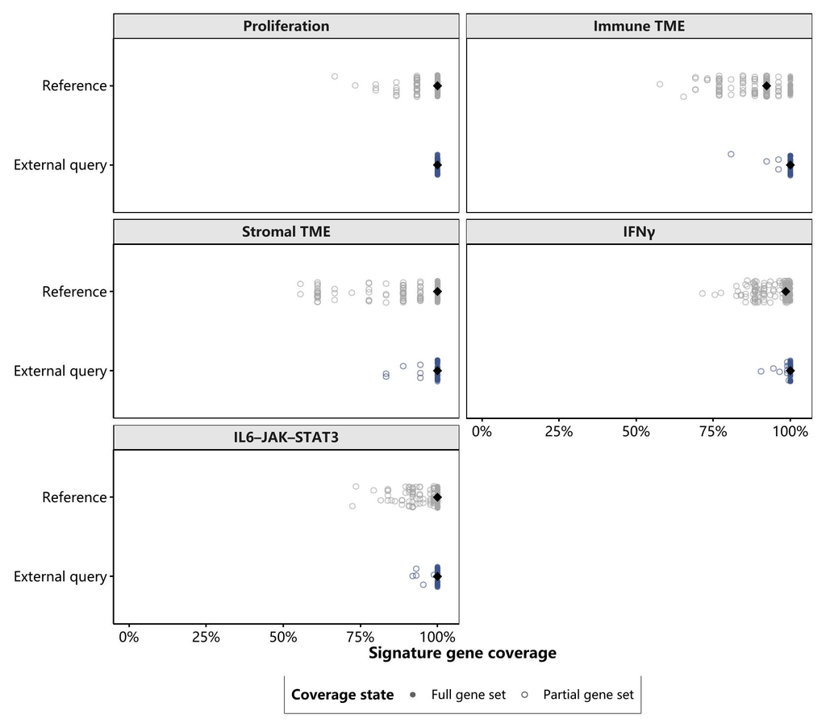

```r
knitr::include_graphics(coverage_jpg)
```

解读：横轴每个点是一项 cohort–gene signature 的输入基因覆盖率，黑色菱形为队列中位数，1 表示该队列表达矩阵包含该 gene signature 的全部基因行名。当前 43 个外部 cohort 与 5 个 gene signature 组成的审计中，有 24 个组合覆盖不足 100%；实际缺失分数的 query–邻居对为 0 个。部分覆盖意味着不同队列的分数可能由不同基因子集计算，若该队列效应很大，应先检查缺了哪些基因、哪些基因有有效 reference 标尺，以及最终配对 query 是否减少。基因齐全只说明预设基因在输入中存在，不保证每个基因都实际进入评分，也不能证明这些 gene signature 独立于 CCS 输入或已验证生物效用。

```r
biology_coverage_widget <- htmltools::tagList()
if (identical(biology_status, "complete")) {
  biology_coverage_widget <- render_dt(biology_coverage, pageLength = 10)
}
biology_coverage_widget
```

|  | tissue | cohort | cohort_key | anchor | genes_required | genes_found | coverage | sample_count | id_type | status | reason | external_query_cohort |
| --- | --- | --- | --- | --- | --- | --- | --- | --- | --- | --- | --- | --- |
| 1 | ACC | GSE143383 | ACC/GSE143383 | proliferation | 15 | 15 | 1 | 63 | ENSEMBL | estimable |  | False |
| 2 | ACC | GSE143383 | ACC/GSE143383 | immune_tme | 26 | 24 | 0.923076923076923 | 63 | ENSEMBL | estimable |  | False |
| 3 | ACC | GSE143383 | ACC/GSE143383 | stromal_tme | 18 | 16 | 0.888888888888889 | 63 | ENSEMBL | estimable |  | False |
| 4 | ACC | GSE143383 | ACC/GSE143383 | ifn | 200 | 200 | 1 | 63 | ENSEMBL | estimable |  | False |
| 5 | ACC | GSE143383 | ACC/GSE143383 | il6 | 87 | 87 | 1 | 63 | ENSEMBL | estimable |  | False |
| 6 | ACC | GSE19750 | ACC/GSE19750 | proliferation | 15 | 15 | 1 | 48 | ENSEMBL | estimable |  | False |
| 7 | ACC | GSE19750 | ACC/GSE19750 | immune_tme | 26 | 24 | 0.923076923076923 | 48 | ENSEMBL | estimable |  | False |
| 8 | ACC | GSE19750 | ACC/GSE19750 | stromal_tme | 18 | 18 | 1 | 48 | ENSEMBL | estimable |  | False |
| 9 | ACC | GSE19750 | ACC/GSE19750 | ifn | 200 | 197 | 0.985 | 48 | ENSEMBL | estimable |  | False |
| 10 | ACC | GSE19750 | ACC/GSE19750 | il6 | 87 | 87 | 1 | 48 | ENSEMBL | estimable |  | False |

[output cut: 90 more lines]

解读：coverage 表的 950 行分别对应一个 cohort–gene signature 组合；`genes_required` 是预设基因数，`genes_found` 是该 cohort 输入矩阵中存在的 gene signature 基因数，二者相除才是 `coverage`。对效果异常的队列，应先在这一行核对输入基因缺口，再结合 reference 标尺与缺失分数表核对评分和 query–邻居对是否完整；若不同队列依据的基因子集不同，同名 gene signature 分数也未必严格可比。此表的 `status=estimable` 仅表示输入中至少存在两个 gene signature 基因；最终评分还要求至少两个基因具有有效 reference 标尺，样本分数须有限。它与后面推断表要求至少 3 个有效 cohort 的同名状态含义不同，不能混读为同一种资格，更不能由此推断 gene signature 与模型输入独立。

```r
biology_utility_widget <- htmltools::tagList()
if (identical(biology_status, "complete")) {
  biology_utility_widget <- render_dt(biology_utility, pageLength = 10)
}
biology_utility_widget
```

|  | anchor | representation | query_count | neighbour_pairs | expected_neighbour_pairs | missing_score_pairs | mean_abs_delta | abs_delta_ci_low | abs_delta_ci_high | utility | utility_ci_low | utility_ci_high |
| --- | --- | --- | --- | --- | --- | --- | --- | --- | --- | --- | --- | --- |
| 1 | proliferation | Cohort-d1 | 14060 | 210900 | 210900 | 0 | 1.74562351316282 | 1.48185469915715 | 2.064898089532 | 0.599305340830573 | 0.596992555391381 | 0.601686741399405 |
| 2 | proliferation | Direct-GSClassifier | 14060 | 210900 | 210900 | 0 | 1.64743301394326 | 1.36132698030968 | 1.95577053859431 | 0.646326209734764 | 0.643680354866268 | 0.648906488682291 |
| 3 | immune_tme | Cohort-d1 | 14060 | 210900 | 210900 | 0 | 1.41250789359906 | 1.18181214406221 | 1.71669660931089 | 0.60148597522047 | 0.598608831022358 | 0.604470975796509 |
| 4 | immune_tme | Direct-GSClassifier | 14060 | 210900 | 210900 | 0 | 1.2987150723372 | 1.05371027074209 | 1.61054173808153 | 0.650744290641738 | 0.647855625708175 | 0.653911317356741 |
| 5 | stromal_tme | Cohort-d1 | 14060 | 210900 | 210900 | 0 | 1.48951406582819 | 1.27763193581724 | 1.69972880811897 | 0.574434166571266 | 0.571726223923884 | 0.57707740560497 |
| 6 | stromal_tme | Direct-GSClassifier | 14060 | 210900 | 210900 | 0 | 1.36855853886681 | 1.15968329176036 | 1.59788632704669 | 0.623893177564776 | 0.621065172115239 | 0.626854450330717 |
| 7 | ifn | Cohort-d1 | 14060 | 210900 | 210900 | 0 | 2.69837825363738 | 2.17342602951625 | 3.2619622245132 | 0.638966100356294 | 0.636939998176188 | 0.641329418372137 |
| 8 | ifn | Direct-GSClassifier | 14060 | 210900 | 210900 | 0 | 2.59649775911295 | 2.10031611286861 | 3.12372890716154 | 0.688235502921477 | 0.685698900085289 | 0.690571060052887 |
| 9 | il6 | Cohort-d1 | 14060 | 210900 | 210900 | 0 | 2.0885010868872 | 1.74452907823716 | 2.50567361243323 | 0.633763436802261 | 0.63120649614911 | 0.636113152253321 |
| 10 | il6 | Direct-GSClassifier | 14060 | 210900 | 210900 | 0 | 1.96624127291163 | 1.63595353424718 | 2.30005824242134 | 0.691792176822047 | 0.689095163953938 | 0.694298495112088 |

解读：表中每个 gene signature 有 Direct 和 d1 两行，`utility` 是各自找到的前 15 个邻居与 query 的平均表达接近度。例如增殖 gene signature 的 Direct 为 0.646，d1 为 0.599；这两个数是对同一批完整配对 query 分别汇总的单臂水平，不能直接拿它们的差代替后面的 cohort 等权效应。表内单臂区间按样本重采样，只描述当前 query 样本均值的变化，没有处理同 cohort 内依赖；向新 cohort 推广的判断应看下一节的配对差与 cohort bootstrap 区间。

读这张表时，可以先在同一 gene signature 下对照两行分臂 utility：这回答“各自找到的邻居有多近”，尚未回答“换表示后平均改变多少”。后一个问题必须回到每个 query 的成对差 $U_{a,q}^{(\mathrm{d1})}-U_{a,q}^{(\mathrm{Direct})}$；若一个队列患者很多，不能让它仅凭人数盖过其他外部队列。

### 4.6 配对效应与不确定性

本节改用配对效应，是因为同一患者的表达分数固定，变化的是两臂为其选出的邻居。对某个 gene signature，令 $\mathcal Q_{a,c}$ 为 cohort $c$ 中两臂分数完整的 query 集合，$n_{a,c}$ 为其人数，$C_a$ 为具有有效配对患者的 cohort 数：

$$\begin{aligned}
\Delta_{a,q}&=U_{a,q}^{(\mathrm{d1})}-U_{a,q}^{(\mathrm{Direct})},\\
\bar\Delta_{a,c}&=\frac{1}{n_{a,c}}\sum_{q\in\mathcal
Q_{a,c}}\Delta_{a,q},\\
\widehat\Delta_a&=\frac{1}{C_a}\sum_{c=1}^{C_a}\bar\Delta_{a,c}.
\end{aligned}$$

这三行分别对应**一位患者、一个队列、全部有效队列**。例如，某患者 d1 的 utility 为 0.55、Direct 为 0.65，则 $\Delta=-0.10$，表示接近度分数低 0.10。零表示两臂平均接近度相同，正值偏向 d1，负值偏向 Direct；差值范围为 $[-1,1]$。这里的 $-0.10$ 是接近度的绝对差，不能读成准确率低 10 个百分点，也不能读成原 utility 相对下降 10%。

队列等权与合并患者可以给出不同答案。教学示例中，队列 A 有 100 人、平均差为 $-0.10$；队列 B 有 10 人、平均差为 $+0.20$。队列等权是 $(-0.10+0.20)/2=+0.05$，而合并患者是 $(100\times(-0.10)+10\times0.20)/110\approx-0.073$。前者问“各队列给一票，平均怎样改变”，后者问“当前合并患者中，平均怎样改变”。本节主效应采用前者；上面的单臂 utility 表按患者汇总，两行相减对应后者，不能代替这里的主效应。

95% 区间对**完整 cohort 的配对均值**有放回地抽样：每次抽取 $C_a$ 个队列均值、求等权平均，按当前产物记录重复 2000 次，取 2.5% 与 97.5% 分位数。重采样没有重训模型、重估 reference 尺子或重找邻居，区间条件于这些已冻结的对象。它反映当前外部队列组合的波动，不把一位患者的 15 个邻居或一个队列的数百位患者当成独立外部验证；要推广到未来队列，还需当前队列之间足够独立且能代表目标场景。

P 值另用双侧配对 sign-flip 检验：在零假设下队列差值的符号可交换的前提下，保留每个差值的大小、改变正负号，检查所得平均差的绝对值有多常达到观察值。最多 18 个 cohort 时枚举全部符号组合，更多时用 Monte Carlo 并做加一校正；当前方法为 monte_carlo_paired_sign_flip。区间与 P 值来自不同构造，不能互相换算；跨零不证明等价，未跨零也不能替代多重检验结论。

五个选定 gene signature 固定作为一个检验族做 Benjamini–Hochberg（BH）校正，缺失或不可估计项仍计入五项分母，表中 `p_value_adj` 用于控制该检验族的假发现率，不能读成某一结论出错的概率。少于 3 个有效 cohort 时，仅保留描述性点估计，区间和 P 值为 NA。五项 gene signature 可能共享表达过程，因此同向结果也不能算作五次独立机制验证。

```r
fig_inference <- list(width_in = 9.2, height_in = 3.5, base_size = 10,
  point_size = 2.6, line_size = 0.55)
inference_plot <- biology_inference
inference_plot$plot_row <- match(inference_plot$anchor, rev(anchor_order))
inference_plot$effect_label <- paste0(
  fmt(inference_plot$estimate), " [", fmt(inference_plot$ci_low),
  ", ", fmt(inference_plot$ci_high), "]"
)
inference_plot$p_label <- ifelse(is.na(inference_plot$p_value_adj), "NA",
  ifelse(inference_plot$p_value_adj < 0.001, "<0.001",
    fmt(inference_plot$p_value_adj)))
row_limits <- c(0.45, length(anchor_order) + 1.15)
header_y <- length(anchor_order) + 0.75
effect_limits <- range(c(inference_plot$estimate,
  inference_plot$ci_low, inference_plot$ci_high, 0), na.rm = TRUE)
effect_padding <- max(0.005, diff(effect_limits) * 0.08)
p_effect <- ggplot2::ggplot(inference_plot,
  ggplot2::aes(x = .data$estimate, y = .data$plot_row)) +
  ggplot2::geom_vline(xintercept = 0, linetype = "dashed",
    color = "grey60", linewidth = 0.4) +
  ggplot2::geom_errorbar(data = inference_plot[
    inference_plot$inference_status == "estimable", , drop = FALSE],
    ggplot2::aes(xmin = .data$ci_low, xmax = .data$ci_high),
    orientation = "y", width = 0.12, color = nature_colors[["navy"]],
    linewidth = fig_inference$line_size, na.rm = TRUE) +
  ggplot2::geom_point(ggplot2::aes(shape = .data$inference_status),
    size = fig_inference$point_size, color = nature_colors[["navy"]]) +
  ggplot2::scale_shape_manual(values = c(
    "estimable" = 16, "not_estimable" = 1
  ), guide = "none") +
  ggplot2::scale_y_continuous(breaks = seq_along(anchor_order),
    labels = unname(anchor_labels[rev(anchor_order)]),
    limits = row_limits, expand = ggplot2::expansion(mult = 0)) +
  ggplot2::scale_x_continuous(breaks = scales::breaks_pretty(n = 4),
    labels = scales::label_number(accuracy = 0.01),
    limits = effect_limits + c(-effect_padding, effect_padding),
    expand = ggplot2::expansion(mult = 0)) +
  ggplot2::labs(
    x = plot_label("Paired utility difference (d1 - Direct)",
      "配对效用差（d1 − Direct）"), y = NULL
  ) +
  theme_nature_readable(base_size = fig_inference$base_size,
    legend_position = "none") +
  ggplot2::theme(
    panel.border = ggplot2::element_blank(),
    axis.line.y = ggplot2::element_blank(),
    axis.line.x = ggplot2::element_line(color = "grey45", linewidth = 0.35),
    axis.ticks.y = ggplot2::element_blank(),
    axis.ticks.x = ggplot2::element_line(color = "grey45", linewidth = 0.35),
    axis.title.x = ggplot2::element_text(size = 9, face = "plain",
      margin = ggplot2::margin(t = 8)),
    axis.text.y = ggplot2::element_text(margin = ggplot2::margin(r = 10)),
    plot.margin = ggplot2::margin(6, 12, 6, 6)
  )
# The statistics use a separate panel, so annotation cannot stretch the effect axis.
stat_columns <- c(effect = 0, cohorts = 2.65, queries = 3.55, p = 4.55)
stat_headers <- data.frame(
  x = unname(stat_columns),
  label = c(plot_label("Difference [95% CI]", "差值 [95% CI]"),
    plot_label("Cohorts", "队列数"), plot_label("Queries", "患者数"), "BH P")
)
p_statistics <- ggplot2::ggplot(inference_plot,
  ggplot2::aes(y = .data$plot_row)) +
  ggplot2::geom_hline(yintercept = length(anchor_order) + 0.4,
    color = "grey80", linewidth = 0.35) +
  ggplot2::geom_text(ggplot2::aes(x = stat_columns[["effect"]],
    label = .data$effect_label), hjust = 0, size = 3.2, color = "grey20") +
  ggplot2::geom_text(ggplot2::aes(x = stat_columns[["cohorts"]],
    label = .data$cohort_count), size = 3.2, color = "grey20") +
  ggplot2::geom_text(ggplot2::aes(x = stat_columns[["queries"]],
    label = format(.data$query_count, big.mark = ",", trim = TRUE)),
    size = 3.2, color = "grey20") +
  ggplot2::geom_text(ggplot2::aes(x = stat_columns[["p"]],
    label = .data$p_label), size = 3.2, color = "grey20") +
  ggplot2::geom_text(data = stat_headers,
    ggplot2::aes(x = .data$x, y = header_y, label = .data$label),
    inherit.aes = FALSE, hjust = c(0, 0.5, 0.5, 0.5),
    size = 3.2, fontface = "bold", color = "grey20") +
  ggplot2::scale_y_continuous(limits = row_limits,
    expand = ggplot2::expansion(mult = 0)) +
  ggplot2::scale_x_continuous(limits = c(-0.05, 5.05),
    expand = ggplot2::expansion(mult = 0)) +
  ggplot2::theme_void(base_size = fig_inference$base_size,
    base_family = getOption("bensz.base_family", "sans")) +
  ggplot2::theme(plot.margin = ggplot2::margin(6, 6, 6, 0))
p_inference <- patchwork::wrap_plots(p_effect, p_statistics,
  nrow = 1, widths = c(1, 1.35))
inference_jpg <- .ae_save_plot(p_inference,
  "02.02.00. anchor-paired-effect", figure_dir, preview_dir,
  fig_inference, params$plot_preview_dpi)
```

```
## Converting page 1 to D:/cache/ccs/_ablation-03/logs/report-previews/02.02.00-biology-20261008205659/02.02.00. anchor-paired-effect.jpg... done!
```

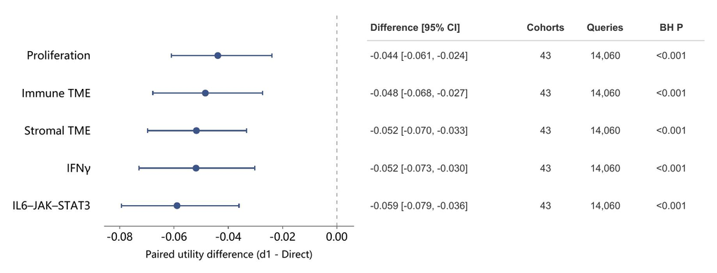

```r
knitr::include_graphics(inference_jpg)
```

解读：纵轴每一行是一个预设 gene signature，顺序按配置排列；圆点对应公式中的队列等权 $\widehat\Delta_a$，横线是该 gene signature 的 95% cohort bootstrap 区间，虚线为零差值。点在零线左侧表示 d1 邻居的接近度较低；整段横线在左侧，则该区间支持负向平均差。右侧独立统计列依次列出差值及区间、有效 cohort 数（Cohorts）、配对 query 人数（Queries）和 BH 校正 P 值（BH P），患者数标为 Queries。未达推断门槛时仅绘空心点，区间与 P 值保留 NA。当前 5 个达到预设 cohort 门槛的 anchor，其 cohort 等权效应范围为 -0.059 至 -0.044，5 项可估计区间完全低于零，5 项 BH 校正 P 值低于 0.05。

绝对差最大的预设 gene signature 是 il6，点估计 -0.059，涉及 43 个 cohort、14060 位 query，区间为 [-0.079, -0.036]。例如增殖 gene signature 在单臂表中的 d1−Direct 差为 -0.047，而此图的队列等权差为 -0.044；二者的差别来自患者与队列的权重，不是计算矛盾。当前图量化的是**局部连续表达邻居任务的接近度代价**；不能据此判断临床影响，也不宜因某项点更靠左就宣布对应生物过程受损最严重。

```r
biology_inference_widget <- htmltools::tagList()
if (identical(biology_status, "complete")) {
  biology_inference_widget <- render_dt(
    biology_inference[, c(
      "anchor", "estimate", "ci_low", "ci_high", "p_value",
      "p_value_adj", "p_method", "cohort_count", "query_count",
      "min_cohorts", "inference_status"
    )],
    pageLength = 10
  )
}
biology_inference_widget
```

|  | anchor | estimate | ci_low | ci_high | p_value | p_value_adj | p_method | cohort_count | query_count | min_cohorts | inference_status |
| --- | --- | --- | --- | --- | --- | --- | --- | --- | --- | --- | --- |
| 1 | ifn | -0.051882808653934 | -0.0728740466157629 | -0.0302484651180868 | 0.000499750124937531 | 0.000499750124937531 | monte_carlo_paired_sign_flip | 43 | 14060 | 3 | estimable |
| 2 | il6 | -0.0588712938544495 | -0.0793897754228101 | -0.0360351292111409 | 0.000499750124937531 | 0.000499750124937531 | monte_carlo_paired_sign_flip | 43 | 14060 | 3 | estimable |
| 3 | immune_tme | -0.0484507601802125 | -0.0677965095461159 | -0.0273424773458081 | 0.000499750124937531 | 0.000499750124937531 | monte_carlo_paired_sign_flip | 43 | 14060 | 3 | estimable |
| 4 | proliferation | -0.0438575007158691 | -0.0610020408857028 | -0.0239236700471792 | 0.000499750124937531 | 0.000499750124937531 | monte_carlo_paired_sign_flip | 43 | 14060 | 3 | estimable |
| 5 | stromal_tme | -0.0517427158797211 | -0.0697641094252172 | -0.0332158402240529 | 0.000499750124937531 | 0.000499750124937531 | monte_carlo_paired_sign_flip | 43 | 14060 | 3 | estimable |

解读：表中的 `estimate` 先在同一 query 上相减、再对完整 cohort 等权；`ci_low/ci_high` 来自 cohort bootstrap，`p_value_adj` 在预设的 gene signature 族内做 BH 校正。当前 5／5 项点估计为负；绝对差最大的 il6 为 -0.059，区间 [-0.079, -0.036]，涉及 43 个 cohort。这支持在当前gene signature 分数的邻居任务中存在局部接近度代价，不能推广为所有生物任务的损失。若某行未达预设 cohort 门槛，区间和 P 值应保持 NA；即使调整后 P 值很小，也仍须结合差值量级、基因覆盖及共享表达来源判断。

当前各可估计 gene signature 的校正 P 值为 ifn：<0.001；il6：<0.001；immune_tme：<0.001；proliferation：<0.001；stromal_tme：<0.001。对采用 Monte Carlo 的行，加一校正使最小可报告原始 P 值为 $1/(B+1)$，其中 $B$ 是模拟次数；本次推断记录的重复次数为 2000。若多行达到相同下限，只说明模拟分辨率已用尽，不能据此给几项证据强弱排序；精确枚举行则不采用这个下限。

### 4.7 队列间效应分布

先看各队列的平均配对差如何分布，再看同一格子的均值对队列内患者组成有多敏感。热图与区间图使用同一组 cohort–gene signature 格子，分别呈现效应分布和各均值的不确定性。

#### 4.7.1 队列配对均值

总体平均可能掩盖方向相反的队列，因此热图保留每个 cohort 的 $\bar\Delta_c$。它像看全班平均分之后再看每个班：多数班同向比单个超大班拉动均值更有说服力；热图只编码各格子的描述性均值，对应的队列内 query 区间见下一小节；颜色深浅不代表显著性。若某格特别深，应连同该队列的有效 query 数、gene signature 基因覆盖和测量来源一起核查。

```r
fig_cohort <- list(width_in = 9.1, height_in = 11.2, base_size = 9)
cohort_levels <- sort(unique(biology_cohort$query_cohort))
cohort_grid <- expand.grid(
  query_cohort = cohort_levels, anchor = anchor_order,
  stringsAsFactors = FALSE
)
cohort_plot <- merge(cohort_grid, biology_cohort,
  by = c("query_cohort", "anchor"), all.x = TRUE, sort = FALSE)
cohort_plot$query_cohort <- factor(cohort_plot$query_cohort,
  levels = rev(cohort_levels))
cohort_plot$anchor <- factor(cohort_plot$anchor, levels = anchor_order)
color_limit <- max(abs(biology_cohort$delta_d1_minus_direct))
if (!is.finite(color_limit) || color_limit == 0) color_limit <- 0.01
p_cohort <- ggplot2::ggplot(cohort_plot,
  ggplot2::aes(x = .data$anchor, y = .data$query_cohort,
    fill = .data$delta_d1_minus_direct)) +
  ggplot2::geom_tile(color = "white", linewidth = 0.25) +
  ggplot2::scale_x_discrete(labels = anchor_labels) +
  ggplot2::scale_fill_gradient2(
    low = nature_colors[["navy"]], mid = "white",
    high = nature_colors[["orange"]], midpoint = 0,
    limits = c(-color_limit, color_limit), na.value = "grey85",
    name = plot_label("d1 - Direct", "d1 − Direct")
  ) +
  ggplot2::labs(x = NULL,
    y = plot_label("External query cohort", "外部 query 队列")
  ) +
  theme_nature_readable(base_size = fig_cohort$base_size,
    legend_position = "right") +
  ggplot2::theme(
    axis.text.y = ggplot2::element_text(size = 8),
    axis.text.x = ggplot2::element_text(size = 9, angle = 20, hjust = 1),
    panel.grid = ggplot2::element_blank()
  )
cohort_jpg <- .ae_save_plot(p_cohort,
  "02.02.00. anchor-cohort-heterogeneity", figure_dir, preview_dir,
  fig_cohort, params$plot_preview_dpi)
```

```
## Converting page 1 to D:/cache/ccs/_ablation-03/logs/report-previews/02.02.00-biology-20261008205659/02.02.00. anchor-cohort-heterogeneity.jpg... done!
```

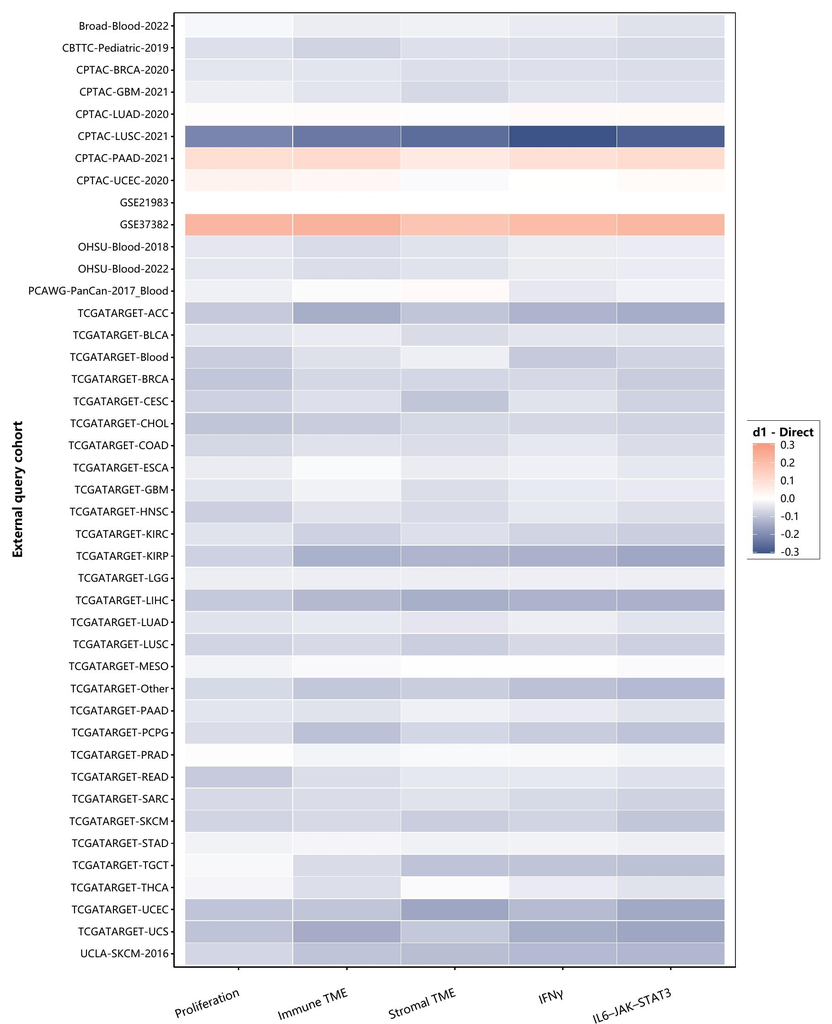

```r
knitr::include_graphics(cohort_jpg)
```

解读：热图每行是一个外部 query cohort，每列是一个 gene signature；格子颜色来自该 cohort 内 24 至 1094 个两臂配对 query 的平均 d1−Direct utility 差。当前 90.2% 的可估计格子为负值，不是单个异常队列造成的整图负向。最负向的是 CPTAC-LUSC-2021 的 ifn（-0.306，108 个 query）；最正向的是 GSE37382 的 immune_tme（0.235）。两端格子应回查 gene signature 基因覆盖和来源构成；图中极值用于描述效应分布，单格没有独立 P 值，颜色深浅不表示显著性。

#### 4.7.2 gene signature 格子的队列内波动

下图和明细表对每个预设 gene signature 和 query cohort 在**同一 cohort 内**重采样完整配对 query，给出 utility 差的点式 95% 区间。只有至少 20 个可用 query 的格子才估计区间；其余格子保留描述性点估计、NA 区间和原因。此区间衡量当前 cohort 内患者组成的波动，与上文跨 cohort 的主效应区间不同。

```r
local_biology <- statistical_inference$biology_local
stopifnot(
  nrow(local_biology) > 0L,
  !anyDuplicated(local_biology[c("anchor", "cohort")]),
  setequal(local_biology$anchor, anchor_order),
  all(local_biology$unit == "query_within_cohort"),
  all(local_biology$method == "within_cohort_query_percentile_bootstrap")
)
# The interval plot must reproduce the same cells as the descriptive heatmap.
local_contract <- merge(local_biology, biology_cohort,
  by.x = c("anchor", "cohort"), by.y = c("anchor", "query_cohort"))
stopifnot(
  nrow(local_contract) == nrow(local_biology),
  nrow(local_contract) == nrow(biology_cohort),
  isTRUE(all.equal(local_contract$estimate,
    local_contract$delta_d1_minus_direct, tolerance = 1e-10)),
  all(local_contract$n_query == local_contract$query_count)
)
utils::write.csv(local_biology,
  file.path(table_dir, "02.02.00. anchor-within-cohort-inference.csv"),
  row.names = FALSE)
local_estimable <- local_biology[local_biology$status == "estimable", , drop = FALSE]
local_not_estimable_count <- sum(local_biology$status != "estimable")
local_cross_zero_count <- sum(local_estimable$ci_low <= 0 &
  local_estimable$ci_high >= 0)
local_plot <- local_biology
local_cohort_order <- sort(unique(local_plot$cohort))
local_plot$cohort <- factor(local_plot$cohort, levels = rev(local_cohort_order))
local_plot$anchor <- factor(local_plot$anchor, levels = anchor_order)
local_limits <- range(c(0, local_plot$estimate,
  local_plot$ci_low, local_plot$ci_high), na.rm = TRUE)
local_padding <- max(0.01, diff(local_limits) * 0.06)
fig_local <- list(width_in = 12.5,
  height_in = max(6, length(local_cohort_order) * 0.22 + 1.1),
  base_size = 9, point_size = 1.6, line_size = 0.4)
p_local <- ggplot2::ggplot(local_plot,
  ggplot2::aes(x = .data$estimate, y = .data$cohort)) +
  ggplot2::geom_vline(xintercept = 0, color = "grey55",
    linetype = "dashed", linewidth = 0.35) +
  ggplot2::geom_errorbar(data = local_plot[
    local_plot$status == "estimable", , drop = FALSE],
    ggplot2::aes(xmin = .data$ci_low, xmax = .data$ci_high),
    orientation = "y", width = 0.14, linewidth = fig_local$line_size,
    color = nature_colors[["navy"]]) +
  ggplot2::geom_point(ggplot2::aes(shape = .data$status),
    size = fig_local$point_size, color = nature_colors[["navy"]], na.rm = TRUE) +
  ggplot2::facet_wrap(~anchor, nrow = 1,
    labeller = ggplot2::labeller(anchor = ggplot2::as_labeller(anchor_labels))) +
  ggplot2::scale_shape_manual(
    values = c(estimable = 16, not_estimable = 1),
    breaks = c("estimable", "not_estimable"),
    labels = c(plot_label("95% CI available", "可估计 95% CI"),
      plot_label("Descriptive only", "仅描述性估计")),
    guide = if (local_not_estimable_count > 0L) "legend" else "none"
  ) +
  ggplot2::scale_x_continuous(
    limits = local_limits + c(-local_padding, local_padding),
    breaks = scales::breaks_pretty(n = 3),
    labels = scales::label_number(accuracy = 0.1),
    expand = ggplot2::expansion(mult = 0)
  ) +
  ggplot2::scale_y_discrete(drop = FALSE,
    expand = ggplot2::expansion(add = 0.7)) +
  ggplot2::labs(
    x = plot_label("Paired utility difference (d1 - Direct)",
      "配对效用差（d1 − Direct）"),
    y = plot_label("External query cohort", "外部 query 队列"),
    shape = NULL
  ) +
  theme_nature_readable(base_size = fig_local$base_size,
    legend_position = "bottom") +
  ggplot2::theme(
    panel.border = ggplot2::element_blank(),
    axis.line.y = ggplot2::element_blank(),
    axis.line.x = ggplot2::element_line(color = "grey50", linewidth = 0.3),
    axis.ticks.y = ggplot2::element_blank(),
    axis.ticks.x = ggplot2::element_line(color = "grey50", linewidth = 0.3),
    axis.text.y = ggplot2::element_text(size = 8,
      margin = ggplot2::margin(r = 5)),
    axis.title = ggplot2::element_text(size = 9, face = "plain"),
    panel.grid.major.y = ggplot2::element_line(color = "grey94", linewidth = 0.25),
    panel.spacing.x = grid::unit(0.7, "lines"),
    strip.background = ggplot2::element_blank(),
    strip.text = ggplot2::element_text(size = 10, face = "bold"),
    plot.margin = ggplot2::margin(8, 8, 8, 8)
  )
local_jpg <- .ae_save_plot(p_local,
  "02.02.00. anchor-within-cohort-inference", figure_dir, preview_dir,
  fig_local, params$plot_preview_dpi)
```

```
## Converting page 1 to D:/cache/ccs/_ablation-03/logs/report-previews/02.02.00-biology-20261008205659/02.02.00. anchor-within-cohort-inference.jpg... done!
```

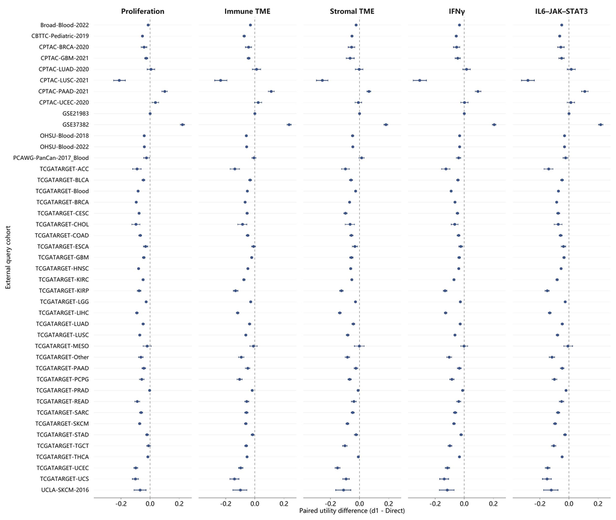

```r
knitr::include_graphics(local_jpg)
```

解读：五列 gene signature 按配置顺序排列，队列与前面的异质性热图一样按字典序排列；每个圆点复现热图同一格子的配对均值，横线给出该格子的队列内 95% query bootstrap 区间，虚线为零差值。每格基于 24 至 1094 个有效配对 query；当前 215／215 个格子可估计区间，23 个区间包含零。横线更长表示在当前冻结条件下均值对患者组成更敏感，并不直接等同于患者个体差异更大；区间同时受样本量与差值分布影响。空心点只表示描述性估计，缺失区间不画成零宽区间，原因保留在表中。

这些是**逐格的点式区间，未对全部格子作同时覆盖校正**。区间完全位于零的一侧可描述该格子的方向与不确定性，不能当作经多重检验确认的亚组发现；跨零也不能证明等价。它们条件于当前 cohort、冻结模型、reference 尺子和近邻名单，不包含 bank 重训、reference 更换或未来 cohort 的波动，不能替代上文的 cohort 等权主区间。热图极值用于定位队列差异，不提供单格 P 值。

```r
render_dt(local_biology, pageLength = 20L)
```

|  | endpoint | cohort | estimate | ci_low | ci_high | n_query | resamples | valid_resamples | seed | unit | method | status | reason | anchor |
| --- | --- | --- | --- | --- | --- | --- | --- | --- | --- | --- | --- | --- | --- | --- |
| 1 | anchor_ifn_utility_d1_minus_direct | Broad-Blood-2022 | -0.03289507057720094 | -0.03772336012138006 | -0.02794905341362989 | 715 | 2000 | 2000 | 20261025 | query_within_cohort | within_cohort_query_percentile_bootstrap | estimable |  | ifn |
| 2 | anchor_ifn_utility_d1_minus_direct | CBTTC-Pediatric-2019 | -0.05487455284691244 | -0.06257815365834236 | -0.04755664447186052 | 973 | 2000 | 2000 | 20261026 | query_within_cohort | within_cohort_query_percentile_bootstrap | estimable |  | ifn |
| 3 | anchor_ifn_utility_d1_minus_direct | CPTAC-BRCA-2020 | -0.05247036304368244 | -0.07382278953750243 | -0.03066053870134297 | 122 | 2000 | 2000 | 20261027 | query_within_cohort | within_cohort_query_percentile_bootstrap | estimable |  | ifn |
| 4 | anchor_ifn_utility_d1_minus_direct | CPTAC-GBM-2021 | -0.0450061904382684 | -0.06191673348882229 | -0.02823631521562254 | 99 | 2000 | 2000 | 20261028 | query_within_cohort | within_cohort_query_percentile_bootstrap | estimable |  | ifn |
| 5 | anchor_ifn_utility_d1_minus_direct | CPTAC-LUAD-2020 | 0.01547186049256961 | -0.01060921163964736 | 0.04137201585736239 | 110 | 2000 | 2000 | 20261029 | query_within_cohort | within_cohort_query_percentile_bootstrap | estimable |  | ifn |
| 6 | anchor_ifn_utility_d1_minus_direct | CPTAC-LUSC-2021 | -0.3059916121522102 | -0.3503634166900595 | -0.260075923045362 | 108 | 2000 | 2000 | 20261030 | query_within_cohort | within_cohort_query_percentile_bootstrap | estimable |  | ifn |
| 7 | anchor_ifn_utility_d1_minus_direct | CPTAC-PAAD-2021 | 0.0936666232320239 | 0.07528311954411564 | 0.113491198790028 | 140 | 2000 | 2000 | 20261031 | query_within_cohort | within_cohort_query_percentile_bootstrap | estimable |  | ifn |
| 8 | anchor_ifn_utility_d1_minus_direct | CPTAC-UCEC-2020 | 0.00141653282365332 | -0.02441019622655569 | 0.02579373204471853 | 95 | 2000 | 2000 | 20261032 | query_within_cohort | within_cohort_query_percentile_bootstrap | estimable |  | ifn |
| 9 | anchor_ifn_utility_d1_minus_direct | GSE21983 | 3.222440913740702e-82 | -2.592220787174899e-106 | 9.667322741222106e-82 | 72 | 2000 | 2000 | 20261033 | query_within_cohort | within_cohort_query_percentile_bootstrap | estimable |  | ifn |
| 10 | anchor_ifn_utility_d1_minus_direct | GSE37382 | 0.2054301646919057 | 0.1923796457798502 | 0.2180682417892564 | 285 | 2000 | 2000 | 20261034 | query_within_cohort | within_cohort_query_percentile_bootstrap | estimable |  | ifn |

[output cut: 90 more lines]

### 4.8 这项分析怎样进入论文的论证

**本节为“技术标签聚集减弱”补上了一个必须检查的代价问题：原有连续表达关系保留了多少？** 技术联合评估已经说明，同技术邻居减少也可能伴随癌种组成改变，不能单独证明去噪成功。连续 gene signature 分数进一步检查标签内部和跨标签的表达关系，避免把“不再按已有标签聚集”自动写成“更接近有用生物状态”。但本节同样没有固定癌种内检索，表达分数也可能携带平台痕迹，所以负差尚不能分解为纯生物信号损失或技术信号去除。

当前 5／5 项预设 gene signature 平均差为负，热图中 90.2% 的可估计格子为负。**这一结果说明局部表达关系确实发生了变化，而效应量进一步说明平均代价较小。** 广队列接近度的平均绝对下降约为 0.04–0.06，高覆盖同癌种比较的点估计则更接近零。论文应将变化的方向与量级一起呈现：d1 对这组 gene signature 的局部匹配略有代价，而跨队列共同表示仍是 CCS 的核心用途。是否适合采用 d1，取决于任务更重视局部表达匹配还是跨队列表征；总体平均不能代替每个队列或每位患者的表现。

| 论文中的位置 | 本节提供的证据 | 仍需什么才能进一步判断 |
| --- | --- | --- |
| 表示消融的主结果 | 同一患者、共同候选池和共同表达标尺下的 cohort 等权效应及区间，量化跨队列表征的平均局部匹配代价 | 当前效应量支持方法取舍的判断；正式非劣效或等价性结论另需预设界值及相应检验 |
| 技术来源分析的配套解释 | 技术标签关系变化之外，连续表达邻居关系也存在可量化代价 | 癌种、平台与来源分层，以及完整共同基因集下的敏感性分析 |
| 补充材料的可复核性 | gene signature 定义、覆盖表、有效 query 数、逐队列差值和推断方法 | 极端格子用于提出机制问题，后续在未见队列确认 |
| 个性化分类的效用论证 | 明确当前表示的局部表达限制及适用任务 | 用病理、蛋白或治疗结局等不同来源目标开展独立验证，不能用当前同源 gene signature 替代 |

状态关系报告检查高低表达状态之间的较大尺度关系，与本页的患者近邻连续距离互补；粗状态关系接近不能抵消局部负差。若论文的核心用途是寻找表达状态尽量相近的患者，本页直接对应这一任务；若核心用途是跨队列分层，则应结合状态关系的跨队列一致性与独立目标评价。正文宜保留主要效应图和这一任务边界，覆盖明细与队列热图可放补充材料；两处都应交代共同表达来源和权重口径。

## 5 高覆盖 gene signature 验证

本章承接第 4.5 节的基因覆盖检查，将覆盖审计推进到测量条件更一致的验证。第 4.5 节逐队列统计预设 signature 基因在表达输入中的覆盖率，用于判断广队列基线使用的“尺子”是否完整；各队列覆盖率较高，也未必缺失同一批基因，因此不能据此认定它们测量的是同一套 signature。本章据此为每项 signature 选择高覆盖、测量兼容的队列，固定入选 query 与 reference 队列共同可测的 signature 基因和秩评分背景，重新评分并比较 d1 与 Direct 的邻居接近度及信息读取表现。前者说明原始测量条件，后者检验在更一致的测量条件下结果是否仍然成立，构成递进验证。两部分的有效人群与评分定义有所不同，因此效应变化不能全部归因于基因缺失。

全队列共同交集要求全部 190 个契约队列使用同一套 signature 基因，只有 0／5 项通过预设测量门槛。因此，本节在每项 signature 内筛选高覆盖、测量兼容的队列，再固定共同基因与评分背景；五项秩同癌种主比较已有 5／5 项可估计，各涉及 13–15 个有效 query 队列。前面的低资格数属于全队列交集合同，不能解释成筛选后的验证失败；详细审计保存在全队列共同测量附录。

队列选择依据基因可测性、有限值、样本数、已确认的癌种与外部 query 来源。区间条件于冻结 bank、测量合同及 reference/query 队列，不包含 bank 重训的不确定性。广队列基线、高覆盖验证与低覆盖探索分别报告各自的评分定义和有效人群。

高覆盖秩评分的背景门槛为 3000 个基因。评分使用各测量合同完整的共同背景交集。

### 5.1 覆盖率与队列广度

预设覆盖率为 60%、70%、80%、90%。各档合同要求至少 8 个完整 gene signature 基因、每队列至少 20 个完整 query、同癌种至少 2 个 reference 队列及完整 top-15。主设计选择达到 8 个 query 队列和 3 个已知来源组的最高档；支持较少时依预定规则降为有限外部验证或敏感性证据，保留全部覆盖率档。

搜索以基因可用频率的固定排序产生全体、单队列及两队列交集种子，再纳入所有可兼容队列，按队列数、来源数、query 数、共同基因数、reference 队列数依次选择。它是确定性的有界搜索，未证明获得全局最大队列集合。每份合同保存队列、样本、唯一共同完整 gene signature、共同秩背景及哈希；每个样本须完整测到冻结 gene signature，秩分数还须完整测到背景。未知来源不计入来源组。

下图衡量的是提高 gene signature 覆盖要求后，还能保留多少测量支持与验证广度。每列对应一个 gene signature，横轴 **Required signature coverage (%)** 是共同可用的原 signature 基因占原基因集的最低比例；例如要求 80% 覆盖，指保留至少 80% 的原 signature 基因，并非测到了全转录组的 80%。实际共同 signature 的基因数与覆盖率见下方表格的 `common_genes` 和 `coverage`。

图中三行纵轴的计数对象不同，含义及虚线门槛如下：

| 图中标签 | 计数对象与计算方式 | 为什么需要它 | 虚线门槛 |
| --- | --- | --- | --- |
| **Query cohorts（查询队列数）** | 当前 signature 和覆盖档位下，纳入冻结测量合同的外部 query 队列数，按 `cohort_key` 去重；每个队列至少有 20 个满足完整 signature 测量等条件的 query，且有足够的同癌种 reference 支持。统计的是队列数，不是患者数，也不包括 reference 队列。 | 衡量验证涉及多少个 query 队列，避免把单个大队列的人数当成跨队列证据。 | 8 个 query 队列，作为主设计的队列广度要求。 |
| **Source groups（来源组数）** | 上述入选 query 队列中已知 `source_system` 的不同取值数，例如 GEO、cBioPortal、UCSC Xena。同一来源下的多个队列只计一个来源组，未知来源不计入；这里不统计 reference 来源，也不是癌种数或测序平台数。 | 衡量 query 覆盖多少种数据库来源；多个队列若都来自 UCSC Xena，仍只贡献一个来源组。数据库来源不同本身不保证队列或患者彼此独立。 | 3 个已知来源组，作为主设计的来源广度要求。 |
| **Common background genes（共同背景基因数）** | 当前合同中所有入选 query 与 reference 队列表达矩阵的基因集合交集大小，包含共同 signature 基因及其它共同基因；它不是 signature 自身的基因数。 | 为样本内百分位秩提供相同的排名背景：先在这套共同基因中对表达值排名，再取 signature 基因的平均百分位秩。背景固定使评分定义可比，但不等于校正了 batch effect。 | 3000 个共同背景基因，作为秩主评分的背景规模要求。 |

```r
frontier <- high_coverage$frontier
frontier_long <- do.call(rbind, lapply(c("query_cohorts", "source_groups", "background_genes"), function(metric) {
  x <- frontier
  x$metric <- metric
  x$value <- x[[metric]]
  x
}))
p_hc_frontier <- ggplot2::ggplot(frontier_long,
  ggplot2::aes(x = 100 * tier, y = value, color = anchor, group = anchor)) +
  ggplot2::geom_hline(data = data.frame(metric = c("query_cohorts", "source_groups", "background_genes"),
    boundary = c(high_coverage$config$primary_min_query_cohorts,
      high_coverage$config$primary_min_source_groups, high_coverage$config$min_background_genes)),
    ggplot2::aes(yintercept = boundary), linetype = 2, color = "grey65") +
  ggplot2::geom_line(linewidth = .5) + ggplot2::geom_point(size = 2) +
  ggplot2::facet_grid(metric ~ anchor, scales = "free_y",
    labeller = ggplot2::labeller(anchor = ggplot2::as_labeller(anchor_labels),
      metric = ggplot2::as_labeller(c(query_cohorts = "Query\ncohorts",
        source_groups = "Source\ngroups", background_genes = "Common\nbackground genes")))) +
  ggplot2::scale_color_manual(values = stats::setNames(unname(nature_colors[c("navy", "green", "red", "purple", "brown")]), names(anchor_labels)),
    labels = anchor_labels) +
  ggplot2::scale_x_continuous(breaks = 100 * high_coverage$config$coverage_tiers) +
  ggplot2::scale_y_continuous(breaks = function(x) unique(round(pretty(x, n = 3)))) +
  ggplot2::labs(x = "Required signature coverage (%)", y = "Measurement support", color = NULL) +
  theme_nature_readable(base_size = 10, legend_position = "none") +
  ggplot2::theme(strip.text.y = ggplot2::element_text(angle = 0))
jpg <- hc_save_plot(p_hc_frontier, "02.02.00. high-coverage-frontier", width = 11, height = 7)
```

```
## Converting page 1 to D:/cache/ccs/_ablation-03/logs/report-previews/02.02.00-biology-20261008205659/02.02.00. high-coverage-frontier.jpg... done!
```

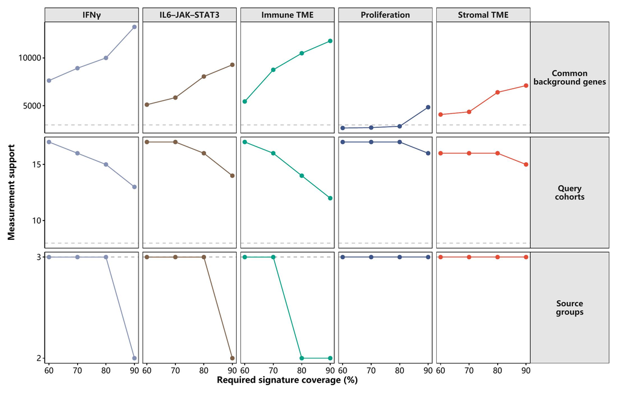

```r
knitr::include_graphics(jpg)
```

```r
render_dt(frontier, pageLength = 16)
```

|  | id | anchor | tier | original_genes | common_genes | coverage | query_cohorts | query_count | reference_cohorts | reference_count | source_groups | unknown_source_queries | background_genes | rank_eligible | breadth_eligible | gene_hash | cohort_hash | contract_hash | selected | evidence_level |
| --- | --- | --- | --- | --- | --- | --- | --- | --- | --- | --- | --- | --- | --- | --- | --- | --- | --- | --- | --- | --- |
| 1 | proliferation-60 | proliferation | 0.6 | 15 | 10 | 0.6666666666666666 | 17 | 5701 | 131 | 21688 | 3 | 0 | 2677 | False | True | cdf6f2404e17995ebafbcbfed4f293fa866f663582694de48d187bf9044723d1 | 4a8c5816a2699b1e27b853890ba20d1c269d5d23a6d0c708ac81ed683bb9ffaf | 7ca26a71835efb5d385a92c35755c6001e704a55165a301a1a0c978fc96131aa | False | high_coverage_sensitivity |
| 2 | proliferation-70 | proliferation | 0.7 | 15 | 11 | 0.7333333333333333 | 17 | 5701 | 129 | 21349 | 3 | 0 | 2719 | False | True | 19145da8dbeb2f8913b84538a0a2e0800a8423dcf73a2d5001de881bfc5a6cf8 | 41239bdf8077f96c35a636c1e9094b8a44d844366e97977330c6bf3d8a2d7601 | c1262b359ed59942acaf387661c5d65562bce87261dd4cee773118af2a240ad1 | False | high_coverage_sensitivity |
| 3 | proliferation-80 | proliferation | 0.8 | 15 | 12 | 0.8 | 17 | 5701 | 124 | 20851 | 3 | 0 | 2855 | False | True | c8d38f281bf415fdd1c2e689d08308bfeffdab61be9464c1f35001ae7f08354f | 029fd837fdc74e3bbae9343daa6e28798b57b9a15e697db755560be5e02be5e6 | b00c595b48c138e49b2b892a045bc86686fa0c17ece7f9000374a1599b4aafa6 | False | high_coverage_sensitivity |
| 4 | proliferation-90 | proliferation | 0.9 | 15 | 14 | 0.9333333333333333 | 16 | 5439 | 99 | 15375 | 3 | 0 | 4848 | True | True | 3c5bcf7521b5bf5a97a6b89de025de52fb0c6eb46a8a003180df4f66932acee3 | c74766b95b1415f7400395aba4bed3aae40fb9071d608edf80d053de88af6ed0 | c9fa604aa6064399b786b3a6b83fe94fdd203dce1e61a5419743cdd13ed4ee0b | True | primary_design |
| 5 | immune_tme-60 | immune_tme | 0.6 | 26 | 16 | 0.6153846153846154 | 17 | 5677 | 101 | 16151 | 3 | 0 | 5447 | True | True | 9386880acafceef8f37efd8a6b58105d19abd9cf5dc8ca50751ab24b60448a45 | 28199b90931c81a13abdb4a77bbb0b8d4218ed04e86479cf25b64fc23858f7a6 | 66b260796c8e696526aabc58f153dfc515b635684024b0012577bc0328161aca | False | high_coverage_sensitivity |
| 6 | immune_tme-70 | immune_tme | 0.7 | 26 | 19 | 0.7307692307692307 | 16 | 5414 | 91 | 13705 | 3 | 0 | 8755 | True | True | 1dbcf3712eb20412ed9577ac61ac3bf87fc16989370e8b50708a55a5b8f96cad | 0e0d77a5726f6748ebd25bb5f29335429d95e13d4f2e080d619df13d260ceeb1 | 1d7473fcd4698a058e71b1ed9fbc7c7c1a19e9f352173a101f289c4ba5b58c10 | True | primary_design |
| 7 | immune_tme-80 | immune_tme | 0.8 | 26 | 21 | 0.8076923076923077 | 14 | 4935 | 74 | 11892 | 2 | 0 | 10483 | True | False | e2a3b0a95056681f4b4c4de9251031dd74573da21807d2f5a38cd0db6f356171 | 290d0d3433466eafb77be08f41dfccfc273d981ece2a19f5668e384387e66760 | 125e88ee5cfc404bb04234e0cb74bb460dc538d8dc2c4965934ef11dda73f871 | False | high_coverage_sensitivity |
| 8 | immune_tme-90 | immune_tme | 0.9 | 26 | 24 | 0.9230769230769231 | 12 | 4636 | 24 | 4763 | 2 | 0 | 11768 | True | False | 1a39c85caa3e37e7a719a64d7b8a383dca1cb421dbe3e62ad12e9f0b7df3948d | 86e1dc3d0f3c2c0dc25fb8f45070415531559d70625ec68242790835e5aebc3b | 32eac6484e745ca8a39a95690a4919ed4897bcd29ef62a7e6c3bb972fb445217 | False | high_coverage_sensitivity |
| 9 | stromal_tme-60 | stromal_tme | 0.6 | 18 | 11 | 0.6111111111111112 | 16 | 5438 | 108 | 18826 | 3 | 0 | 4084 | True | True | af9631f336b8ee0b072c52e9ceea2015fa93b9ef91336e70e1c865855b0ae70f | 7efad70d6e364c276ce70073ec9fc3ce35a6ace6cea7915dd47a4668e8e0387f | f31e34c3b7fc8d998bfe0967912c829652586ba43bd80594f9b21246102f6a6d | False | high_coverage_sensitivity |
| 10 | stromal_tme-70 | stromal_tme | 0.7 | 18 | 13 | 0.7222222222222222 | 16 | 5434 | 106 | 18476 | 3 | 0 | 4362 | True | True | 7a8890eec2a9e7591bda78ca9f4c7576e971397453f1682ba2214245043bb56f | a23f6ae35ecf76c0a60f8fe07e08729fdfc46d85bbc3746e7ef7d9f96386136a | 7e43c6ddd3c8d2040b3cf8cf689bf07af84dd4b0f152697e493bfd6eae9b0cbb | False | high_coverage_sensitivity |

[output cut: 10 more lines]

图中只显示测量支持，未使用 Direct/d1 差值选择档位。选定合同共涉及 5 个 gene signature，其中 5 个达到预设队列和来源广度。每个覆盖档位会重新选择兼容的队列组合，因此最高覆盖未必提供最多队列；当入选队列减少或组合改变时，共同背景交集也可能增大，三行曲线不必同向变化。虚线表示当前冻结的资格要求，超过它不代表 d1 的生物学效用更好。

这些计数描述的是冻结测量合同，效应分析还会进一步检查每个样本是否在全部共同背景基因上都有有限表达值，以及评分和候选池是否满足要求，所以最终有效 query 与队列数可能少于图中合同人数。共同背景达到 3000 个基因只是发布秩主结果的必要条件之一。基因明细和队列资格分别导出为 high-coverage-gene_lists.csv 和 high-coverage-eligibility.csv，可核对相同 gene signature 的测量定义及实际分母。

### 5.2 秩评分与同癌种主比较

在冻结高覆盖 gene signature 上使用样本内百分位秩均值，再用完整 reference 样本定标。候选 reference 样本先通过相同 gene signature 与背景资格，再分别检索两臂；同癌种至少两个独立 reference 队列，绝不先找邻居再删除缺分数者。每个 query 先计算配对接近度差，再在队列内平均、队列间等权。主比较五项 gene signature 构成固定 BH 校正族，技术下限为 3 个队列及 1900 次有效 cohort bootstrap。

本节问的是：限定同一种癌症后，d1 找到的患者邻居在这些 gene signature 的表达状态上，是否比 Direct 找到的邻居更接近当前患者？接近度为前 15 个邻居的 $\exp(-|s_q-s_j|)$ 均值，其中分数由样本内秩构造并经 reference 定标。图中 d1−Direct 为正支持 d1 的平均邻居接近度更高，为负支持 Direct；该差值是 0–1 接近度尺度上的绝对差，不能解释为生物信息损失的百分比。同癌种限制减少了癌种组成差异，但秩评分本身不保证消除了平台或来源影响。

```
## Converting page 1 to D:/cache/ccs/_ablation-03/logs/report-previews/02.02.00-biology-20261008205659/02.02.00. high-coverage-primary.jpg... done!
```

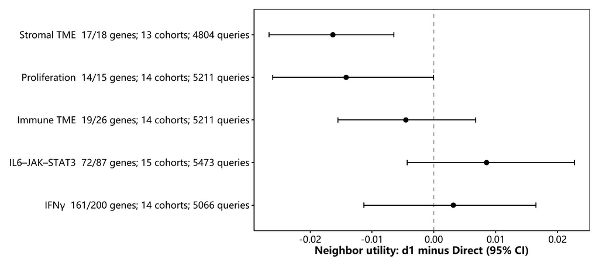

```r
hc_primary <- high_coverage$primary
hc_primary <- hc_primary[hc_primary$status == "estimable" &
  is.finite(hc_primary$estimate) & is.finite(hc_primary$ci_low) &
  is.finite(hc_primary$ci_high), , drop = FALSE]
if (nrow(hc_primary)) {
  hc_primary$label <- paste0(unname(anchor_labels[hc_primary$anchor]), "  ",
    hc_primary$common_genes, "/", hc_primary$original_genes, " genes; ",
    hc_primary$cohort_count, " cohorts; ", hc_primary$query_count, " queries")
  p_hc_primary <- ggplot2::ggplot(hc_primary,
    ggplot2::aes(x = estimate, y = label)) +
    ggplot2::geom_vline(xintercept = 0, linetype = 2, color = "grey60") +
    ggplot2::geom_errorbar(ggplot2::aes(xmin = ci_low, xmax = ci_high),
      orientation = "y", width = .12, na.rm = TRUE) + ggplot2::geom_point(size = 2) +
    ggplot2::labs(x = "Neighbor utility: d1 minus Direct (95% CI)", y = NULL) + theme_nature_readable(base_size = 10)
  jpg <- hc_save_plot(p_hc_primary, "02.02.00. high-coverage-primary", width = 9, height = 4)
  knitr::include_graphics(jpg)
}
```

```r
render_dt(high_coverage$primary, pageLength = 4)
```

|  | anchor | estimate | ci_low | ci_high | p_value | p_method | cohort_count | query_count | n_boot | valid_bootstrap | seed | status | reason | q_value | score_definition | pool | comparison | id | tier | coverage | common_genes | original_genes | selected | evidence_level | source_groups | background_genes | primary | family | effective_source_groups | … |
| --- | --- | --- | --- | --- | --- | --- | --- | --- | --- | --- | --- | --- | --- | --- | --- | --- | --- | --- | --- | --- | --- | --- | --- | --- | --- | --- | --- | --- | --- | --- |
| 16 | proliferation | -0.01418496173970476 | -0.02605374960656683 | -5.562634153044594e-05 | 0.062255859375 | exact_paired_sign_flip | 14 | 5211 | 2000 | 2000 | 23317050 | estimable | supported | 0.1556396484375 | common_rank | same_cancer | proliferation-90:common_rank:same_cancer | proliferation-90 | 0.9 | 0.9333333333333333 | 14 | 15 | True | primary_design | 3 | 4848 | True | selected_high_coverage_rank_same_cancer_anchors | 3 | … |
| 24 | immune_tme | -0.00453504030394503 | -0.01552662493510291 | 0.006750508498544716 | 0.464111328125 | exact_paired_sign_flip | 14 | 5211 | 2000 | 2000 | 23317050 | estimable | supported | 0.58013916015625 | common_rank | same_cancer | immune_tme-70:common_rank:same_cancer | immune_tme-70 | 0.7 | 0.7307692307692307 | 19 | 26 | True | primary_design | 3 | 8755 | True | selected_high_coverage_rank_same_cancer_anchors | 3 | … |
| 48 | stromal_tme | -0.01632807902121916 | -0.02661936538375939 | -0.006450895824131169 | 0.01123046875 | exact_paired_sign_flip | 13 | 4804 | 2000 | 2000 | 22901286 | estimable | supported | 0.05615234375 | common_rank | same_cancer | stromal_tme-90:common_rank:same_cancer | stromal_tme-90 | 0.9 | 0.9444444444444444 | 17 | 18 | True | primary_design | 3 | 7107 | True | selected_high_coverage_rank_same_cancer_anchors | 3 | … |
| 60 | ifn | 0.003137972559701089 | -0.011292827251697 | 0.01649835456676888 | 0.6722412109375 | exact_paired_sign_flip | 14 | 5066 | 2000 | 2000 | 23325990 | estimable | supported | 0.6722412109375 | common_rank | same_cancer | ifn-80:common_rank:same_cancer | ifn-80 | 0.8 | 0.805 | 161 | 200 | True | primary_design | 3 | 9995 | True | selected_high_coverage_rank_same_cancer_anchors | 3 | … |
| 76 | il6 | 0.008505643438120797 | -0.004300151912067039 | 0.02272630359020529 | 0.26837158203125 | exact_paired_sign_flip | 15 | 5473 | 2000 | 2000 | 23772981 | estimable | supported | 0.4472859700520834 | common_rank | same_cancer | il6-80:common_rank:same_cancer | il6-80 | 0.8 | 0.8275862068965517 | 72 | 87 | True | primary_design | 3 | 8055 | True | selected_high_coverage_rank_same_cancer_anchors | 3 | … |

**这张图最直接的发现是：在高覆盖、共同秩评分和同癌种检索条件下，d1 与 Direct 的平均差距很小。** 五项点估计为 -0.0163 至 0.0085，既有小幅负差，也有小幅正差。与广队列基线相比，这些结果说明局部匹配代价的量级依赖测量与检索条件，支持 CCS 为跨队列共同表示接受少量局部匹配代价的判断。两组分析的评分定义与验证人群不同，不能将差值缩小换算为某种机制消除了多少损失。

当前选定合同的秩同癌种结果为：Proliferation：-0.014，95% CI [-0.026, -0.000]，14 个队列 / 5211 个 query；Immune TME：-0.005，95% CI [-0.016, 0.007]，14 个队列 / 5211 个 query；Stromal TME：-0.016，95% CI [-0.027, -0.006]，13 个队列 / 4804 个 query；IFNγ：0.003，95% CI [-0.011, 0.016]，14 个队列 / 5066 个 query；IL6–JAK–STAT3：0.009，95% CI [-0.004, 0.023]，15 个队列 / 5473 个 query。表中 selected 表示按测量支持预选的档位，证据强度还取决于实际有效队列与来源支持。点估计描述差距的量级，区间描述其不确定性；区间跨零本身不构成等价证据。

五项选定主比较中 5 项可估计；其中 0 项在固定五项 BH 校正后支持 d1 接近度更高，0 项支持其更低。95% CI 是未作同时覆盖校正的 cohort bootstrap 区间，q 值来自双侧配对符号翻转检验及五项 BH 校正；区间完全位于零的一侧与 q < 0.05 不能当成同一判据。增殖的当前状态为：Proliferation：-0.014，95% CI [-0.026, -0.000]，14 个队列 / 5211 个 query。这些结果对应当前签名、背景和检索任务，不能单独证明全部生物信息的保留或损失。

主检验族包括五项 gene signature，统一进行 BH 校正；缺失或不可估计项也计入五项分母。每项 q 值对应整个检验族的校正结果，应与该项效应和区间一起解读。

图中仅展示效应及 95% CI 均可估计的 gene signature。本次所有预设锚点均满足绘图条件。 完整状态与资格保留在表中，省略不代表零效应。

### 5.3 全部覆盖率与评分／候选池对照

```
## Converting page 1 to D:/cache/ccs/_ablation-03/logs/report-previews/02.02.00-biology-20261008205659/02.02.00. high-coverage-tiers.jpg... done!
```

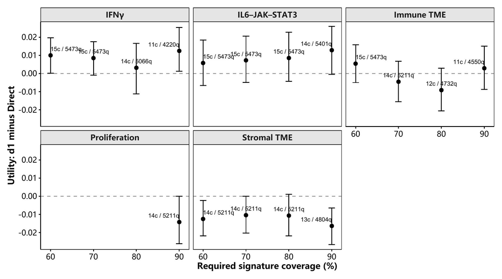

```r
hc_tiers <- high_coverage$grid[high_coverage$grid$score_definition == "common_rank" &
  high_coverage$grid$pool == "same_cancer", ]
hc_tiers <- hc_tiers[hc_tiers$status == "estimable" &
  is.finite(hc_tiers$estimate) & is.finite(hc_tiers$ci_low) &
  is.finite(hc_tiers$ci_high), , drop = FALSE]
hc_tiers$label_hjust <- ifelse(hc_tiers$tier == min(high_coverage$config$coverage_tiers), 0,
  ifelse(hc_tiers$tier == max(high_coverage$config$coverage_tiers), 1, .5))
if (nrow(hc_tiers)) {
  p_hc_tiers <- ggplot2::ggplot(hc_tiers, ggplot2::aes(x = 100 * tier, y = estimate)) +
    ggplot2::geom_hline(yintercept = 0, linetype = 2, color = "grey60") +
    ggplot2::geom_errorbar(ggplot2::aes(ymin = ci_low, ymax = ci_high), width = 1.5, na.rm = TRUE) +
    ggplot2::geom_point(size = 2, na.rm = TRUE) +
    ggplot2::geom_text(ggplot2::aes(label = paste0(cohort_count, "c / ", query_count, "q"),
      hjust = label_hjust),
      vjust = -1, size = 2.7, na.rm = TRUE) +
    ggplot2::facet_wrap(~anchor, labeller = ggplot2::as_labeller(anchor_labels)) +
    ggplot2::scale_x_continuous(breaks = 100 * high_coverage$config$coverage_tiers) +
    ggplot2::labs(x = "Required signature coverage (%)", y = "Utility: d1 minus Direct") + theme_nature_readable(base_size = 10)
  jpg <- hc_save_plot(p_hc_tiers, "02.02.00. high-coverage-tiers", width = 9, height = 5)
  knitr::include_graphics(jpg)
}
```

```r
htmltools::tagList(render_dt(hc_tables$grid, pageLength = 16),
  render_dt(high_coverage$changes, pageLength = 8))
```

|  | anchor | estimate | ci_low | ci_high | p_value | p_method | cohort_count | query_count | n_boot | valid_bootstrap | seed | status | reason | q_value | score_definition | pool | comparison | id | tier | coverage | common_genes | original_genes | selected | evidence_level | source_groups | background_genes | primary | BH_family |
| --- | --- | --- | --- | --- | --- | --- | --- | --- | --- | --- | --- | --- | --- | --- | --- | --- | --- | --- | --- | --- | --- | --- | --- | --- | --- | --- | --- | --- |
| 1 | proliferation | -0.03883789408742254 | -0.06119873624755079 | -0.01379347820644804 | 0.0073394775390625 | exact_paired_sign_flip | 17 | 5701 | 2000 | 2000 | 24726539 | estimable | supported | 0.0073394775390625 | common_raw | all | proliferation-60:common_raw:all | proliferation-60 | 0.6 | 0.6666666666666666 | 10 | 15 | False | high_coverage_sensitivity | 3 | 2677 | False | coverage:0.6:common_raw:all:5_anchors |
| 2 | proliferation | -0.04540315777582925 | -0.06580168598679544 | -0.02800498464664201 | 6.103515625e-05 | exact_paired_sign_flip | 17 | 5701 | 2000 | 2000 | 24726539 | estimable | supported | 0.000152587890625 | common_raw | same_cancer | proliferation-60:common_raw:same_cancer | proliferation-60 | 0.6 | 0.6666666666666666 | 10 | 15 | False | high_coverage_sensitivity | 3 | 2677 | False | coverage:0.6:common_raw:same_cancer:5_anchors |
| 3 | proliferation |  |  |  |  | not_estimable | 0 | 0 | 2000 | 0 | 20276108 | not_estimable | background_below_3000_genes |  | common_rank | all | proliferation-60:common_rank:all | proliferation-60 | 0.6 | 0.6666666666666666 | 10 | 15 | False | high_coverage_sensitivity | 3 | 2677 | False | coverage:0.6:common_rank:all:5_anchors |
| 4 | proliferation |  |  |  |  | not_estimable | 0 | 0 | 2000 | 0 | 20276108 | not_estimable | background_below_3000_genes |  | common_rank | same_cancer | proliferation-60:common_rank:same_cancer | proliferation-60 | 0.6 | 0.6666666666666666 | 10 | 15 | False | high_coverage_sensitivity | 3 | 2677 | False | coverage:0.6:common_rank:same_cancer:5_anchors |
| 5 | proliferation | -0.038837813553628 | -0.06161662373733884 | -0.01340364117972771 | 0.0079345703125 | exact_paired_sign_flip | 17 | 5701 | 2000 | 2000 | 24726539 | estimable | supported | 0.0079345703125 | common_raw | all | proliferation-70:common_raw:all | proliferation-70 | 0.7 | 0.7333333333333333 | 11 | 15 | False | high_coverage_sensitivity | 3 | 2719 | False | coverage:0.7:common_raw:all:5_anchors |
| 6 | proliferation | -0.04420039612173746 | -0.06378472609591465 | -0.0276204886102861 | 6.103515625e-05 | exact_paired_sign_flip | 17 | 5701 | 2000 | 2000 | 24726539 | estimable | supported | 0.00030517578125 | common_raw | same_cancer | proliferation-70:common_raw:same_cancer | proliferation-70 | 0.7 | 0.7333333333333333 | 11 | 15 | False | high_coverage_sensitivity | 3 | 2719 | False | coverage:0.7:common_raw:same_cancer:5_anchors |
| 7 | proliferation |  |  |  |  | not_estimable | 0 | 0 | 2000 | 0 | 20276108 | not_estimable | background_below_3000_genes |  | common_rank | all | proliferation-70:common_rank:all | proliferation-70 | 0.7 | 0.7333333333333333 | 11 | 15 | False | high_coverage_sensitivity | 3 | 2719 | False | coverage:0.7:common_rank:all:5_anchors |
| 8 | proliferation |  |  |  |  | not_estimable | 0 | 0 | 2000 | 0 | 20276108 | not_estimable | background_below_3000_genes |  | common_rank | same_cancer | proliferation-70:common_rank:same_cancer | proliferation-70 | 0.7 | 0.7333333333333333 | 11 | 15 | False | high_coverage_sensitivity | 3 | 2719 | False | coverage:0.7:common_rank:same_cancer:5_anchors |
| 9 | proliferation | -0.0392480746414678 | -0.06184264616351801 | -0.0140388892234026 | 0.00732421875 | exact_paired_sign_flip | 17 | 5701 | 2000 | 2000 | 24726539 | estimable | supported | 0.00732421875 | common_raw | all | proliferation-80:common_raw:all | proliferation-80 | 0.8 | 0.8 | 12 | 15 | False | high_coverage_sensitivity | 3 | 2855 | False | coverage:0.8:common_raw:all:5_anchors |
| 10 | proliferation | -0.04487403984778437 | -0.0649629470728078 | -0.02766536335645662 | 6.103515625e-05 | exact_paired_sign_flip | 17 | 5701 | 2000 | 2000 | 24726539 | estimable | supported | 0.00030517578125 | common_raw | same_cancer | proliferation-80:common_raw:same_cancer | proliferation-80 | 0.8 | 0.8 | 12 | 15 | False | high_coverage_sensitivity | 3 | 2855 | False | coverage:0.8:common_raw:same_cancer:5_anchors |

[output cut: 70 more lines]

|  | anchor | estimate | ci_low | ci_high | p_value | p_method | cohort_count | query_count | n_boot | valid_bootstrap | seed | status | reason | q_value | id | change |
| --- | --- | --- | --- | --- | --- | --- | --- | --- | --- | --- | --- | --- | --- | --- | --- | --- |
| 1 | proliferation | -0.006565263688406714 | -0.02747031066582288 | 0.01458211499161906 |  | not_tested | 17 | 5701 | 2000 | 2000 | 24726539 | estimable | supported |  | proliferation-60 | raw_pool |
| 2 | proliferation |  |  |  |  | not_tested | 0 | 0 | 2000 | 0 | 20276108 | not_estimable | fewer_than_three_cohorts |  | proliferation-60 | rank_pool |
| 3 | proliferation |  |  |  |  | not_tested | 0 | 0 | 2000 | 0 | 20276108 | not_estimable | fewer_than_three_cohorts |  | proliferation-60 | all_score |
| 4 | proliferation |  |  |  |  | not_tested | 0 | 0 | 2000 | 0 | 20276108 | not_estimable | fewer_than_three_cohorts |  | proliferation-60 | same_score |
| 5 | proliferation | -0.005362582568109463 | -0.02752547807948142 | 0.01685548958841547 |  | not_tested | 17 | 5701 | 2000 | 2000 | 24726539 | estimable | supported |  | proliferation-70 | raw_pool |
| 6 | proliferation |  |  |  |  | not_tested | 0 | 0 | 2000 | 0 | 20276108 | not_estimable | fewer_than_three_cohorts |  | proliferation-70 | rank_pool |
| 7 | proliferation |  |  |  |  | not_tested | 0 | 0 | 2000 | 0 | 20276108 | not_estimable | fewer_than_three_cohorts |  | proliferation-70 | all_score |
| 8 | proliferation |  |  |  |  | not_tested | 0 | 0 | 2000 | 0 | 20276108 | not_estimable | fewer_than_three_cohorts |  | proliferation-70 | same_score |
| 9 | proliferation | -0.005625965206316582 | -0.02742150832518649 | 0.01577219849690867 |  | not_tested | 17 | 5701 | 2000 | 2000 | 24726539 | estimable | supported |  | proliferation-80 | raw_pool |
| 10 | proliferation |  |  |  |  | not_tested | 0 | 0 | 2000 | 0 | 20276108 | not_estimable | fewer_than_three_cohorts |  | proliferation-80 | rank_pool |

[output cut: 70 more lines]

全部预设四格和覆盖率档均保存在表中，共 80 行，其中 74 行满足区间门槛。`BH_family` 标明每行 q 值的检验族：`primary=TRUE` 的行使用五项 gene signature 各自选定档位组成的主族；其余行按对应覆盖档、评分和候选池的完整五项 gene signature 族校正，计算仍包括该档内的主比较 gene signature 和不可估计项。主表和完整表中的主比较行使用相同 q 值；不能把完整表同一覆盖档内所有显示的 q 值都当作同一个检验族。覆盖率图只展示可估计的秩同癌种结果，不为缺失结果保留分面或人数标签；各档省略项及原因见完整表。图内 c/q 是每档实际队列与配对 query 数；不同档位同时改变基因完整度和验证人群，曲线变化不能仅归因于覆盖率。原尺度与秩资格可能不同，跨格机制对比须看固定共同患者的敏感性产品，不能直接相减不同分母的总体均值。缺失结果不补作零效应。

### 5.4 信息可读取性与邻居几何

连续读取器在同一冻结 gene signature 上仅使用 reference 队列分组交叉验证，拟合特征缩放、原尺度基因标尺并选择 ridge lambda。XGBoost 只由预设 reference-CV 规则触发且两臂同时运行。外部 query 只参与最终预测评估。标准化平均绝对误差（MAE）按 reference target 标准差计量，d1−Direct 为正表示读取更差，与效用差的好坏方向相反。

```
## Converting page 1 to D:/cache/ccs/_ablation-03/logs/report-previews/02.02.00-biology-20261008205659/02.02.00. high-coverage-mechanism.jpg... done!
```

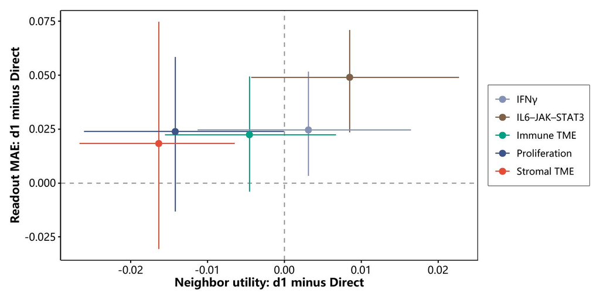

```r
hc_readout <- high_coverage$readout_inference
if (nrow(hc_readout)) {
  reader <- hc_readout[hc_readout$score_definition == "common_rank" & hc_readout$reader == "ridge", ]
  mechanism <- merge(high_coverage$primary, reader, by = "anchor", suffixes = c("_utility", "_mae"))
  mechanism <- mechanism[is.finite(mechanism$estimate_mae) & is.finite(mechanism$estimate_utility), ]
  if (nrow(mechanism) && any(is.finite(mechanism$estimate_mae) & is.finite(mechanism$estimate_utility))) {
    p_hc_map <- ggplot2::ggplot(mechanism,
      ggplot2::aes(x = estimate_utility, y = estimate_mae, color = anchor)) +
      ggplot2::geom_vline(xintercept = 0, linetype = 2, color = "grey60") +
      ggplot2::geom_hline(yintercept = 0, linetype = 2, color = "grey60") +
      ggplot2::geom_errorbar(ggplot2::aes(ymin = ci_low_mae, ymax = ci_high_mae), width = 0) +
      ggplot2::geom_errorbar(ggplot2::aes(xmin = ci_low_utility, xmax = ci_high_utility),
        orientation = "y", width = 0) + ggplot2::geom_point(size = 2.5) +
      ggplot2::scale_color_manual(values = stats::setNames(unname(nature_colors[c("navy", "green", "red", "purple", "brown")]), names(anchor_labels)), labels = anchor_labels) +
      ggplot2::labs(x = "Neighbor utility: d1 minus Direct", y = "Readout MAE: d1 minus Direct", color = NULL) + theme_nature_readable(base_size = 10)
    jpg <- hc_save_plot(p_hc_map, "02.02.00. high-coverage-mechanism", width = 8, height = 4)
    knitr::include_graphics(jpg)
  }
}
```

```r
htmltools::tagList(render_dt(high_coverage$readout_inference, pageLength = 8),
  render_dt(high_coverage$status, pageLength = 8))
```

|  | anchor | estimate | ci_low | ci_high | p_value | p_method | cohort_count | query_count | n_boot | valid_bootstrap | seed | status | reason | q_value | score_definition | reader |
| --- | --- | --- | --- | --- | --- | --- | --- | --- | --- | --- | --- | --- | --- | --- | --- | --- |
| 1 | proliferation | 0.03636069092191686 | 0.009598194879546912 | 0.06507824077274355 | 0.0225830078125 | exact_paired_sign_flip | 16 | 5439 | 2000 | 2000 | 24208154 | estimable | supported | 0.028228759765625 | common_raw | ridge |
| 2 | immune_tme | 0.07494571322047618 | 0.04660761110838949 | 0.1021291452801072 | 0.000274658203125 | exact_paired_sign_flip | 16 | 5414 | 2000 | 2000 | 24208154 | estimable | supported | 0.0006866455078125 | common_raw | ridge |
| 3 | stromal_tme | 0.02416900156031963 | 0.0006721614700655616 | 0.04446548001475755 | 0.05120849609375 | exact_paired_sign_flip | 15 | 5014 | 2000 | 2000 | 23736572 | estimable | supported | 0.05120849609375 | common_raw | ridge |
| 4 | ifn | 0.05742813637821034 | 0.01935380143311705 | 0.0946918029379597 | 0.01177978515625 | exact_paired_sign_flip | 15 | 5172 | 2000 | 2000 | 23755158 | estimable | supported | 0.01963297526041667 | common_raw | ridge |
| 5 | il6 | 0.06828271845309268 | 0.04158461499586338 | 0.0976055276647815 | 9.1552734375e-05 | exact_paired_sign_flip | 16 | 5517 | 2000 | 2000 | 24230352 | estimable | supported | 0.000457763671875 | common_raw | ridge |
| 6 | proliferation | 0.009561333982705108 | -0.04817391318994197 | 0.07219142392104407 | 0.774139404296875 | exact_paired_sign_flip | 16 | 5439 | 2000 | 2000 | 24208154 | estimable | supported | 0.774139404296875 | common_raw | xgboost |
| 7 | immune_tme | 0.03485919460060506 | -0.03302914704829682 | 0.1227012174789801 | 0.46673583984375 | exact_paired_sign_flip | 16 | 5414 | 2000 | 2000 | 24208154 | estimable | supported | 0.5834197998046875 | common_raw | xgboost |
| 8 | stromal_tme | 0.1114586080135588 | 0.05627112112451972 | 0.1752699814131516 | 0.00146484375 | exact_paired_sign_flip | 15 | 5014 | 2000 | 2000 | 23736572 | estimable | supported | 0.00732421875 | common_raw | xgboost |
| 9 | ifn | 0.06130335010676571 | 0.005646077620008024 | 0.131377083520155 | 0.0618896484375 | exact_paired_sign_flip | 15 | 5172 | 2000 | 2000 | 23755158 | estimable | supported | 0.1031494140625 | common_raw | xgboost |
| 10 | il6 | 0.05469473067282279 | 0.01743327561367855 | 0.09897300203591944 | 0.01312255859375 | exact_paired_sign_flip | 16 | 5517 | 2000 | 2000 | 24230352 | estimable | supported | 0.032806396484375 | common_raw | xgboost |

[output cut: 10 more lines]

|  | id | branch | score_definition | status | reason |
| --- | --- | --- | --- | --- | --- |
| 1 | proliferation-90 | readout | common_raw | estimable | supported |
| 2 | proliferation-90 | readout | common_rank | estimable | supported |
| 3 | immune_tme-70 | readout | common_raw | estimable | supported |
| 4 | immune_tme-70 | readout | common_rank | estimable | supported |
| 5 | stromal_tme-90 | readout | common_raw | estimable | supported |
| 6 | stromal_tme-90 | readout | common_rank | estimable | supported |
| 7 | ifn-80 | readout | common_raw | estimable | supported |
| 8 | ifn-80 | readout | common_rank | estimable | supported |
| 9 | il6-80 | readout | common_raw | estimable | supported |
| 10 | il6-80 | readout | common_rank | estimable | supported |

**这张图把“邻居找得是否接近”和“同一生物信号能否从表示中读出”放在一起，帮助辨别局部匹配代价更偏向距离规则，还是重编码后信号变得难以恢复。** 每个彩色点对应一个 gene signature，横轴使用选定高覆盖合同内、同癌种候选池下的邻居接近度差，纵轴使用同一秩目标的 ridge 读取误差差；两轴均为 d1−Direct，但好坏方向相反。

| 图中元素 | 比较什么 | 如何阅读 |
| --- | --- | --- |
| 横轴 Neighbor utility | 两种表示找到的邻居，其 gene signature 分数与当前患者有多接近 | 向右表示 d1 更接近，向左表示 Direct 更接近；是接近度的绝对差，不能读成准确率或信息损失百分比。 |
| 纵轴 Readout MAE | 从两种表示预测该 gene signature 分数的标准化平均绝对误差 | 向上表示 d1 读取更差，向下表示 d1 读取更好；单位是 reference target 标准差。 |
| 横、竖误差线 | 邻居接近度差与读取误差差各自的 95% cohort bootstrap 区间 | 分别判断两个方向的不确定性；它们不是二维联合置信区域，也不直接给出 BH 校正后的检验结论。 |

左上方意味着邻居匹配与线性读取同时变差；若两轴都有相应的不利证据，会更支持重编码后该信号变得难以恢复的解释。若点在左侧而纵坐标接近零，则更倾向于信号仍可读取、但邻居距离规则利用不足；不过读取区间跨零不能证明信息保留或两臂等价。右上方表示邻居匹配有所改善而线性读取变差，说明这两个任务可以出现不同方向；右下方则表示两项评价都偏向 d1。

当前图中，增殖、免疫和基质的点都位于左上方，但三项读取误差区间均跨零，尚不能明确区分距离利用不足与信号可恢复性下降。IFNγ 和 IL6-JAK-STAT3 位于右上方：邻居接近度点估计略有提高，横向区间均跨零；线性读取误差则增加。其中 IL6-JAK-STAT3 的读取变差在五项 BH 校正后仍有支持，IFNγ 的纵向区间虽高于零，校正检验未达到 0.05。因此，不能仅凭点落在哪个象限就宣布对应机制成立。

秩 ridge 读取器的具体结果为：Proliferation：0.024，95% CI [-0.013, 0.059]，14 个队列 / 5211 个 query；Immune TME：0.022，95% CI [-0.004, 0.049]，14 个队列 / 5211 个 query；Stromal TME：0.018，95% CI [-0.031, 0.075]，13 个队列 / 4804 个 query；IFNγ：0.025，95% CI [0.003, 0.052]，14 个队列 / 5066 个 query；IL6–JAK–STAT3：0.049，95% CI [0.024, 0.071]，15 个队列 / 5473 个 query。这些比较沿用各 gene signature 的高覆盖共同基因与评分背景；同癌种限制用于横轴的邻居检索，纵轴则是 reference-only 训练、外部 query 评估的连续预测任务。两项任务的条件与有效队列／患者数须一起核对，各 signature 也不一定对应完全相同的验证人群。

**邻居匹配与信息读取应分别评价，不能仅凭邻居表现判断信息是否保留。** ridge 读取变差既可能来自信息被弱化，也可能来自信息在 d1 中变得更难通过线性模型读出；本图提供机制线索，尚不足以证明信息已经丢失。这里的 gene signature 与输入同源，仍不能替代独立病理或临床结局验证。完整单臂 MAE、相关及 reference 均值基准保存在 high-coverage-readout_metrics.csv。

预设非线性读取器也须一起判断。秩 XGBoost 分支中，存在 BH 校正后 MAE 增加的锚点：Immune TME：0.037，95% CI [0.015, 0.059]，14 个队列 / 5211 个 query，q = 0.0378。同癌种近邻效用差接近零，仍不能代替连续目标的可恢复性验证；读取器的不利差异也只对应当前 gene signature、训练规则和冻结参考集，不等同于全部生物信息消失。未触发 XGBoost 或评分资格不足的空格均标为未运行或不可估计。

### 5.5 队列、来源与共同人群敏感性

**本节检查高覆盖主结果的适用范围：不同队列是否同向，删除某个队列或来源后是否改变判断，以及固定共同队列或调整检索规则后差异是否仍然存在。** 当前基质的局部匹配负差在这些比较中最稳定，增殖以负向为主；免疫、IFNγ 与 IL6-JAK-STAT3 的队列方向更混合。来源组成和有效人群仍限制推广，因此下面分别判断方向、量级与不确定性。

#### 5.5.1 队列差异：平均结果适用于哪些队列

图中每列是一个 gene signature，每行是一个外部 query 队列。黑点为该队列内患者配对接近度差的均值：d1−Direct 大于零表示 d1 的邻居分数更接近当前患者，小于零表示 Direct 更接近。所有分面使用共同横轴及对齐的队列纵轴；空白是缺少合格结果，不能补作零差异。图中没有队列内区间，黑点本身只描述方向和量级，不表示该队列的差异已经通过统计检验。

```
## Converting page 1 to D:/cache/ccs/_ablation-03/logs/report-previews/02.02.00-biology-20261008205659/02.02.00. high-coverage-cohorts.jpg... done!
```

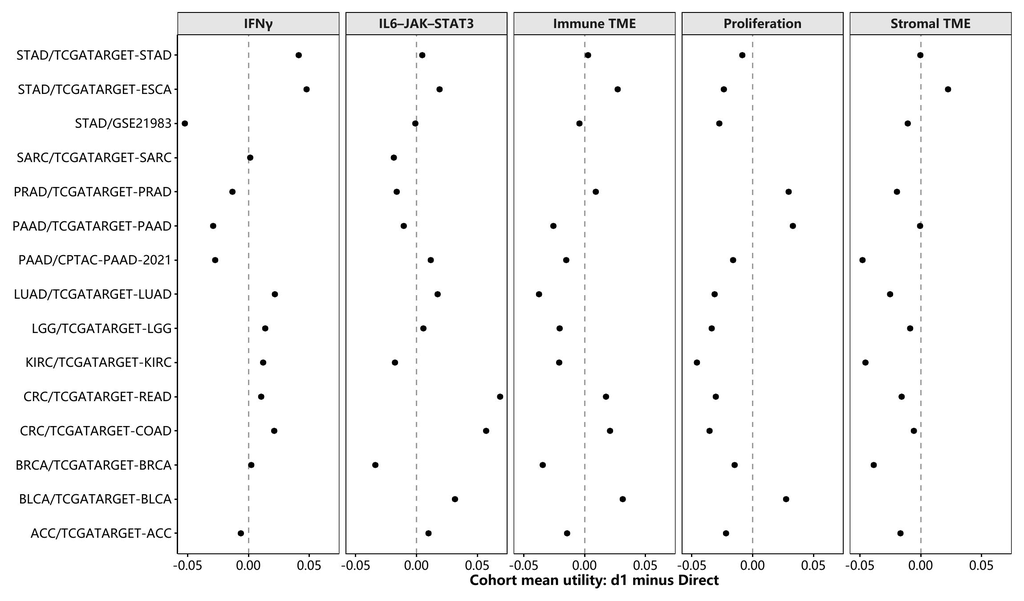

```r
hc_cohort <- high_coverage$cohort[high_coverage$cohort$score_definition == "common_rank" &
  high_coverage$cohort$pool == "same_cancer" & high_coverage$cohort$id %in%
    high_coverage$frontier$id[high_coverage$frontier$selected], ]
if (nrow(hc_cohort)) {
  hc_cohort$cohort <- factor(hc_cohort$cohort,
    levels = sort(unique(hc_cohort$cohort)))
  p_hc_cohort <- ggplot2::ggplot(hc_cohort, ggplot2::aes(x = value, y = cohort)) +
    ggplot2::geom_vline(xintercept = 0, linetype = 2, color = "grey60") +
    ggplot2::geom_point(size = 1.7) +
    ggplot2::facet_grid(. ~ anchor, labeller = ggplot2::labeller(
      anchor = ggplot2::as_labeller(anchor_labels))) +
    ggplot2::scale_x_continuous(breaks = scales::breaks_pretty(n = 3),
      labels = scales::label_number(accuracy = .01)) +
    ggplot2::labs(x = "Cohort mean utility: d1 minus Direct", y = NULL) + theme_nature_readable(base_size = 10)
  hc_height <- max(5, .35 * nlevels(hc_cohort$cohort) + 1.5)
  jpg <- hc_save_plot(p_hc_cohort, "02.02.00. high-coverage-cohorts", width = 11.5, height = hc_height)
  knitr::include_graphics(jpg)
}
```

```r
hc_direction <- do.call(rbind, lapply(names(anchor_labels), function(anchor) {
  x <- hc_cohort[hc_cohort$anchor == anchor & hc_cohort$eligible_inference &
    is.finite(hc_cohort$value), ]
  data.frame(signature = unname(anchor_labels[anchor]),
    effective_cohorts = nrow(x), negative_cohorts = sum(x$value < 0),
    positive_cohorts = sum(x$value > 0), zero_cohorts = sum(x$value == 0),
    cohort_equal_mean = if (nrow(x)) mean(x$value) else NA_real_)
}))
names(hc_direction) <- c("Gene signature", "有效队列数", "负向队列数", "正向队列数",
  "零差异队列数", "队列等权平均差")
render_dt(hc_direction, pageLength = 5)
```

|  | Gene signature | 有效队列数 | 负向队列数 | 正向队列数 | 零差异队列数 | 队列等权平均差 |
| --- | --- | --- | --- | --- | --- | --- |
| 1 | Proliferation | 14 | 11 | 3 | 0 | -0.01418496173970476 |
| 2 | Immune TME | 14 | 8 | 6 | 0 | -0.00453504030394503 |
| 3 | Stromal TME | 13 | 12 | 1 | 0 | -0.01632807902121916 |
| 4 | IFNγ | 14 | 5 | 9 | 0 | 0.003137972559701089 |
| 5 | IL6–JAK–STAT3 | 15 | 6 | 9 | 0 | 0.008505643438120797 |

**基质和增殖的总体负差出现在多个队列中。** 基质为 12／13 个队列负向，增殖为 11／14 个队列负向。增殖仍有正向队列，例如 PAAD 的 TCGA 队列偏正、CPTAC 队列偏负；同癌种的不同队列可以有不同结果，癌种标签不足以解释全部差异。

免疫、IFNγ 和 IL6-JAK-STAT3 同时存在正向与负向队列。它们的总体均值较接近零，可能包含不同队列效应的抵消，不能解释为每个队列均无变化，也不能据此证明等价。图中的极端队列用于提出后续检查问题；来源、测量条件与患者组成可能共同影响结果，本图不能单独识别原因。

#### 5.5.2 留一队列与来源：平均方向是否依赖少数输入

留一分析每次删除一个 query 队列，或删除来自同一数据库来源的全部 query 队列，再对剩余队列均值等权汇总并重算区间。它检查当前平均差对队列组合的依赖，没有重新训练 bank、重估评分合同或重新检索剩余患者的邻居。表中的 `unit` 区分 cohort 与 source，`omitted` 是被删除的对象；应同时看 `estimate`、区间及剩余 `cohort_count`。

下图逐项画出删除一个队列后的平均差及条件区间。蓝色虚线是该 signature 的主比较点估计，灰色虚线是零；沿同一列看，各次删除后的结果是否仍处于零线同一侧、是否偏离主比较。纵轴列出被删除的队列，空白位置表示该 signature 没有对应的留一结果。

```r
hc_loo <- high_coverage$leave_one[high_coverage$leave_one$unit == "cohort" &
  is.finite(high_coverage$leave_one$estimate), ]
hc_loo$anchor <- factor(hc_loo$anchor, levels = names(anchor_labels))
hc_loo$omitted <- factor(hc_loo$omitted, levels = rev(sort(unique(hc_loo$omitted))))
hc_loo$with_interval <- is.finite(hc_loo$ci_low) & is.finite(hc_loo$ci_high)
hc_loo_baseline <- high_coverage$primary
hc_loo_baseline$anchor <- factor(hc_loo_baseline$anchor, levels = names(anchor_labels))
p_hc_loo <- ggplot2::ggplot(hc_loo, ggplot2::aes(x = estimate, y = omitted)) +
  ggplot2::geom_vline(xintercept = 0, linetype = 2, color = "grey65") +
  ggplot2::geom_vline(data = hc_loo_baseline,
    ggplot2::aes(xintercept = estimate), linetype = 2, color = nature_colors[["navy"]]) +
  ggplot2::geom_errorbar(data = hc_loo[hc_loo$with_interval, ],
    ggplot2::aes(xmin = ci_low, xmax = ci_high), orientation = "y", width = .12,
    color = nature_colors[["navy"]], linewidth = .4) +
  ggplot2::geom_point(ggplot2::aes(shape = with_interval),
    color = nature_colors[["navy"]], size = 2) +
  ggplot2::scale_shape_manual(values = c(`TRUE` = 16, `FALSE` = 1),
    breaks = c(TRUE, FALSE), labels = c("With interval", "Point only")) +
  ggplot2::facet_grid(. ~ anchor,
    labeller = ggplot2::labeller(anchor = ggplot2::as_labeller(anchor_labels))) +
  ggplot2::scale_x_continuous(breaks = scales::breaks_pretty(n = 3),
    labels = scales::label_number(accuracy = .01)) +
  ggplot2::labs(x = "Mean neighbor utility after omission: d1 minus Direct",
    y = "Omitted query cohort", shape = NULL) +
  theme_nature_readable(base_size = params$sensitivity_plot_base_size,
    legend_position = "bottom")
hc_loo_jpg <- hc_save_plot(p_hc_loo, "02.02.00. high-coverage-leave-one-cohorts",
  width = params$sensitivity_plot_width,
  height = max(5, .32 * nlevels(hc_loo$omitted) + 1.8))
```

```
## Converting page 1 to D:/cache/ccs/_ablation-03/logs/report-previews/02.02.00-biology-20261008205659/02.02.00. high-coverage-leave-one-cohorts.jpg... done!
```

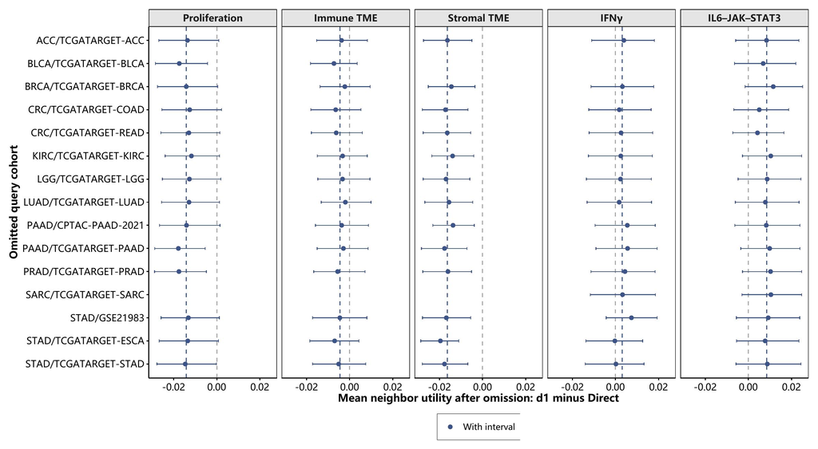

```r
knitr::include_graphics(hc_loo_jpg)
```

```r
render_dt(high_coverage$leave_one, pageLength = 8)
```

|  | anchor | estimate | ci_low | ci_high | p_value | p_method | cohort_count | query_count | n_boot | valid_bootstrap | seed | status | reason | q_value | unit | omitted | comparison |
| --- | --- | --- | --- | --- | --- | --- | --- | --- | --- | --- | --- | --- | --- | --- | --- | --- | --- |
| 1 | proliferation | -0.01359331580766971 | -0.0268338449853139 | 0.0009250857350876597 |  | not_tested | 13 | 5134 | 2000 | 2000 | 22939901 | estimable | supported |  | cohort | ACC/TCGATARGET-ACC | proliferation-90 |
| 2 | proliferation | -0.01738827205060421 | -0.02847185222889912 | -0.004288244552858179 |  | not_tested | 13 | 4804 | 2000 | 2000 | 22901286 | estimable | supported |  | cohort | BLCA/TCGATARGET-BLCA | proliferation-90 |
| 3 | proliferation | -0.01413749775028192 | -0.02747227955153918 | 0.000469710424872402 |  | not_tested | 13 | 4117 | 2000 | 2000 | 22900734 | estimable | supported |  | cohort | BRCA/TCGATARGET-BRCA | proliferation-90 |
| 4 | proliferation | -0.01255332533662867 | -0.0254325010714988 | 0.002163761317184397 |  | not_tested | 13 | 4921 | 2000 | 2000 | 22919622 | estimable | supported |  | cohort | CRC/TCGATARGET-COAD | proliferation-90 |
| 5 | proliferation | -0.01294779971526211 | -0.02588413623378787 | 0.001453814642527004 |  | not_tested | 13 | 5118 | 2000 | 2000 | 22919162 | estimable | supported |  | cohort | CRC/TCGATARGET-READ | proliferation-90 |
| 6 | proliferation | -0.01175511560824379 | -0.02393372274824351 | 0.001210541481141114 |  | not_tested | 13 | 4479 | 2000 | 2000 | 22897357 | estimable | supported |  | cohort | KIRC/TCGATARGET-KIRC | proliferation-90 |
| 7 | proliferation | -0.01268877222057297 | -0.02520860754361198 | 0.001900312363680638 |  | not_tested | 13 | 4688 | 2000 | 2000 | 22938099 | estimable | supported |  | cohort | LGG/TCGATARGET-LGG | proliferation-90 |
| 8 | proliferation | -0.01287373414698821 | -0.0255634448008544 | 0.001226111133554172 |  | not_tested | 13 | 4699 | 2000 | 2000 | 22897927 | estimable | supported |  | cohort | LUAD/TCGATARGET-LUAD | proliferation-90 |
| 9 | proliferation | -0.01403953961684395 | -0.02657941107358667 | 0.001487899734507406 |  | not_tested | 13 | 5071 | 2000 | 2000 | 22927133 | estimable | supported |  | cohort | PAAD/CPTAC-PAAD-2021 | proliferation-90 |
| 10 | proliferation | -0.0178152816726345 | -0.02873641440254553 | -0.005405504373040657 |  | not_tested | 13 | 5032 | 2000 | 2000 | 22900434 | estimable | supported |  | cohort | PAAD/TCGATARGET-PAAD | proliferation-90 |

[output cut: 75 more lines]

逐一删除队列后，基质的 13 次结果均为负，点估计范围为 -0.020 至 -0.014，各次 95% 区间均低于零。增殖也始终为负，范围为 -0.018 至 -0.012，但多数区间跨零。免疫的平均点估计保持负向、IL6 保持正向，区间均跨零；IFNγ 在部分删除条件下会改变符号。**方向保持与区间支持是两件事：基质的负向模式最稳定，其余 signature 的证据强度不能仅按符号判断。** 留一结果彼此高度重叠，也不构成多次独立验证；本表不附 p/q，不能把点式区间当作多重校正后的发现。

来源汇总表用于解释上述结果的组成。`cohort_equal_mean` 是该来源内部的队列等权平均差，不是来源等权的总体效应；数据库来源也不等于测序平台、患者独立性或技术批次。

来源图把两个问题上下对照：上排显示每个来源内部的队列等权均值，下排显示删除该来源后的剩余队列均值及可用区间。实心点表示有区间，空心点仅表示描述性均值；上排没有来源层推断区间，下排删除 UCSC Xena 后也只有描述性点。两排都沿用同一横轴，便于看出 IFNγ 的来源方向差异及来源删除后的变化。

```r
hc_source_means <- high_coverage$source_summary
hc_source_loo <- high_coverage$leave_one[high_coverage$leave_one$unit == "source", ]
hc_source_plot <- rbind(
  data.frame(anchor = hc_source_means$anchor, source = hc_source_means$source_system,
    estimate = hc_source_means$cohort_equal_mean, ci_low = NA_real_, ci_high = NA_real_,
    cohort_count = hc_source_means$cohort_count, scope = "Within-source mean"),
  data.frame(anchor = hc_source_loo$anchor, source = hc_source_loo$omitted,
    estimate = hc_source_loo$estimate, ci_low = hc_source_loo$ci_low,
    ci_high = hc_source_loo$ci_high, cohort_count = hc_source_loo$cohort_count,
    scope = "After omitting source"))
hc_source_plot <- hc_source_plot[is.finite(hc_source_plot$estimate), ]
hc_source_plot$anchor <- factor(hc_source_plot$anchor, levels = names(anchor_labels))
hc_source_plot$source <- factor(hc_source_plot$source,
  levels = rev(sort(unique(hc_source_plot$source))))
hc_source_plot$scope <- factor(hc_source_plot$scope,
  levels = c("Within-source mean", "After omitting source"))
hc_source_plot$with_interval <- is.finite(hc_source_plot$ci_low) &
  is.finite(hc_source_plot$ci_high)
p_hc_source <- ggplot2::ggplot(hc_source_plot,
  ggplot2::aes(x = estimate, y = source)) +
  ggplot2::geom_vline(xintercept = 0, linetype = 2, color = "grey65") +
  ggplot2::geom_errorbar(data = hc_source_plot[hc_source_plot$with_interval, ],
    ggplot2::aes(xmin = ci_low, xmax = ci_high), orientation = "y", width = .12,
    color = nature_colors[["navy"]], linewidth = .45) +
  ggplot2::geom_point(ggplot2::aes(shape = with_interval),
    color = nature_colors[["navy"]], size = 2.4) +
  ggplot2::scale_shape_manual(values = c(`TRUE` = 16, `FALSE` = 1),
    breaks = c(TRUE, FALSE), labels = c("With interval", "Descriptive only")) +
  ggplot2::facet_grid(scope ~ anchor,
    labeller = ggplot2::labeller(anchor = ggplot2::as_labeller(anchor_labels))) +
  ggplot2::scale_x_continuous(breaks = scales::breaks_pretty(n = 3),
    labels = scales::label_number(accuracy = .01)) +
  ggplot2::labs(x = "Cohort-equal neighbor utility: d1 minus Direct",
    y = "Query source system", shape = NULL) +
  theme_nature_readable(base_size = params$sensitivity_plot_base_size,
    legend_position = "bottom")
hc_source_jpg <- hc_save_plot(p_hc_source, "02.02.00. high-coverage-source-sensitivity",
  width = params$sensitivity_plot_width, height = 5.2)
```

```
## Converting page 1 to D:/cache/ccs/_ablation-03/logs/report-previews/02.02.00-biology-20261008205659/02.02.00. high-coverage-source-sensitivity.jpg... done!
```

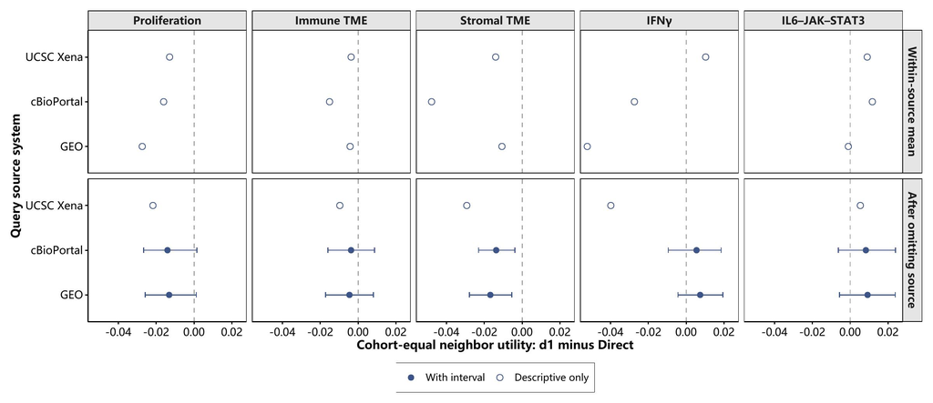

```r
knitr::include_graphics(hc_source_jpg)
```

```r
render_dt(high_coverage$source_summary, pageLength = 8)
```

|  | id | anchor | source_system | cohort_count | query_count | cohort_equal_mean | negative_cohorts | positive_cohorts | known_source | scope |
| --- | --- | --- | --- | --- | --- | --- | --- | --- | --- | --- |
| 1 | proliferation-90 | proliferation | cBioPortal | 1 | 140 | -0.0160754493368952 | 1 | 0 | True | descriptive_source_direction_not_independent_source_inference |
| 2 | proliferation-90 | proliferation | GEO | 1 | 72 | -0.02737792925326601 | 1 | 0 | True | descriptive_source_direction_not_independent_source_inference |
| 3 | proliferation-90 | proliferation | UCSC Xena | 12 | 4999 | -0.01292800714714211 | 9 | 3 | True | descriptive_source_direction_not_independent_source_inference |
| 4 | immune_tme-70 | immune_tme | cBioPortal | 1 | 140 | -0.01507359586881044 | 1 | 0 | True | descriptive_source_direction_not_independent_source_inference |
| 5 | immune_tme-70 | immune_tme | GEO | 1 | 72 | -0.004226382686468815 | 1 | 0 | True | descriptive_source_direction_not_independent_source_inference |
| 6 | immune_tme-70 | immune_tme | UCSC Xena | 12 | 4999 | -0.003682548808329264 | 6 | 6 | True | descriptive_source_direction_not_independent_source_inference |
| 7 | stromal_tme-90 | stromal_tme | cBioPortal | 1 | 140 | -0.04781281765542043 | 1 | 0 | True | descriptive_source_direction_not_independent_source_inference |
| 8 | stromal_tme-90 | stromal_tme | GEO | 1 | 72 | -0.01066230656847036 | 1 | 0 | True | descriptive_source_direction_not_independent_source_inference |
| 9 | stromal_tme-90 | stromal_tme | UCSC Xena | 11 | 4592 | -0.01398090027745076 | 10 | 1 | True | descriptive_source_direction_not_independent_source_inference |
| 10 | ifn-80 | ifn | cBioPortal | 1 | 140 | -0.02733745262685477 | 1 | 0 | True | descriptive_source_direction_not_independent_source_inference |

[output cut: 5 more lines]

当前各 signature 的有效队列主要来自 UCSC Xena（11–13 个），GEO 与 cBioPortal 各贡献一个队列。基质在三个来源内的均值均为负；删除 GEO 或 cBioPortal 后，剩余平均差的区间仍低于零。IFNγ 则在 UCSC Xena 内偏正、另两个来源偏负，去掉 UCSC Xena 后平均方向转负，提示其总体正向趋势对来源构成较敏感。

**删除 UCSC Xena 后，各 signature 都只剩两个有效队列，低于区间门槛。** 表中保留的点估计只能描述这些剩余队列，NA 区间不能解释为差异消失。当前来源留一分析说明来源构成值得关注，尚不能支持向全新来源的随机抽样推广，也不能把来源间方向差异归因于 batch effect。

#### 5.5.3 共同队列：各 signature 的验证人群不同是否改变结论

五项 signature 冻结测量合同的队列交集有 14 个；进一步要求五个秩同癌种比较都通过实际评分与人数门槛，得到 C_core 的 13 个共同队列。此处保持各 signature 原有基因、评分与测量合同，只在相同队列集合上重新汇总。患者仍按各 signature 的完整值资格配对，因此 C_core 的定义保证共同队列，不能仅凭人数相同认定五项使用了完全相同的患者 ID。

森林图把原主比较与 C_core 汇总并排放到每个 signature 的同一行。两组点的左右位置表示平均差，水平线为各自 95% 条件区间；颜色区分验证队列集合。它直观检查固定共同队列后方向和量级是否改变，两个区间的重叠程度不能代替两种人群结果之差的配对检验。

```r
hc_core_columns <- c("anchor", "estimate", "ci_low", "ci_high", "cohort_count", "query_count")
hc_core_plot <- rbind(
  transform(high_coverage$primary[, hc_core_columns], population = "Primary cohorts"),
  transform(high_coverage$core[, hc_core_columns], population = "Common cohorts"))
hc_core_plot <- hc_core_plot[is.finite(hc_core_plot$estimate), ]
hc_core_plot$anchor <- factor(hc_core_plot$anchor, levels = rev(names(anchor_labels)))
hc_core_plot$population <- factor(hc_core_plot$population,
  levels = c("Primary cohorts", "Common cohorts"))
hc_core_plot$with_interval <- is.finite(hc_core_plot$ci_low) & is.finite(hc_core_plot$ci_high)
hc_core_dodge <- ggplot2::position_dodge(width = .5)
p_hc_core <- ggplot2::ggplot(hc_core_plot,
  ggplot2::aes(x = anchor, y = estimate, color = population, shape = population)) +
  ggplot2::geom_hline(yintercept = 0, linetype = 2, color = "grey65") +
  ggplot2::geom_errorbar(data = hc_core_plot[hc_core_plot$with_interval, ],
    ggplot2::aes(ymin = ci_low, ymax = ci_high), position = hc_core_dodge,
    width = .12, linewidth = .55) +
  ggplot2::geom_point(position = hc_core_dodge, size = 2.8) +
  ggplot2::scale_x_discrete(labels = anchor_labels) +
  ggplot2::scale_y_continuous(breaks = scales::breaks_pretty(n = 4),
    labels = scales::label_number(accuracy = .01)) +
  ggplot2::scale_color_manual(values = c("Primary cohorts" = nature_colors[["navy"]],
    "Common cohorts" = nature_colors[["green"]])) +
  ggplot2::scale_shape_manual(values = c("Primary cohorts" = 16, "Common cohorts" = 17)) +
  ggplot2::coord_flip() +
  ggplot2::labs(x = NULL, y = "Cohort-equal neighbor utility: d1 minus Direct",
    color = NULL, shape = NULL) +
  theme_nature_readable(base_size = params$sensitivity_plot_base_size,
    legend_position = "bottom")
hc_core_jpg <- hc_save_plot(p_hc_core, "02.02.00. high-coverage-common-cohorts",
  width = 9, height = 4.4)
```

```
## Converting page 1 to D:/cache/ccs/_ablation-03/logs/report-previews/02.02.00-biology-20261008205659/02.02.00. high-coverage-common-cohorts.jpg... done!
```

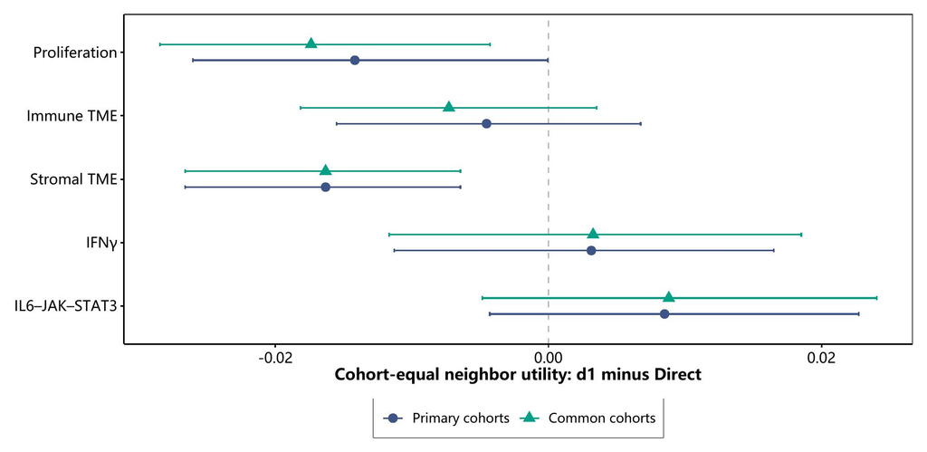

```r
knitr::include_graphics(hc_core_jpg)
```

```r
render_dt(high_coverage$core, pageLength = 5)
```

|  | anchor | estimate | ci_low | ci_high | p_value | p_method | cohort_count | query_count | n_boot | valid_bootstrap | seed | status | reason | q_value | comparison |
| --- | --- | --- | --- | --- | --- | --- | --- | --- | --- | --- | --- | --- | --- | --- | --- |
| 1 | proliferation | -0.01738827205060421 | -0.02847185222889912 | -0.004288244552858179 |  | not_tested | 13 | 4804 | 2000 | 2000 | 22901286 | estimable | supported |  | C_core_fixed_contract |
| 2 | immune_tme | -0.007293666055193725 | -0.0181771019128961 | 0.003528833682561381 |  | not_tested | 13 | 4804 | 2000 | 2000 | 22901286 | estimable | supported |  | C_core_fixed_contract |
| 3 | stromal_tme | -0.01632807902121916 | -0.02661936538375939 | -0.006450895824131169 |  | not_tested | 13 | 4804 | 2000 | 2000 | 22901286 | estimable | supported |  | C_core_fixed_contract |
| 4 | ifn | 0.003268951144378964 | -0.01168396314766417 | 0.01852735084991199 |  | not_tested | 13 | 4804 | 2000 | 2000 | 22901286 | estimable | supported |  | C_core_fixed_contract |
| 5 | il6 | 0.008817847902462456 | -0.004852548474636603 | 0.02405922176830631 |  | not_tested | 13 | 4804 | 2000 | 2000 | 22901286 | estimable | supported |  | C_core_fixed_contract |

共同队列中的结果为：Proliferation：-0.017，95% CI [-0.028, -0.004]，13 个队列 / 4804 个 query；Immune TME：-0.007，95% CI [-0.018, 0.004]，13 个队列 / 4804 个 query；Stromal TME：-0.016，95% CI [-0.027, -0.006]，13 个队列 / 4804 个 query；IFNγ：0.003，95% CI [-0.012, 0.019]，13 个队列 / 4804 个 query；IL6–JAK–STAT3：0.009，95% CI [-0.005, 0.024]，13 个队列 / 4804 个 query。各项点估计方向与主比较一致：增殖、免疫和基质为负，IFNγ 与 IL6 为正。增殖和基质的条件区间低于零，其余跨零；这些是敏感性结果，不附 p/q，不能替代主比较的五项 BH 校正结论。

**固定共同队列后，主要方向没有被不同 signature 的队列纳入差异推翻。** 这减弱了“总体方向完全由队列集合不同造成”的解释；仍不能排除队列内部患者组成或测量差异。共同队列分析也缩小了验证范围，回答的是这一人群中的一致性，不代表全部外部队列。

#### 5.5.4 距离与技术限制：改变检索规则能否缓解局部代价

下表的 `estimate` 与前面的主效应含义不同：它是同一患者上 **修改规则后的 d1−Direct，减去基线规则下的 d1−Direct**。每次先匹配两种规则都有完整结果的患者，再在队列内平均、队列间等权。正值表示修改规则使相对接近度差向有利于 d1 的方向移动，负值表示向不利方向移动；正值本身不保证修改后的 d1 已超过 Direct。

`module_unscaled` 取消 d1 概率列的标准差缩放、保留模块权重；`tissue_balanced` 按组织调整模块权重，二者只改变 d1 的距离规则，Direct 沿用基线。`assay_type`、`source_system` 与 `platform_id` 则让两臂都在同癌种基础上，进一步要求 reference 邻居与 query 的已知检测类型、数据库来源或平台标签相同。技术限制会缩小候选池与有效患者集合，必须在各自共同患者上解读，不能把表中差中差直接加到全人群主效应上。

差中差图按修改规则分面：点在零线右侧表示相对接近度向有利于 d1 的方向移动，左侧表示向不利方向移动。实心点带区间，空心点仅描述队列不足的结果；相同来源条件下的免疫和基质属于后者。平台条件没有合格配对，效应图不补零或画点，其资格在后面的支持图中完整保留。

```r
hc_change_labels <- c(module_unscaled = "No column SD scaling",
  tissue_balanced = "Tissue-balanced distance", assay_type = "Same assay type",
  source_system = "Same source system", platform_id = "Same platform")
hc_sensitivity_plot <- high_coverage$sensitivity[
  is.finite(high_coverage$sensitivity$estimate), ]
hc_sensitivity_plot$anchor <- factor(hc_sensitivity_plot$anchor,
  levels = rev(names(anchor_labels)))
hc_sensitivity_plot$change <- factor(hc_sensitivity_plot$change,
  levels = names(hc_change_labels))
hc_sensitivity_plot$with_interval <- is.finite(hc_sensitivity_plot$ci_low) &
  is.finite(hc_sensitivity_plot$ci_high)
p_hc_sensitivity <- ggplot2::ggplot(hc_sensitivity_plot,
  ggplot2::aes(x = estimate, y = anchor)) +
  ggplot2::geom_vline(xintercept = 0, linetype = 2, color = "grey65") +
  ggplot2::geom_errorbar(data = hc_sensitivity_plot[hc_sensitivity_plot$with_interval, ],
    ggplot2::aes(xmin = ci_low, xmax = ci_high), orientation = "y", width = .12,
    color = nature_colors[["navy"]], linewidth = .55) +
  ggplot2::geom_point(ggplot2::aes(shape = with_interval),
    color = nature_colors[["navy"]], size = 2.5) +
  ggplot2::scale_shape_manual(values = c(`TRUE` = 16, `FALSE` = 1),
    breaks = c(TRUE, FALSE), labels = c("With interval", "Point only")) +
  ggplot2::scale_y_discrete(labels = anchor_labels) +
  ggplot2::scale_x_continuous(breaks = scales::breaks_pretty(n = 3),
    labels = scales::label_number(accuracy = .01)) +
  ggplot2::facet_wrap(~ change, ncol = 2,
    labeller = ggplot2::as_labeller(hc_change_labels)) +
  ggplot2::labs(x = "Change in utility difference: modified minus baseline",
    y = NULL, shape = NULL) +
  theme_nature_readable(base_size = params$sensitivity_plot_base_size,
    legend_position = "bottom")
hc_sensitivity_jpg <- hc_save_plot(p_hc_sensitivity,
  "02.02.00. high-coverage-retrieval-sensitivity", width = 10, height = 5.6)
```

```
## Converting page 1 to D:/cache/ccs/_ablation-03/logs/report-previews/02.02.00-biology-20261008205659/02.02.00. high-coverage-retrieval-sensitivity.jpg... done!
```

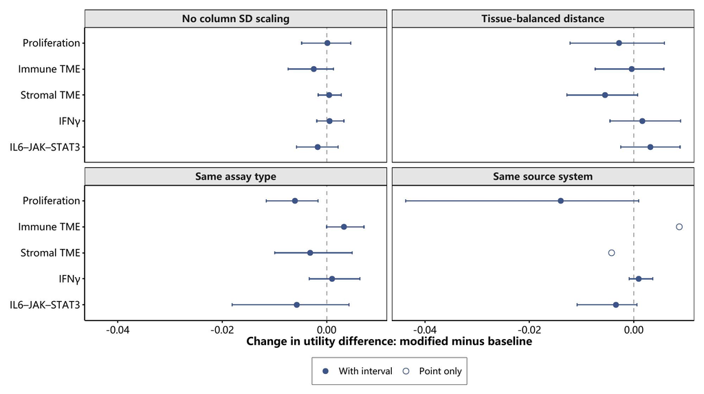

```r
knitr::include_graphics(hc_sensitivity_jpg)
```

```r
render_dt(high_coverage$sensitivity, pageLength = 10)
```

|  | anchor | estimate | ci_low | ci_high | p_value | p_method | cohort_count | query_count | n_boot | valid_bootstrap | seed | status | reason | q_value | change |
| --- | --- | --- | --- | --- | --- | --- | --- | --- | --- | --- | --- | --- | --- | --- | --- |
| 1 | proliferation | 0.0001294046113167725 | -0.004786223347121183 | 0.004590734271525121 |  | not_tested | 14 | 5211 | 2000 | 2000 | 23317050 | estimable | supported |  | module_unscaled |
| 2 | proliferation | -0.002842799698153988 | -0.01223046290103873 | 0.005833696774971326 |  | not_tested | 14 | 5211 | 2000 | 2000 | 23317050 | estimable | supported |  | tissue_balanced |
| 3 | proliferation | -0.006076529157276556 | -0.01158838653296807 | -0.001666726711032748 |  | not_tested | 9 | 3619 | 2000 | 2000 | 21551398 | estimable | supported |  | assay_type |
| 4 | proliferation | -0.01399658917251126 | -0.04367546303047706 | 0.0009405551977659942 |  | not_tested | 3 | 1345 | 2000 | 2000 | 20442112 | estimable | supported |  | source_system |
| 5 | proliferation |  |  |  |  | not_tested | 0 | 0 | 2000 | 0 | 20276108 | not_estimable | fewer_than_three_cohorts |  | platform_id |
| 6 | immune_tme | -0.002474092264592192 | -0.007402797383590357 | 0.001292205618684923 |  | not_tested | 14 | 5211 | 2000 | 2000 | 23317050 | estimable | supported |  | module_unscaled |
| 7 | immune_tme | -0.0004236564522284121 | -0.007394407664045395 | 0.005741620190386558 |  | not_tested | 14 | 5211 | 2000 | 2000 | 23317050 | estimable | supported |  | tissue_balanced |
| 8 | immune_tme | 0.003301511539712116 | -6.772564828935988e-06 | 0.007128720886189789 |  | not_tested | 9 | 3619 | 2000 | 2000 | 21551398 | estimable | supported |  | assay_type |
| 9 | immune_tme | 0.008689104866606451 |  |  |  | not_tested | 2 | 1166 | 2000 | 2000 | 20353747 | not_estimable | fewer_than_three_cohorts |  | source_system |
| 10 | immune_tme |  |  |  |  | not_tested | 0 | 0 | 2000 | 0 | 20276108 | not_estimable | fewer_than_three_cohorts |  | platform_id |

[output cut: 15 more lines]

**当前两个距离调整均未给出明确改善证据。** 取消列标准差缩放后的五项差中差都接近零、区间均跨零；组织等权下，基质和增殖的点估计反而向负方向移动，分别为 -0.006 和 -0.003，但区间仍跨零。当前结果不足以把代价归结为列缩放或组织权重，也不能证明距离规则没有影响；它只限定了这两个预设调整的效果。

要求相同检测类型后，增殖的差中差为 Proliferation：-0.006，95% CI [-0.012, -0.002]，9 个队列 / 3619 个 query，相对差进一步向负方向移动，未显示缓解；其余 signature 的该项区间跨零。要求相同来源的比较只覆盖两至三个有效队列，免疫和基质仅保留描述性点估计；平台限制下五项均无合格配对患者。这里的支持不足是数据边界，不能写成“控制技术因素后无差异”，也不能证明平台或来源导致了原有负差。

下方状态表按 signature 和修改规则列出人数与资格：`paired_queries` 是进入差中差匹配的患者数，`query_count` 与 `cohort_count` 是汇总结果实际使用的患者与队列数；若人数不同，说明部分匹配患者所在队列未通过汇总资格。`fewer_than_three_cohorts` 表示跨队列区间支持不足，`no_eligible_matched_queries` 表示没有合格配对患者。保留点估计而没有区间的行只能作描述，完全没有配对的行不能补零。

支持图用颜色区分“有区间”“仅点估计”“没有配对患者”，每格列出实际参与汇总的队列数与患者数。它显示技术限制如何缩小验证范围：同来源通常只剩两至三个队列，同平台五项均为零配对；这些数字是支持数量，不是零效应。

```r
hc_support_plot <- high_coverage$sensitivity
hc_support_plot$anchor <- factor(hc_support_plot$anchor, levels = rev(names(anchor_labels)))
hc_support_plot$change <- factor(hc_support_plot$change, levels = names(hc_change_labels))
hc_support_plot$support <- ifelse(is.finite(hc_support_plot$ci_low) &
  is.finite(hc_support_plot$ci_high), "With interval",
  ifelse(is.finite(hc_support_plot$estimate), "Point only", "No matched patients"))
hc_support_plot$support <- factor(hc_support_plot$support,
  levels = c("With interval", "Point only", "No matched patients"))
hc_support_plot$label <- paste0(hc_support_plot$cohort_count, " cohorts
",
  format(hc_support_plot$query_count, big.mark = ",", trim = TRUE), " patients")
hc_support_axis_labels <- c(module_unscaled = "No column SD
scaling",
  tissue_balanced = "Tissue-balanced
distance", assay_type = "Same assay
type",
  source_system = "Same source
system", platform_id = "Same
platform")
p_hc_support <- ggplot2::ggplot(hc_support_plot,
  ggplot2::aes(x = change, y = anchor, fill = support)) +
  ggplot2::geom_tile(color = "white", linewidth = 1, width = .96, height = .9) +
  ggplot2::geom_text(ggplot2::aes(label = label), size = 3.2, lineheight = 1.15) +
  ggplot2::scale_x_discrete(labels = hc_support_axis_labels, expand = c(0, 0)) +
  ggplot2::scale_y_discrete(labels = anchor_labels, expand = c(0, 0)) +
  ggplot2::scale_fill_manual(values = c("With interval" = "#E3EEF4",
    "Point only" = "#FFF0D4", "No matched patients" = "#EEEEEE"), drop = FALSE) +
  ggplot2::labs(x = NULL, y = NULL, fill = NULL) +
  theme_nature_readable(base_size = params$sensitivity_plot_base_size,
    legend_position = "bottom") +
  ggplot2::theme(axis.ticks = ggplot2::element_blank(),
    panel.border = ggplot2::element_blank())
hc_support_jpg <- hc_save_plot(p_hc_support, "02.02.00. high-coverage-sensitivity-support",
  width = 10, height = 4.6)
```

```
## Converting page 1 to D:/cache/ccs/_ablation-03/logs/report-previews/02.02.00-biology-20261008205659/02.02.00. high-coverage-sensitivity-support.jpg... done!
```

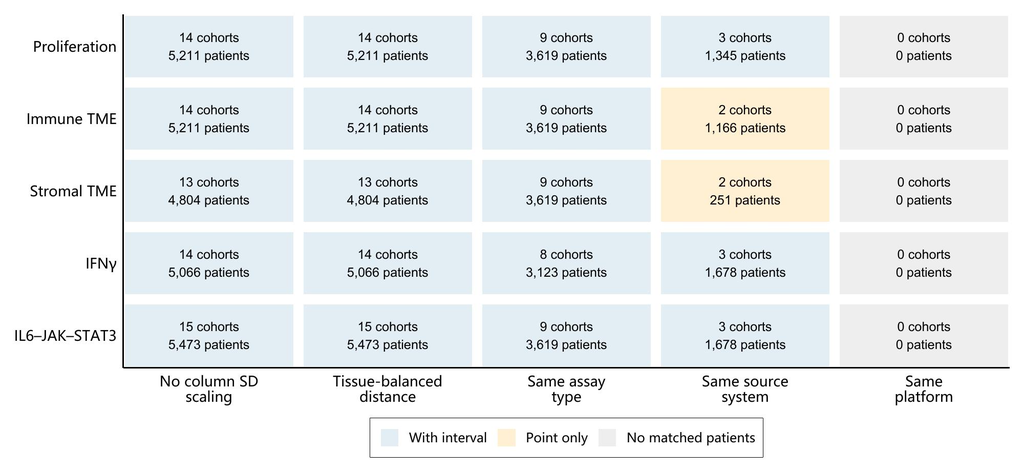

```r
knitr::include_graphics(hc_support_jpg)
```

```r
hc_sensitivity_status <- high_coverage$sensitivity[, c("anchor", "change",
  "cohort_count", "query_count", "status", "reason")]
hc_matched_status <- high_coverage$sensitivity_status
if (nrow(hc_matched_status) == nrow(hc_sensitivity_status) &&
    identical(as.character(hc_matched_status$change),
      as.character(hc_sensitivity_status$change))) {
  hc_sensitivity_status$paired_queries <- hc_matched_status$paired_queries
  hc_sensitivity_status$matching_reason <- hc_matched_status$reason
}
render_dt(hc_sensitivity_status, pageLength = 8)
```

|  | anchor | change | cohort_count | query_count | status | reason | paired_queries | matching_reason |
| --- | --- | --- | --- | --- | --- | --- | --- | --- |
| 1 | proliferation | module_unscaled | 14 | 5211 | estimable | supported | 5211 | matched_patient_difference_in_differences |
| 2 | proliferation | tissue_balanced | 14 | 5211 | estimable | supported | 5211 | matched_patient_difference_in_differences |
| 3 | proliferation | assay_type | 9 | 3619 | estimable | supported | 3619 | matched_patient_difference_in_differences |
| 4 | proliferation | source_system | 3 | 1345 | estimable | supported | 1345 | matched_patient_difference_in_differences |
| 5 | proliferation | platform_id | 0 | 0 | not_estimable | fewer_than_three_cohorts | 0 | no_eligible_matched_queries |
| 6 | immune_tme | module_unscaled | 14 | 5211 | estimable | supported | 5211 | matched_patient_difference_in_differences |
| 7 | immune_tme | tissue_balanced | 14 | 5211 | estimable | supported | 5211 | matched_patient_difference_in_differences |
| 8 | immune_tme | assay_type | 9 | 3619 | estimable | supported | 3619 | matched_patient_difference_in_differences |
| 9 | immune_tme | source_system | 2 | 1166 | not_estimable | fewer_than_three_cohorts | 1166 | matched_patient_difference_in_differences |
| 10 | immune_tme | platform_id | 0 | 0 | not_estimable | fewer_than_three_cohorts | 0 | no_eligible_matched_queries |

[output cut: 15 more lines]

本节支持的判断是：**基质的局部匹配代价在当前高覆盖人群中较稳定，增殖也有较广的负向模式；IFNγ 等结果更受队列与来源组成影响，而两个预设距离调整尚未显示明确补救效果。** 这些结果界定当前方法的适用条件，尚不能识别全部负差的单一根因或评价临床影响。广队列基线继续回答异质部署条件下的表现，本节回答测量较一致条件下的异质性与敏感性，两者应并列报告。

## 6 患者相似性重排的机制线索

高覆盖验证已经给出邻居接近度、连续信息读取及距离敏感性的有效比较。本节进一步观察 d1 如何改变患者周围的邻居，以及哪些模型模块参与相似性判断，帮助解释上一节的表现。这些描述使用更广的检索人群，与各 signature 的高覆盖测量合同不同，应结合各自有效队列和患者数解读；名单重排或距离份额不能换算成某种机制贡献了多少生物效应。

检索核验已在各候选组将 Annoy 与精确欧氏邻居对照，本次 0 条核验记录未通过冻结门禁。它为名单比较提供检索质量检查，但不评价邻居的生物正确性；完整召回图、人数与方法见检索核验附录。

### 6.1 邻居名单的重排意味着什么

这张图检验 **d1 与 Direct 是否在同一个患者周围找到相近的一群邻居**。它提供局部关系重排的证据，应与 gene signature 接近度和连续信息读取结果一起判断这次重排的价值。

```
## Converting page 1 to D:/cache/ccs/_ablation-03/logs/report-previews/02.02.00-biology-20261008205659/02.02.00. diagnostic-neighbor-overlap.jpg... done!
```

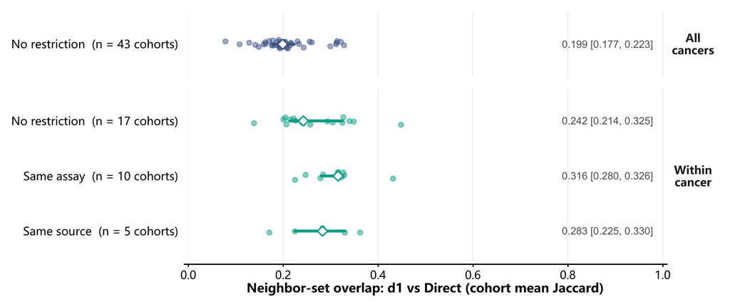

```r
overlap <- diagnostic$neighbor_summary
if (nrow(overlap)) {
  overlap$pool_label <- factor(overlap$pool, levels = c("all", "same_cancer"),
    labels = c(plot_label("All\ncancers", "全癌种"), plot_label("Within\ncancer", "同癌种")))
  restriction_labels <- c(none = plot_label("No restriction", "不限制技术来源"),
    assay_type = plot_label("Same assay", "同检测类型"),
    source_system = plot_label("Same source", "同来源"), platform_id = plot_label("Same platform", "同平台"))
  overlap_groups <- unique(overlap[, c("pool", "restriction", "pool_label")])
  overlap_groups <- overlap_groups[order(match(overlap_groups$pool, c("all", "same_cancer")),
    match(overlap_groups$restriction, names(restriction_labels))), ]
  overlap_groups$key <- paste(overlap_groups$pool, overlap_groups$restriction, sep = ":")
  overlap$key <- paste(overlap$pool, overlap$restriction, sep = ":")
  overlap_summaries <- lapply(overlap_groups$key, function(key) {
    values <- overlap$mean_neighbor_jaccard[overlap$key == key]
    data.frame(cohort_count = length(values),
      median = stats::median(values),
      q1 = unname(stats::quantile(values, .25)),
      q3 = unname(stats::quantile(values, .75)))
  })
  overlap_groups <- cbind(overlap_groups, do.call(rbind, overlap_summaries))
  overlap_summary_text <- function(pool, restriction) {
    x <- overlap_groups[overlap_groups$pool == pool &
      overlap_groups$restriction == restriction, ]
    paste0(fmt(x$median), " [", fmt(x$q1), ", ", fmt(x$q3), "]")
  }
  overlap_groups$row_label <- paste0(unname(restriction_labels[overlap_groups$restriction]),
    plot_label("  (n = ", "  （n = "), overlap_groups$cohort_count,
    plot_label(" cohorts)", " 个队列）"))
  row_labels <- stats::setNames(overlap_groups$row_label, overlap_groups$key)
  row_levels <- rev(overlap_groups$key)
  overlap_groups$row <- factor(overlap_groups$key, levels = row_levels)
  overlap$row <- factor(overlap$key, levels = row_levels)
  p_overlap <- ggplot2::ggplot(overlap,
    ggplot2::aes(x = mean_neighbor_jaccard, y = row, colour = pool_label)) +
    ggplot2::geom_point(position = ggplot2::position_jitter(width = 0, height = .08, seed = 1),
      size = 1.8, alpha = .5) +
    ggplot2::geom_segment(data = overlap_groups, inherit.aes = FALSE,
      ggplot2::aes(x = q1, xend = q3, y = row, yend = row, colour = pool_label),
      linewidth = 1.2, lineend = "round") +
    ggplot2::geom_point(data = overlap_groups, inherit.aes = FALSE,
      ggplot2::aes(x = median, y = row, colour = pool_label),
      shape = 23, fill = "white", size = 2.8, stroke = .8) +
    ggplot2::geom_text(data = overlap_groups, inherit.aes = FALSE,
      ggplot2::aes(x = .98, y = row,
        label = paste0(fmt(median), " [", fmt(q1), ", ", fmt(q3), "]")),
      hjust = 1, size = 3.2, colour = "grey30") +
    ggplot2::facet_grid(pool_label ~ ., scales = "free_y", space = "free_y") +
    ggplot2::scale_y_discrete(labels = row_labels) +
    ggplot2::scale_colour_manual(values = unname(nature_colors[c("navy", "green")]),
      guide = "none") +
    ggplot2::scale_x_continuous(limits = c(0, 1), breaks = seq(0, 1, .2),
      expand = ggplot2::expansion(mult = c(.01, .01))) +
    ggplot2::labs(x = plot_label("Neighbor-set overlap: d1 vs Direct (cohort mean Jaccard)",
      "邻居名单重叠度：d1 与 Direct（队列平均 Jaccard）"), y = NULL) +
    theme_nature_readable(base_size = 10, legend_position = "none") +
    ggplot2::theme(panel.border = ggplot2::element_blank(),
      axis.line.y = ggplot2::element_blank(), axis.ticks.y = ggplot2::element_blank(),
      panel.grid.major.x = ggplot2::element_line(colour = "grey92", linewidth = .3),
      strip.background = ggplot2::element_blank(),
      strip.text.y = ggplot2::element_text(angle = 0),
      panel.spacing.y = grid::unit(.65, "lines"))
  jpg <- .ae_save_plot(p_overlap, "02.02.00. diagnostic-neighbor-overlap",
    figure_dir, preview_dir, list(width_in = 9, height_in = 3.8), params$plot_preview_dpi)
  knitr::include_graphics(jpg)
}
```

图中每个小点是一个队列内共同 query 的平均 Jaccard，菱形及短横线是队列中位数与四分位范围，右侧数字为中位数 [Q1, Q3]；这些是描述性分布，不是置信区间。Jaccard 是两份名单交集人数除以并集人数，0 表示完全不重叠、1 表示完全一致。**这里统一按 d1 与 Direct 的顺序标注，但指标是对称的，不是 d1−Direct 差值，也没有正负方向。**

**当前最直接的结论是：d1 明显重排了患者周围的邻居，而不只是给几乎相同的邻居换一种表示。** 全癌种下，43 个队列的平均 Jaccard 中位数为 0.199 [0.177, 0.223]，多数队列的重叠度集中在较低范围。理解其量级时，可以设想两份各含 15 人的名单只共享 5 人，此时 Jaccard 为 0.200。这是帮助理解尺度的例子，不能把队列平均 Jaccard 直接反算成平均共享人数，也不能把 Jaccard 当作“保留了多少比例的生物信息”。

**这种重排在同癌种内部仍然存在。** 在具备同癌种候选池的 17 个队列中，中位数为 0.242 [0.214, 0.325]。因此，至少在这批合格队列里，要求邻居癌种相同仍不足以让两种表示选出相近名单，不能仅用跨癌种邻居混合解释全部差异。d1 的概率表征与 Direct 的原始输入距离，确实在同癌种患者之间形成了不同的局部关系；本图尚不能识别这些关系变化来自哪一种具体生物或技术因素。

同检测类型与同来源的中位数分别为 0.316 [0.280, 0.326]、0.283 [0.225, 0.330]，但有效队列分别缩小到 10 和 5 个。**更高的重叠度只能描述这些受限条件下的名单一致性，不能直接视为技术因素已被纠正。** 各行使用的队列、患者及候选池大小不同；候选选择减少本身就可能提高两份名单的重合机会。因此不能将行间中位数相减作为技术限制的因果效果，同平台无合格配对也不能补成零重叠。

**对研究者而言，关键问题应从“d1 是否复制了 Direct 的邻居”转向“重排后的邻居是否更适合目标任务”。** Direct 是比较基线，并非邻居正确性的金标准。低重叠既可能伴随局部表达细节的损失，也可能反映 d1 更重视模型可识别的状态，或减弱了某些技术邻近关系；本图无法在这些解释间作出选择。应把 Jaccard 用作定位关系改变的诊断量，再看同一人群中 gene signature 接近度、连续读取误差及独立病理或临床目标是否改善。邻居不同而目标仍可读出，与邻居不同且目标更难读出，是两种需要分别处理的结果。

后续验证可以优先检查低重叠且生物效用较差的队列，同时保留低重叠但目标表现良好的队列作为对照。比较技术限制前后时，应固定两种条件都合格的患者，配对评估名单重叠与目标效用，并核对候选池大小；必要时用同样大小候选池的随机名单重叠作参照。这样才能区分“选择空间变小后自然更容易重合”和“相似性判断发生了有价值的改变”。这些属于下一步可验证的问题。本图较广的检索人群与高覆盖测量合同不同，后续应在具有可靠目标测量的共同患者上评价重排的价值；高覆盖或残余代理结果不能直接替代本图全部队列的生物评价。完整队列与患者数见 neighbor_summary 表。

### 6.2 哪些模型模块在决定患者相似性

**这张图问的是：d1 判断两名患者“有多像”时，依据是否主要来自少数模型模块？** d1 把患者交给多个训练队列对应的模型，每个模型给出一组概率，这一组输出就是一个模块。 找邻居时，会把两名患者在各模块上的输出差异合并为距离；差异越大，两人越不像。 本图把这份距离拆开，看看每个模块占多少。可以把它想成用多门课的成绩比较两名学生： 总差距是很多门课共同形成的，还是主要由少数几门课形成的？

横轴表示**纳入了多少比例的模块**，按本条曲线的距离贡献从大到小依次加入； 纵轴表示这些模块累计占了**多少比例的平方距离**。例如，曲线在横轴 10%、纵轴 50% 处，意思是“贡献最大的十分之一模块，合计占了总平方距离的一半”。灰色对角虚线 代表各模块贡献完全相同：加入 10% 的模块，就累计 10% 的份额。因此，**曲线越向左上 弯曲，距离贡献越集中；越靠近对角线，贡献越分散。**这里的高低描述集中程度， 不表示生物学表现的好坏。

左右面板分别是在所有癌种中找邻居和仅在同癌种中找邻居。蓝线使用当前基线距离； 红线取消“每列除以其 reference 标准差”的缩放步骤；绿线改为先让各组织获得相同的 预设权重，再在组织内平衡模块及模块内的列数。后者平衡的是组织权重，不保证每个 模块对实际距离的贡献相同。

```
## Converting page 1 to D:/cache/ccs/_ablation-03/logs/report-previews/02.02.00-biology-20261008205659/02.02.00. diagnostic-module-distance-concentration.jpg... done!
```

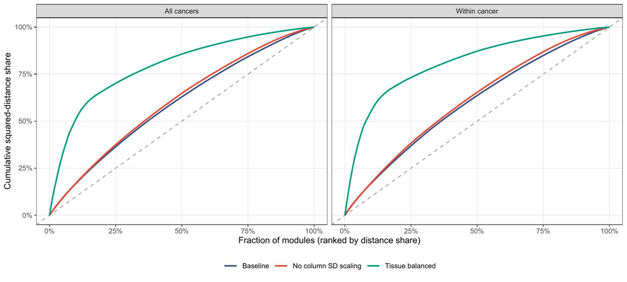

```r
contribution <- diagnostic$module_diagnostics$distance_contributions
concentration_summary <- data.frame()
if (nrow(contribution)) {
  totals <- stats::aggregate(mean_squared_contribution ~ cohort + distance + pool, contribution, sum)
  names(totals)[4L] <- "total"
  contribution <- merge(contribution, totals, by = c("cohort", "distance", "pool"))
  if (any(!is.finite(contribution$total) | contribution$total <= 0) ||
      any(!is.finite(contribution$mean_squared_contribution) | contribution$mean_squared_contribution < 0)) {
    stop("Module distance shares require finite, nonnegative contributions and positive totals.")
  }
  contribution$share <- contribution$mean_squared_contribution / contribution$total
  shares <- stats::aggregate(share ~ module + distance + pool, contribution, mean)
  concentration_summary <- do.call(rbind, lapply(split(shares,
    interaction(shares$distance, shares$pool)), function(x) {
    x <- x[order(-x$share, x$module), ]
    module_count <- nrow(x)
    top_count <- ceiling(.1 * module_count)
    data.frame(pool = x$pool[1L], distance = x$distance[1L], module_count = module_count,
      cohort_count = length(unique(contribution$cohort[contribution$pool == x$pool[1L] &
        contribution$distance == x$distance[1L]])), top_count = top_count,
      top_share = sum(x$share[seq_len(top_count)]), max_share = max(x$share),
      half_count = which(cumsum(x$share) >= .5)[1L])
  }))
  curves <- do.call(rbind, lapply(split(shares, interaction(shares$distance, shares$pool)), function(x) {
    x <- x[order(-x$share, x$module), ]
    stopifnot(abs(sum(x$share) - 1) < 1e-8)
    data.frame(distance = x$distance[1L], pool = x$pool[1L],
      module_fraction = c(0, seq_len(nrow(x)) / nrow(x)), cumulative_share = c(0, pmin(1, cumsum(x$share))))
  }))
  distance_labels <- c(baseline = plot_label("Baseline", "基线"),
    module_unscaled = plot_label("No column SD scaling", "取消逐列标准差缩放"),
    tissue_balanced = plot_label("Tissue balanced", "组织等权"))
  curves$distance_label <- factor(curves$distance, levels = names(distance_labels), labels = unname(distance_labels))
  curves$pool_label <- factor(curves$pool, levels = c("all", "same_cancer"),
    labels = c(plot_label("All cancers", "全癌种"), plot_label("Within cancer", "同癌种")))
  p_concentration <- ggplot2::ggplot(curves,
    ggplot2::aes(x = module_fraction, y = cumulative_share, colour = distance_label)) +
    ggplot2::geom_abline(slope = 1, intercept = 0, linetype = 2, colour = "grey65") +
    ggplot2::geom_line(linewidth = .8) + ggplot2::facet_wrap(~ pool_label, ncol = 2) +
    ggplot2::scale_colour_manual(values = unname(nature_colors[c("navy", "red", "green")])) +
    ggplot2::scale_x_continuous(labels = scales::label_percent(), limits = c(0, 1)) +
    ggplot2::scale_y_continuous(labels = scales::label_percent(), limits = c(0, 1)) +
    ggplot2::labs(x = plot_label("Fraction of modules (ranked by distance share)", "模块比例（按距离份额排序）"),
      y = plot_label("Cumulative squared-distance share", "累计平方距离份额"), colour = NULL) +
    ggplot2::theme_bw(base_size = 10) + ggplot2::theme(legend.position = "bottom",
      panel.grid.minor = ggplot2::element_blank())
  jpg <- .ae_save_plot(p_concentration, "02.02.00. diagnostic-module-distance-concentration",
    figure_dir, preview_dir, list(width_in = 10, height_in = 4.5), params$plot_preview_dpi)
  knitr::include_graphics(jpg)
}
```

```r
if (nrow(concentration_summary)) {
  concentration_value <- function(distance, pool, field) {
    concentration_summary[[field]][concentration_summary$distance == distance &
      concentration_summary$pool == pool]
  }
  cat("**当前蓝线的结论是：贡献有不均匀，但没有由极少数模块包揽距离。**\n\n",
    "当前每种规则均有 ", unique(concentration_summary$module_count), " 个模块，前 10% 即 ",
    unique(concentration_summary$top_count), " 个。基线下，这些模块在全癌种／同癌种中分别占 ",
    fmt_pct(concentration_value("baseline", "all", "top_share")), "／",
    fmt_pct(concentration_value("baseline", "same_cancer", "top_share")),
    " 的平方距离；要累计达到一半，需要分别加入 ",
    concentration_value("baseline", "all", "half_count"), "／",
    concentration_value("baseline", "same_cancer", "half_count"), " 个模块。其余 ",
    unique(concentration_summary$module_count - concentration_summary$top_count),
    " 个模块仍合计占 ", fmt_pct(1 - concentration_value("baseline", "all", "top_share")),
    "／", fmt_pct(1 - concentration_value("baseline", "same_cancer", "top_share")), "。\n\n",
    "**红线与蓝线接近，说明取消逐列标准差缩放后，距离贡献的整体集中程度变化不大。**\n\n",
    "全癌种／同癌种下，前 10% 模块的份额分别为 ",
    fmt_pct(concentration_value("module_unscaled", "all", "top_share")), "／",
    fmt_pct(concentration_value("module_unscaled", "same_cancer", "top_share")),
    "。这只说明集中程度接近，不能推断具体模块权重、患者距离或邻居名单完全相同。\n\n",
    "**绿线明显更向左上弯曲，说明组织等权规则下，距离反而更集中在少数模块。**\n\n",
    "前 10% 模块在全癌种／同癌种中分别占 ",
    fmt_pct(concentration_value("tissue_balanced", "all", "top_share")), "／",
    fmt_pct(concentration_value("tissue_balanced", "same_cancer", "top_share")),
    "；分别 ", concentration_value("tissue_balanced", "all", "half_count"), "／",
    concentration_value("tissue_balanced", "same_cancer", "half_count"),
    " 个模块就累计达到一半。组织等权并不等于模块等权：一个组织若只有少数模块，",
    "其组织份额会分给更少的模块。这是理解绿线的一种权重机制，但实际曲线还受模块输出差异",
    "和新邻居名单影响，不能仅凭本图把原因全部归于组织模块数量。\n\n",
    "本图的实际提示是：**基线相似性判断仍综合了许多模块；组织等权会明显改变模块贡献",
    "的分布，因此不能把“权重更均匀”直接理解成“模块贡献更分散”或“邻居更好”。**\n\n",
    "这里的“距离份额”是平方欧氏距离的组成，不能读成生物信息保留率、预测准确率或",
    "原锚点差距的成因占比。\n\n", sep = "")
} else {
  cat("当前没有可用的模块距离贡献，无法描述实际集中程度；不生成曲线或补零。\n\n")
}
```

**当前蓝线的结论是：贡献有不均匀，但没有由极少数模块包揽距离。**

当前每种规则均有 150 个模块，前 10% 即 15 个。基线下，这些模块在全癌种／同癌种中分别占 16.9%／17.1% 的平方距离；要累计达到一半，需要分别加入 56／55 个模块。其余 135 个模块仍合计占 83.1%／82.9%。

**红线与蓝线接近，说明取消逐列标准差缩放后，距离贡献的整体集中程度变化不大。**

全癌种／同癌种下，前 10% 模块的份额分别为 17.1%／17.3%。这只说明集中程度接近，不能推断具体模块权重、患者距离或邻居名单完全相同。

**绿线明显更向左上弯曲，说明组织等权规则下，距离反而更集中在少数模块。**

前 10% 模块在全癌种／同癌种中分别占 51.2%／55.5%；分别 15／12 个模块就累计达到一半。组织等权并不等于模块等权：一个组织若只有少数模块，其组织份额会分给更少的模块。这是理解绿线的一种权重机制，但实际曲线还受模块输出差异和新邻居名单影响，不能仅凭本图把原因全部归于组织模块数量。

本图的实际提示是：**基线相似性判断仍综合了许多模块；组织等权会明显改变模块贡献的分布，因此不能把“权重更均匀”直接理解成“模块贡献更分散”或“邻居更好”。**

这里的“距离份额”是平方欧氏距离的组成，不能读成生物信息保留率、预测准确率或原锚点差距的成因占比。

```r
if (nrow(concentration_summary)) {
  concentration_table <- concentration_summary[order(match(concentration_summary$pool,
    c("all", "same_cancer")), match(concentration_summary$distance, names(distance_labels))), ]
  concentration_table <- data.frame(
    候选范围 = ifelse(concentration_table$pool == "all", "全癌种", "同癌种"),
    距离规则 = unname(distance_labels[concentration_table$distance]),
    有效队列数 = concentration_table$cohort_count,
    前10_模块的距离份额 = fmt_pct(concentration_table$top_share),
    达到一半所需模块数 = paste0(concentration_table$half_count, " / ", concentration_table$module_count),
    check.names = FALSE)
  names(concentration_table)[4L] <- "前 10% 模块的距离份额"
  render_dt(concentration_table, pageLength = 6)
}
```

|  | 候选范围 | 距离规则 | 有效队列数 | 前 10% 模块的距离份额 | 达到一半所需模块数 |
| --- | --- | --- | --- | --- | --- |
| 1 | 全癌种 | Baseline | 43 | 16.9% | 56 / 150 |
| 2 | 全癌种 | No column SD scaling | 43 | 17.1% | 54 / 150 |
| 3 | 全癌种 | Tissue balanced | 43 | 51.2% | 15 / 150 |
| 4 | 同癌种 | Baseline | 17 | 17.1% | 55 / 150 |
| 5 | 同癌种 | No column SD scaling | 17 | 17.3% | 53 / 150 |
| 6 | 同癌种 | Tissue balanced | 17 | 55.5% | 12 / 150 |

计算时先在每个 cohort 内，把其当前距离规则及邻居名单上的各模块平均平方差归一化 为 100%，再对 cohort 等权汇总；所以大队列不会仅凭患者更多而获得更多票。各条 曲线分别排序，同一横轴位置并不对应同一组模块。每种距离规则也会重新找邻居， 曲线同时反映权重与所选邻居的变化。各条件的有效队列数见上表；两面板不构成同一批 患者的配对变化。本图不提供置信区间或显著性检验，只描述 当前冻结模型和候选池下的距离组成；是否改善 gene signature 接近度，应另看对应的效用比较。

## 7 讨论与分析

### 7.1 邻居关系改变与跨队列表征的取舍

生物 anchor 分析最重要的判断包含两个部分：**d1 改变了局部生物表达关系，这一改变的平均代价又相对有限。** 广队列五项接近度均有平均负差，区间与校正检验支持其方向；但点估计的绝对下降约为 0.04–0.06。高覆盖同癌种验证的五项平均差进一步集中在零附近。变化是否存在与变化是否足以影响方法选择，是两个不同的问题，后者需要同时考虑效应量和 CCS 的用途。

CCS 通过多个队列模型将患者映射到共同表示空间，使来自不同队列的患者可以在同一表征下比较。以这一目标衡量，接受少量局部表达匹配精度的损失，是合理且可以接受的方法取舍。当前结果支持这种基于效应量的判断；它并不要求 d1 在每个 gene signature 上都超过 Direct。若任务主要是寻找原始表达状态最接近的邻居，Direct 的局部优势仍有实际意义；若任务主要是跨队列比较和分层，d1 提供的共同表示具有更直接的方法价值。

“平均代价较小”不意味着每个 cohort 的代价都小。CPTAC-LUSC-2021 等队列的负差明显较大，需要单独解释和验证。这里的代价是 gene signature 接近度的变化，不能换算为分类准确率或患者获益下降的百分比。基于当前量级接受这一方法取舍，与通过预设界值证明非劣效或等价，属于不同层次的结论；本分析提供前者，后者需要相应设计。

### 7.2 广队列基线显示了哪一种局部代价

本次预设 gene signature 包括增殖、免疫微环境、基质微环境及 IFNγ 与 IL6-JAK-STAT3 相关 gene signature。它们问的是：对同一个外部患者，d1 找到的邻居在这些连续表达分数上，是否比 Direct 找到的邻居更接近？当前 5／5 项 cohort 等权点估计为负，5 项可估计结果的 95% 区间完全低于零。具体差值与区间为：ifn：-0.052 [-0.073, -0.030]；il6：-0.059 [-0.079, -0.036]；immune_tme：-0.048 [-0.068, -0.027]；proliferation：-0.044 [-0.061, -0.024]；stromal_tme：-0.052 [-0.070, -0.033]。这些是各 gene signature utility 的绝对差，负值表示当前局部表达接近度偏向 Direct。

绝对点估计差最大的是 il6，d1−Direct 为 -0.059，95% 区间为 [-0.079, -0.036]，涉及 43 个 cohort、14060 个 query，BH 校正 P 值为 <0.001。这里的“最大”只指预设 gene signature 内的量级；几个 gene signature 也可能共同反映相近的表达过程，不能视为同样多次完全独立的机制验证。

utility 先把每个邻居的分数距离转换为指数接近度，再平均。上面的负差是接近度分数的绝对变化，不能换算为错误邻居的比例，也不是患者获益下降的比例。由于指数转换是非线性的，不能仅凭平均 utility 差倒推出平均表达距离增加多少。当前证据能够说明这组预设gene signature 分数的局部匹配代价，尚未给出该代价对诊断、治疗或生存的影响。

### 7.3 为什么接近度下降不能直接解释为生物信息损失

当前评分可能同时携带生物信号和技术差异。因此，负差首先说明 d1 邻居在当前 gene signature 分数上较不接近 query，不能直接归结为生物信息损失；正差也不能直接证明生物状态匹配改善。尤其是 Direct 与 d1 可能选中不同平台或来源的邻居，固定 query 和 reference 标尺并没有控制这些邻居的 batch 构成。

表示压缩是另一个待检验的解释。Direct 保留用于比较的原始特征，d1 则把患者变成多个冻结模型的概率输出。对模型判断很相近的两个患者，某一 gene signature 分数仍可能相差不少；因此在 d1 空间中成为邻居，并不要求所有表达细节都相近。当前评分不足以把这种变化与技术差异的影响分开。

广队列基线的负差支持一种待检验的解释：概率重编码可能保留了较粗状态，同时改变了精细表达排序。高覆盖验证已经在测量较一致的人群中分别比较邻居效用、连续读取与距离规则，不再依赖全队列共同交集才能进行判断。当前两个预设距离调整尚未显示明确补救效果，而邻居效用与读取表现可以出现不同方向，说明局部几何与目标可恢复性需要分开评价。癌种或来源迁移、权重与输入同源性仍可能参与这些变化；现有结果提供机制线索，尚不能将全部负差归于单一原因。当前效应量可用于判断方法取舍，独立目标的验证则用于判断具体任务的收益。

结构报告将同一批 gene signature 划为高低状态，再比较状态之间的距离排序。患者附近的连续分数可以变得较不接近，而高低状态的大体地图仍然相似；两种结果在测量尺度上可以共存。不过当前结构平均差接近零，仍不能证明粗状态无损，更不能用它抵消本页已经观察到的局部负差。用途若是寻找表达状态尽量接近的邻居，本页直接对应这一需求；用途若是跨队列状态分层，则需结合结构结果和独立验证。

### 7.4 高覆盖验证怎样补充广队列基线

选定高覆盖合同的共同 gene signature 与测量人数为：proliferation 14/15 基因（93.3%），16 个 query cohort、3 个来源组；immune_tme 19/26 基因（73.1%），16 个 query cohort、3 个来源组；stromal_tme 17/18 基因（94.4%），15 个 query cohort、3 个来源组；ifn 161/200 基因（80.5%），15 个 query cohort、3 个来源组；il6 72/87 基因（82.8%），16 个 query cohort、3 个来源组。这些是测量合同的人数，效应分析还要通过完整背景、评分及候选池支持门槛。可估计的秩同癌种主比较有 5 项，其中 2 项 95% 区间完全低于零：Proliferation：-0.014，95% CI [-0.026, -0.000]，14 个队列 / 5211 个 query；Immune TME：-0.005，95% CI [-0.016, 0.007]，14 个队列 / 5211 个 query；Stromal TME：-0.016，95% CI [-0.027, -0.006]，13 个队列 / 4804 个 query；IFNγ：0.003，95% CI [-0.011, 0.016]，14 个队列 / 5066 个 query；IL6–JAK–STAT3：0.009，95% CI [-0.004, 0.023]，15 个队列 / 5473 个 query。

高覆盖验证回答统一 gene signature、癌种内部的邻居几何，43-cohort 广队列基线回答异质测量条件下的广队列部署表现。两者改变了评分定义和验证人群，不能将总体差值的减小直接解释为某个机制贡献的比例；该问题应结合冻结合同内、共同患者上的评分／候选池差中差。连续读取器进一步检验同一目标能否从表示中恢复：秩 ridge 的标准化 MAE 差为 Proliferation：0.024，95% CI [-0.013, 0.059]，14 个队列 / 5211 个 query；Immune TME：0.022，95% CI [-0.004, 0.049]，14 个队列 / 5211 个 query；Stromal TME：0.018，95% CI [-0.031, 0.075]，13 个队列 / 4804 个 query；IFNγ：0.025，95% CI [0.003, 0.052]，14 个队列 / 5066 个 query；IL6–JAK–STAT3：0.049，95% CI [0.024, 0.071]，15 个队列 / 5473 个 query，正值表示 d1 更差。效用与读取器同时出现不利证据，才加强表示压缩的解释；读取器区间跨零仍不足以证明信息无损。

当前五项高覆盖主比较均可估计；不同 signature 的有效人群仍须分别报告。五项 gene signature 共同验证人群 C_core 有 13 个合格队列；不能用测量合同的队列交集替代实际评分资格。当前结果条件于冻结 bank、reference atlas 和合同，来源共享与未确认的预处理差异仍限制向全新测量系统的推广。

### 7.5 总体负差是否意味着每个 cohort 都变差

当前 cohort–gene signature 格子中，负差比例为 90.2%。总体均值与每个格子的方向因此应分开阅读：平均下降不要求所有队列下降，也不能说明每名患者都会受影响。热图用于定位负差集中在哪些队列与 gene signature；颜色最深的格子用于定位队列差异，属于描述性结果。

主效应先计算同一 query 的配对差，再对 cohort 等权，区间按完整 cohort 重采样。它防止大队列仅凭人数主导平均值，但多个 cohort 仍可能共享技术来源。“队列间效应分布”中的队列内 query 区间回答“这个已固定队列中，换一批患者会怎样”，主区间回答“当前队列组合发生变化时，平均差怎样波动”；两者都条件于冻结模型和当前 reference 候选池，不包含整个 bank 重训后的不确定性。用单格很窄的 query 区间替代跨 cohort 区间，会夸大向新队列推广的精度。

### 7.6 覆盖审计排除了什么，又留下什么

本次有 950 条 cohort–gene signature 覆盖记录；外部组合中 24 条未达到完整覆盖，实际缺失分数的 query–邻居对有 0 个。若缺失对为零，只表示当前保留的配对分数完整，不表示每个分数都使用了全部 gene signature 基因。部分覆盖队列可能用不同基因子集计算同名 gene signature，所以解释其局部效应时还需核对 gene signature 构成。

覆盖审计与主效应配对解决的是不同问题：前者检查测量是否可计算，后者确保差值没有混入两臂患者组成差异。即便这两项都通过，也没有让 gene signature 成为与模型输入独立的临床结局。因此现阶段应保留当前负差作为表达信息保留的诊断结果，避免把它扩展为全部生物任务的排名。

### 7.7 后续验证怎样区分原因与用途

首先，可以在未见 cohort 中补齐覆盖和已知平台信息，预先固定共同 gene signature 基因集，并按癌种、平台和来源分层执行同一配对比较。若负差在完整覆盖且来源匹配后仍跨队列同向，就更支持表示重排本身对这些gene signature 分数的局部代价；若主要集中于部分覆盖或单一来源，应先限制结论的测量与人群范围。这项设计需同时报告各层有效 query 数，避免只保留有利层。

其次，应选择一种与输入来源不同的测量，例如病理评估的免疫浸润、蛋白测量或治疗反应，在整组未见 cohort 上比较两种表示。预先规定有意义的收益或可接受损失，检验区间及癌种内方向。这将把当前基于效应量的方法取舍，推进到具体任务收益和临床可接受性的验证。当前高覆盖分析已经完成同癌种、来源限制与共同人群等条件下的验证；全新队列和不同来源测量的独立临床验证仍未执行。

## 8 结果来源与汇总口径

| 核查 | 当前证据 |
| --- | --- |
| 来源 | 当前 gene signature CSV/RDS 与表示分析的来源记录对应 |
| 配对 | 两臂各有完整 top-15 后按同一 query 配对 |
| 独立单位 | cohort 等权效应与 cohort bootstrap；BH 校正 |
| 数字 | 广队列基线读取 `biology_inference`，高覆盖读取正式 `biology_high_coverage_inference` target |

## 9 附录：全队列共同测量审计

本附录保存以全部队列共同基因交集为前提的诊断设计与资格结果，说明为什么正文转向按 signature 筛选高覆盖队列。这里的不可估计与未运行状态属于全队列合同，不是正文高覆盖验证的状态。设计参数见 `config/biology-diagnostics.yml`，随机种子为 20261004；原表、支持图与分支记录保留，便于复核分析边界。

### 9.1 全队列共同交集的测量支持

全队列共同交集诊断采用共同原尺度与样本内秩评分；秩背景门槛为 3000，当前为 1130 个共同基因。五项 signature 的共同覆盖为 proliferation：5/15；immune_tme：4/26；stromal_tme：1/18；ifn：39/200；il6：19/87，测量合格 0／5 项。该合同缺少可比较目标，不能据此认定测量问题导致了广队列负差，也不能把未拟合的读取器解释为预测失败。

正文的高覆盖验证分别冻结各 signature 的兼容队列与共同基因；低覆盖附录则使用残余基因代理提供探索线索。三者的测量定义、有效人群与证据用途不同。

### 9.2 测量与候选池的资格

共同 gene signature 按全部 190 个契约队列可用性交集固定，清单身份为 0b3224ce3a3237bbec6d3c6af7ba78b041a8334097af1f3be3c79cf2fd20942d；严格 gene signature 至少保留一半且不少于八个基因。原尺度先按 reference 逐基因定标、取 gene signature 均值，再按 reference 分数标准差定标。秩分数对固定背景使用平均秩 `(rank−0.5)/背景数`，取 gene signature 均值后按 reference 分数定标。背景数量不限制原尺度资格；严格秩分支同时要求背景门槛。

```r
gate <- diagnostic_primary_coverage
gate$required <- pmax(diagnostic$config$min_signature_genes,
  ceiling(diagnostic$config$min_signature_fraction * gate$original_count))
gate$available <- gate$common_count
gate$label <- unname(anchor_labels[gate$anchor])
gate <- gate[, c("label", "available", "required")]
gate <- rbind(gate, data.frame(label = plot_label("Rank background", "秩背景"),
  available = length(diagnostic_audit$background), required = diagnostic$config$min_background_genes))
gate$ratio <- gate$available / gate$required
gate$count <- paste0(format(gate$available, big.mark = ",", trim = TRUE), " / ",
  format(gate$required, big.mark = ",", trim = TRUE))
gate$label <- factor(gate$label, levels = rev(gate$label))
p_gate <- ggplot2::ggplot(gate, ggplot2::aes(x = ratio, y = label)) +
  ggplot2::geom_col(width = .55, fill = nature_colors[["navy"]]) +
  ggplot2::geom_vline(xintercept = 1, linetype = 2, colour = "grey40") +
  ggplot2::geom_text(ggplot2::aes(label = count), hjust = -.15, size = 3.5) +
  ggplot2::scale_x_continuous(limits = c(0, max(1.2, max(gate$ratio) * 1.3)),
    labels = scales::label_percent()) +
  ggplot2::labs(x = plot_label("Available genes / minimum required genes", "可用基因数／最低所需基因数"), y = NULL) +
  ggplot2::theme_bw(base_size = 10) +
  ggplot2::theme(panel.grid.minor = ggplot2::element_blank())
jpg <- .ae_save_plot(p_gate, "02.02.00. diagnostic-measurement-gates",
  figure_dir, preview_dir, list(width_in = 10, height_in = 3.5), params$plot_preview_dpi)
```

```
## Converting page 1 to D:/cache/ccs/_ablation-03/logs/report-previews/02.02.00-biology-20261008205659/02.02.00. diagnostic-measurement-gates.jpg... done!
```

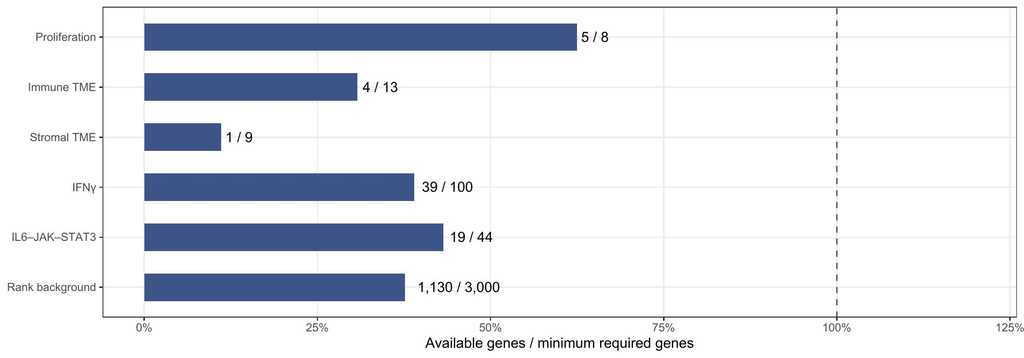

```r
knitr::include_graphics(jpg)
```

解读：虚线为达到冻结门槛的 100%，标注是“实际共同基因数／最低所需基因数”，不是完整 gene signature 保留比例。gene signature 最低数量取比例门槛与绝对数量门槛中的较大值；秩背景单独要求至少 3000 个共同基因。柱未到线表示该测量前提不足，不是效应为零，也不是广队列负差已归因于测量。

下图先概括同癌种候选池的支持：左边按队列数、右边按患者数计数，两种分母分别展示；有检索资格表示已知癌种及 reference 候选支持满足门槛，尚未检查完整 gene signature 的测量资格。

```r
diag_candidate <- diagnostic_tables$qualification
diag_candidate$group <- ifelse(diag_candidate$eligible,
  "Eligible candidate pool", "Insufficient reference cohorts")
diag_candidate_summary <- stats::aggregate(query_count ~ group,
  diag_candidate, sum)
diag_candidate_summary$cohort_count <- vapply(diag_candidate_summary$group,
  function(group) sum(diag_candidate$group == group), integer(1))
diag_candidate_plot <- rbind(
  data.frame(group = diag_candidate_summary$group,
    count = diag_candidate_summary$cohort_count, unit = "Query cohorts"),
  data.frame(group = diag_candidate_summary$group,
    count = diag_candidate_summary$query_count, unit = "Query patients"))
diag_candidate_plot$group <- factor(diag_candidate_plot$group,
  levels = c("Insufficient reference cohorts", "Eligible candidate pool"))
diag_candidate_plot$unit <- factor(diag_candidate_plot$unit,
  levels = c("Query cohorts", "Query patients"))
p_diag_candidate <- ggplot2::ggplot(diag_candidate_plot,
  ggplot2::aes(x = count, y = group, fill = group)) +
  ggplot2::geom_col(width = .5) +
  ggplot2::geom_text(ggplot2::aes(label = fmt_n(count)), hjust = -.15, size = 3.5) +
  ggplot2::facet_wrap(~ unit, scales = "free_x", ncol = 2) +
  ggplot2::scale_x_continuous(breaks = scales::breaks_pretty(n = 3),
    labels = scales::label_comma(), expand = ggplot2::expansion(mult = c(0, .25))) +
  ggplot2::scale_y_discrete(labels = c("Eligible candidate pool" = "Eligible candidate\npool",
    "Insufficient reference cohorts" = "Fewer than two\nreference cohorts")) +
  ggplot2::scale_fill_manual(values = c("Eligible candidate pool" = nature_colors[["navy"]],
    "Insufficient reference cohorts" = "grey75"), guide = "none") +
  ggplot2::labs(x = "Count", y = NULL) +
  theme_nature_readable(base_size = params$diagnostic_plot_base_size,
    legend_position = "none")
diag_candidate_jpg <- hc_save_plot(p_diag_candidate, "02.02.00. diagnostic-candidate-support",
  width = 10, height = 3.5)
```

```
## Converting page 1 to D:/cache/ccs/_ablation-03/logs/report-previews/02.02.00-biology-20261008205659/02.02.00. diagnostic-candidate-support.jpg... done!
```

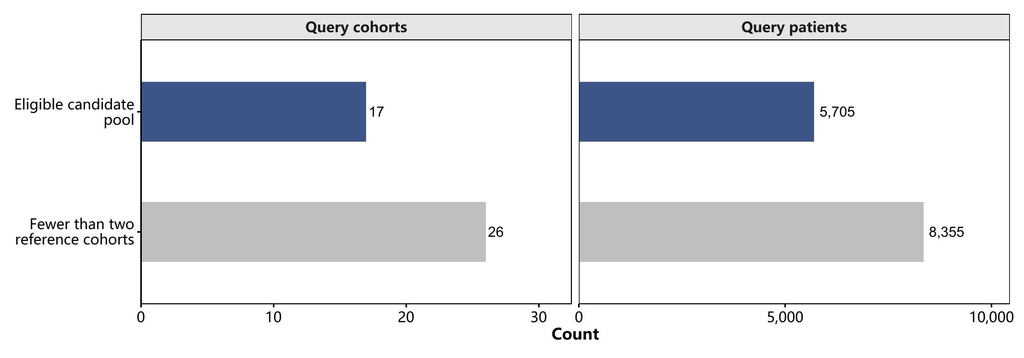

```r
knitr::include_graphics(diag_candidate_jpg)
```

解读：当前有 17／43 个 query 队列具备同癌种检索资格，对应 5,705／14,060 名患者；其余队列缺少至少两个 reference 队列。队列比例与患者比例不同，不能互相替代。即便候选池合格，严格评分仍可能因共同基因不足而无法计算；因此不能把这些人数当作后面完整 gene signature 效应的有效人数。

```r
render_dt(diagnostic_tables$qualification, pageLength = 10)
```

|  | cohort | cancer_type | reference_count | reference_cohort_count | eligible | reason | original_endpoint_status | query_count |
| --- | --- | --- | --- | --- | --- | --- | --- | --- |
| 1 | ACC/TCGATARGET-ACC | ACC | 354 | 8 | True | supported | estimable | 77 |
| 78 | Blood/OHSU-Blood-2022 | Blood | 0 | 0 | False | fewer_than_two_reference_cohorts | not_estimable | 671 |
| 749 | Blood/OHSU-Blood-2018 | Blood | 0 | 0 | False | fewer_than_two_reference_cohorts | not_estimable | 451 |
| 1200 | Blood/Broad-Blood-2022 | Blood | 0 | 0 | False | fewer_than_two_reference_cohorts | not_estimable | 715 |
| 1915 | Blood/PCAWG-PanCan-2017_Blood | Blood | 0 | 0 | False | fewer_than_two_reference_cohorts | not_estimable | 101 |
| 2016 | Blood/TCGATARGET-Blood | Blood | 0 | 0 | False | fewer_than_two_reference_cohorts | not_estimable | 761 |
| 2777 | BRCA/CPTAC-BRCA-2020 | BRCA | 6973 | 20 | True | supported | estimable | 122 |
| 2899 | BRCA/TCGATARGET-BRCA | BRCA | 6973 | 20 | True | supported | estimable | 1094 |
| 3993 | CRC/TCGATARGET-COAD | CRC | 5963 | 41 | True | supported | estimable | 290 |
| 4283 | CRC/TCGATARGET-READ | CRC | 5963 | 41 | True | supported | estimable | 93 |

[output cut: 33 more lines]

```r
render_dt(diagnostic_tables$experiment_qualification,
  n = nrow(diagnostic_tables$experiment_qualification), pageLength = 10)
```

|  | comparison | score_definition | anchor | cohort | total_queries | paired_queries | effective_queries | eligible_inference | reason |
| --- | --- | --- | --- | --- | --- | --- | --- | --- | --- |
| 1 | grid:common_raw:all:baseline:none | common_raw | proliferation | ACC/TCGATARGET-ACC | 77 | 0 | 0 | False | no_complete_paired_queries |
| 2 | grid:common_raw:all:baseline:none | common_raw | proliferation | Blood/OHSU-Blood-2022 | 671 | 0 | 0 | False | no_complete_paired_queries |
| 3 | grid:common_raw:all:baseline:none | common_raw | proliferation | Blood/OHSU-Blood-2018 | 451 | 0 | 0 | False | no_complete_paired_queries |
| 4 | grid:common_raw:all:baseline:none | common_raw | proliferation | Blood/Broad-Blood-2022 | 715 | 0 | 0 | False | no_complete_paired_queries |
| 5 | grid:common_raw:all:baseline:none | common_raw | proliferation | Blood/PCAWG-PanCan-2017_Blood | 101 | 0 | 0 | False | no_complete_paired_queries |
| 6 | grid:common_raw:all:baseline:none | common_raw | proliferation | Blood/TCGATARGET-Blood | 761 | 0 | 0 | False | no_complete_paired_queries |
| 7 | grid:common_raw:all:baseline:none | common_raw | proliferation | BRCA/CPTAC-BRCA-2020 | 122 | 0 | 0 | False | no_complete_paired_queries |
| 8 | grid:common_raw:all:baseline:none | common_raw | proliferation | BRCA/TCGATARGET-BRCA | 1094 | 0 | 0 | False | no_complete_paired_queries |
| 9 | grid:common_raw:all:baseline:none | common_raw | proliferation | CRC/TCGATARGET-COAD | 290 | 0 | 0 | False | no_complete_paired_queries |
| 10 | grid:common_raw:all:baseline:none | common_raw | proliferation | CRC/TCGATARGET-READ | 93 | 0 | 0 | False | no_complete_paired_queries |

[output cut: 2570 more lines]

解读：癌种内候选池同时要求有证据的癌种标签、至少两个独立 reference cohort 和完整 top-15；表中同时列出癌种终点与同癌种检索的纳入资格。每个 cohort 至少二十个有效配对 query 才进入跨 cohort 推断，描述数据仍保留。可用于癌种内检索的 query 为 5705 个，涉及 17 个 cohort。平台的 unknown/unknow 被排除，不作为真实平台。表达单位缺少可靠 cohort 记录的 190 个队列仍标为未知；未根据数值范围自动取对数、中心化或删除异常队列。

```r
render_dt(diagnostic_audit$coverage, pageLength = 12)
```

|  | anchor | original_count | common_count | coverage | input_overlap_count | estimable | reason |
| --- | --- | --- | --- | --- | --- | --- | --- |
| 1 | proliferation | 15 | 5 | 0.3333333333333333 | 0 | False | below_50_percent_or_eight_genes |
| 2 | immune_tme | 26 | 4 | 0.1538461538461539 | 0 | False | below_50_percent_or_eight_genes |
| 3 | stromal_tme | 18 | 1 | 0.05555555555555555 | 0 | False | below_50_percent_or_eight_genes |
| 4 | ifn | 200 | 39 | 0.195 | 0 | False | below_50_percent_or_eight_genes |
| 5 | il6 | 87 | 19 | 0.2183908045977012 | 0 | False | below_50_percent_or_eight_genes |
| 6 | proliferation_disjoint | 15 | 5 | 0.3333333333333333 | 0 | False | below_50_percent_or_eight_genes |
| 7 | immune_tme_disjoint | 26 | 4 | 0.1538461538461539 | 0 | False | below_50_percent_or_eight_genes |
| 8 | stromal_tme_disjoint | 18 | 1 | 0.05555555555555555 | 0 | False | below_50_percent_or_eight_genes |
| 9 | ifn_disjoint | 200 | 39 | 0.195 | 0 | False | below_50_percent_or_eight_genes |
| 10 | il6_disjoint | 87 | 19 | 0.2183908045977012 | 0 | False | below_50_percent_or_eight_genes |

直接输入不重叠 gene signature 依据普通基因、基因对以及冻结 geneSet 的完整保守支持集合确定；set-pair 的列名不作为基因列表。输入支持状态为 complete_conservative_frozen_geneSet_support。该分析检验 gene signature 与模型直接输入是否重叠；表达相关性仍可能存在，结果不构成独立病理或临床验证。IFNγ 与 IL6-JAK-STAT3 分别属于五项主要 gene signature。

### 9.3 全队列评分与候选池对照的资格

以下比较仍使用全队列共同交集合同；原尺度／秩评分各使用全癌种和同癌种候选池，两臂保持基线距离和 k=15。严格分析仅在测量有支持时于四格共同患者上比较 d1−Direct utility，计算评分切换的配对差中差。横线来自完整 cohort 配对重采样的 95% 区间；至少三个 cohort、两千次 bootstrap 中至少一千九百次有效才发布区间。

严格评分的部分效应图在没有可估计结果时不会生成。下方支持矩阵完整列出评分、候选池、配对切换与补充比较：颜色表示能否估计，格内数字是实际参与推断的队列与患者数。对输入不重叠补充，列名指对应的原始 signature，基因集合按该补充合同确定。

```r
diag_comparison_labels <- c(
  `grid:common_raw:all:baseline:none` = "Raw score / all cancers",
  `grid:common_raw:same_cancer:baseline:none` = "Raw score / within cancer",
  `grid:common_rank:all:baseline:none` = "Rank score / all cancers",
  `grid:common_rank:same_cancer:baseline:none` = "Rank score / within cancer",
  `change:raw_pool` = "Raw score: all -> within cancer",
  `change:rank_pool` = "Rank score: all -> within cancer",
  `change:all_score` = "All cancers: raw -> rank",
  `change:same_score` = "Within cancer: raw -> rank",
  `coverage:common_raw` = "Raw score / broader availability",
  `coverage:common_rank` = "Rank score / broader availability",
  `supplement:common_raw:direct_input_disjoint` = "Input-disjoint / raw score",
  `supplement:common_rank:direct_input_disjoint` = "Input-disjoint / rank score")
diag_support <- diagnostic$inference
diag_support$anchor_family <- factor(sub("_disjoint$", "", diag_support$anchor),
  levels = names(anchor_labels))
diag_support$comparison <- factor(diag_support$comparison,
  levels = rev(names(diag_comparison_labels)))
diag_support$availability <- ifelse(diag_support$status == "estimable" &
  is.finite(diag_support$estimate), "Estimable", "Unavailable")
diag_support$label <- paste0(diag_support$cohort_count, " cohorts\n",
  fmt_n(diag_support$query_count), " queries")
p_diag_support <- ggplot2::ggplot(diag_support,
  ggplot2::aes(x = anchor_family, y = comparison, fill = availability)) +
  ggplot2::geom_tile(color = "white", linewidth = 1, width = .96, height = .93) +
  ggplot2::geom_text(ggplot2::aes(label = label), size = 3.1, lineheight = 1.1) +
  ggplot2::scale_x_discrete(labels = anchor_labels, position = "top", expand = c(0, 0)) +
  ggplot2::scale_y_discrete(labels = diag_comparison_labels, expand = c(0, 0)) +
  ggplot2::scale_fill_manual(values = c("Estimable" = "#E3EEF4", "Unavailable" = "#EEEEEE")) +
  ggplot2::labs(x = NULL, y = NULL, fill = NULL) +
  theme_nature_readable(base_size = params$diagnostic_plot_base_size,
    legend_position = "bottom") +
  ggplot2::theme(axis.ticks = ggplot2::element_blank(),
    panel.border = ggplot2::element_blank())
diag_support_jpg <- hc_save_plot(p_diag_support, "02.02.00. diagnostic-comparison-support",
  width = params$diagnostic_plot_width, height = 8)
```

```
## Converting page 1 to D:/cache/ccs/_ablation-03/logs/report-previews/02.02.00-biology-20261008205659/02.02.00. diagnostic-comparison-support.jpg... done!
```

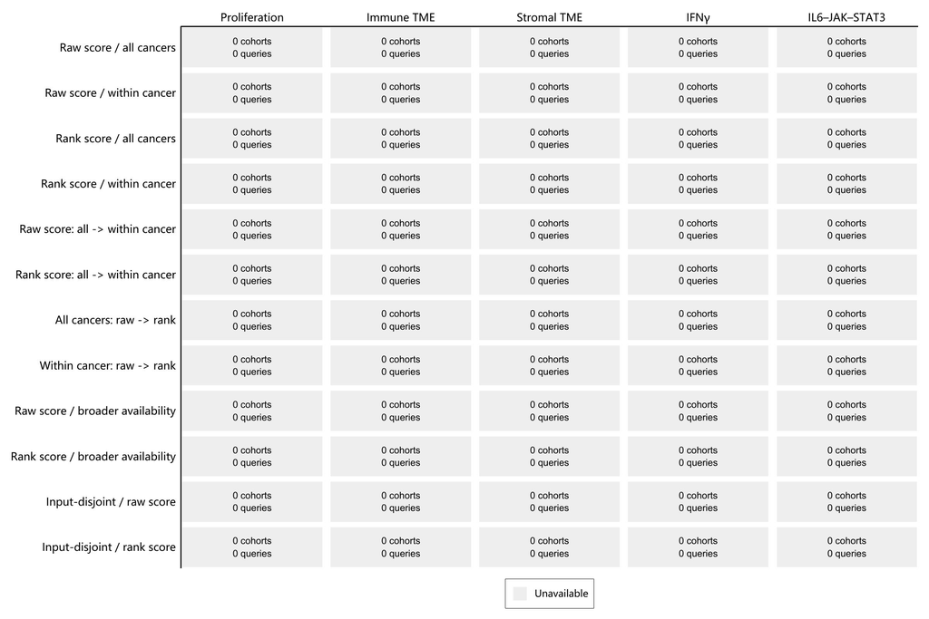

```r
knitr::include_graphics(diag_support_jpg)
```

解读：当前矩阵中 0／60 项有可估计效应；格内的零表示没有患者或队列进入该项严格推断，不能读成 d1−Direct 等于零。结合前面的共同基因门槛，可以看到候选池资格并没有解决完整 signature 的测量不足；这里也没有可用于判断评分切换是否改善的严格效应。低覆盖残余代理在单独的附录中绘图，其支持与结论不能填入本矩阵。

```r
if (nrow(diagnostic_grid) && any(is.finite(diagnostic_grid$estimate))) {
  diagnostic_grid$cell <- paste(diagnostic_grid$score_definition,
    sub("^grid:[^:]+:", "", diagnostic_grid$comparison), sep = " / ")
  diagnostic_grid$cell <- gsub("common_raw", "Common genes", diagnostic_grid$cell)
  diagnostic_grid$cell <- gsub("same_cancer:baseline:none", "within cancer", diagnostic_grid$cell)
  diagnostic_grid$cell <- gsub("all:baseline:none", "all cancers", diagnostic_grid$cell)
  diagnostic_grid$anchor <- factor(diagnostic_grid$anchor, levels = rev(names(anchor_labels)))
  p_grid <- ggplot2::ggplot(diagnostic_grid,
    ggplot2::aes(x = estimate, y = anchor)) +
    ggplot2::geom_vline(xintercept = 0, linetype = 2, colour = "grey60") +
    ggplot2::geom_errorbarh(ggplot2::aes(xmin = ci_low, xmax = ci_high), height = .12) +
    ggplot2::geom_point(size = 2) + ggplot2::facet_wrap(~ cell, ncol = 2) +
    ggplot2::scale_y_discrete(labels = anchor_labels) +
    ggplot2::labs(x = "Cohort-equal utility difference (d1 - Direct)", y = NULL) +
    ggplot2::theme_bw(base_size = 10)
  jpg <- .ae_save_plot(p_grid, "02.02.00. diagnostic-score-pool",
    figure_dir, preview_dir, list(width_in = 10, height_in = 5.5), params$plot_preview_dpi)
  knitr::include_graphics(jpg)
}
```

当前候选池对照结果为：没有满足预设测量与推断门槛的可估计效应；完整原因见资格、覆盖和分支状态表。。同一原尺度分数下收紧癌种候选池，检验邻居癌种组成是否参与负差。全部 43 个队列中可估计的评分结果另列为 broad_score_sensitivity，不能与候选池对照交集混用分母。邻居 Jaccard、同癌种比例、来源分布和绝对分数距离在对应聚合 CSV 中保存。

```r
render_dt(diagnostic_changes, pageLength = 12)
```

|  | anchor | estimate | ci_low | ci_high | p_value | p_method | cohort_count | query_count | n_boot | valid_bootstrap | seed | status | reason | q_value | comparison | score_definition | experiment | family |
| --- | --- | --- | --- | --- | --- | --- | --- | --- | --- | --- | --- | --- | --- | --- | --- | --- | --- | --- |
| 21 | proliferation |  |  |  |  | not_estimable | 0 | 0 | 2000 | 0 | 20276106 | not_estimable | fewer_than_three_cohorts |  | change:raw_pool | common_raw:all:baseline:none -&gt; common_raw:same_cancer:baseline:none | raw_pool | prespecified_grid_changes |
| 22 | immune_tme |  |  |  |  | not_estimable | 0 | 0 | 2000 | 0 | 20276106 | not_estimable | fewer_than_three_cohorts |  | change:raw_pool | common_raw:all:baseline:none -&gt; common_raw:same_cancer:baseline:none | raw_pool | prespecified_grid_changes |
| 23 | stromal_tme |  |  |  |  | not_estimable | 0 | 0 | 2000 | 0 | 20276106 | not_estimable | fewer_than_three_cohorts |  | change:raw_pool | common_raw:all:baseline:none -&gt; common_raw:same_cancer:baseline:none | raw_pool | prespecified_grid_changes |
| 24 | ifn |  |  |  |  | not_estimable | 0 | 0 | 2000 | 0 | 20276106 | not_estimable | fewer_than_three_cohorts |  | change:raw_pool | common_raw:all:baseline:none -&gt; common_raw:same_cancer:baseline:none | raw_pool | prespecified_grid_changes |
| 25 | il6 |  |  |  |  | not_estimable | 0 | 0 | 2000 | 0 | 20276106 | not_estimable | fewer_than_three_cohorts |  | change:raw_pool | common_raw:all:baseline:none -&gt; common_raw:same_cancer:baseline:none | raw_pool | prespecified_grid_changes |
| 26 | proliferation |  |  |  |  | not_estimable | 0 | 0 | 2000 | 0 | 20276106 | not_estimable | fewer_than_three_cohorts |  | change:rank_pool | common_rank:all:baseline:none -&gt; common_rank:same_cancer:baseline:none | rank_pool | prespecified_grid_changes |
| 27 | immune_tme |  |  |  |  | not_estimable | 0 | 0 | 2000 | 0 | 20276106 | not_estimable | fewer_than_three_cohorts |  | change:rank_pool | common_rank:all:baseline:none -&gt; common_rank:same_cancer:baseline:none | rank_pool | prespecified_grid_changes |
| 28 | stromal_tme |  |  |  |  | not_estimable | 0 | 0 | 2000 | 0 | 20276106 | not_estimable | fewer_than_three_cohorts |  | change:rank_pool | common_rank:all:baseline:none -&gt; common_rank:same_cancer:baseline:none | rank_pool | prespecified_grid_changes |
| 29 | ifn |  |  |  |  | not_estimable | 0 | 0 | 2000 | 0 | 20276106 | not_estimable | fewer_than_three_cohorts |  | change:rank_pool | common_rank:all:baseline:none -&gt; common_rank:same_cancer:baseline:none | rank_pool | prespecified_grid_changes |
| 30 | il6 |  |  |  |  | not_estimable | 0 | 0 | 2000 | 0 | 20276106 | not_estimable | fewer_than_three_cohorts |  | change:rank_pool | common_rank:all:baseline:none -&gt; common_rank:same_cancer:baseline:none | rank_pool | prespecified_grid_changes |

[output cut: 10 more lines]

上述变化均先在同一患者上计算差中差，再汇总到 cohort。正的距离变化表示相对基线 d1 距离改善；正的候选池变化表示癌种内限制缩小了 d1 的相对劣势。变化的 95% 区间跨零不能证明两个方案等价，各受控变化也不能相加成根因贡献比例。五项 gene signature 和预定比较按各自检验族做双侧 sign-flip 与 BH 校正，所有预定比较都保留。

### 9.4 全队列读取器的支持与运行状态

本小节保存全队列共同交集目标的读取器资格与分支状态，正文高覆盖目标的有效读取结果见信息可读取性与邻居几何。有可估计目标时，两臂连续读取器仅用 reference 训练，按 cohort 进行五折验证，并在相同 lambda 网格中选择 L2 回归参数；特征、基因原尺度与目标尺度在每个训练折内重新拟合。外部 query 一次性评估，不参与调参。若 reference CV 中 d1 的最佳 MAE 高于 Direct 或不优于均值基准，则对该目标的两臂同时运行冻结的 XGBoost 回归器；非线性分支由 reference CV 触发，query 仅用于外部评估。目标不受测量支持时，保留不可估计状态并跳过拟合。

```r
if (nrow(diagnostic_prediction) && any(is.finite(diagnostic_prediction$estimate))) {
  diagnostic_prediction$anchor <- factor(diagnostic_prediction$anchor, levels = rev(names(anchor_labels)))
  p_readout <- ggplot2::ggplot(diagnostic_prediction,
    ggplot2::aes(x = estimate, y = anchor)) +
    ggplot2::geom_vline(xintercept = 0, linetype = 2, colour = "grey60") +
    ggplot2::geom_errorbarh(ggplot2::aes(xmin = ci_low, xmax = ci_high), height = .12) +
    ggplot2::geom_point(size = 2) + ggplot2::facet_wrap(~ experiment,
      labeller = ggplot2::as_labeller(c(`ridge:mae` = "Ridge", `xgboost:mae` = "XGBoost"))) +
    ggplot2::scale_y_discrete(labels = anchor_labels) +
    ggplot2::scale_x_continuous(breaks = function(x) pretty(x, n = 3)) +
    ggplot2::labs(x = "Standardized MAE difference (d1 - Direct)", y = NULL) +
    ggplot2::theme_bw(base_size = 10) +
    ggplot2::theme(panel.spacing = grid::unit(2, "lines"))
  jpg <- .ae_save_plot(p_readout, "02.02.00. diagnostic-continuous-readout",
    figure_dir, preview_dir, list(width_in = 9, height_in = 4), params$plot_preview_dpi)
  knitr::include_graphics(jpg)
}
```

当前主评分 gene signature 目标的 MAE 差为：当前支持范围内不可估计，详见资格与覆盖表。。此处正值表示 d1 更差，与 utility 差的好坏方向相反。单臂 MAE、reference 整体均值和有支持的癌种均值基准列在 prediction_metrics；癌种基准只与同一子集的模型 MAE 比较。Spearman 零方差仅使相关不可估计，不排除仍有效的 MAE。所有区间条件于固定 bank、读取器与 reference 标尺，不包含重新训练 bank 的波动。

仅为有可估计效应的比较绘图；没有有效效应时不输出空白效果图。读取器–gene signature 组合的未触发运行与支持不足，请以分支状态表区分。

读取器状态图把“无法估计”和“没有运行”分开：每格对应一种评分、一项 signature 和一种读取器。MAE 图仅在有效效应存在时显示；状态图避免把缺少效应图误认为两臂表现相同。

```r
diag_readout_status <- diagnostic$branch_status[diagnostic$branch_status$domain == "readout", ]
diag_readout_parts <- strsplit(diag_readout_status$experiment, ":", fixed = TRUE)
diag_readout_status$score <- vapply(diag_readout_parts, `[`, character(1), 1L)
diag_readout_status$anchor <- factor(vapply(diag_readout_parts, `[`, character(1), 2L),
  levels = rev(names(anchor_labels)))
diag_readout_status$reader <- factor(vapply(diag_readout_parts, `[`, character(1), 3L),
  levels = c("ridge", "xgboost"), labels = c("Ridge", "XGBoost"))
diag_readout_status$score <- factor(diag_readout_status$score,
  levels = c("common_raw", "common_rank"), labels = c("Raw score", "Rank score"))
diag_readout_status$state <- factor(diag_readout_status$status,
  levels = c("estimable", "not_estimable", "not_run"),
  labels = c("Estimable", "Unavailable", "Not run"))
p_diag_readout_status <- ggplot2::ggplot(diag_readout_status,
  ggplot2::aes(x = reader, y = anchor, fill = state)) +
  ggplot2::geom_tile(color = "white", linewidth = 1, width = .96, height = .9) +
  ggplot2::geom_text(ggplot2::aes(label = state), size = 3.4) +
  ggplot2::facet_wrap(~ score, ncol = 2) +
  ggplot2::scale_y_discrete(labels = anchor_labels, expand = c(0, 0)) +
  ggplot2::scale_x_discrete(expand = c(0, 0)) +
  ggplot2::scale_fill_manual(values = c("Estimable" = "#E3EEF4",
    "Unavailable" = "#EEEEEE", "Not run" = "#FFF0D4"), guide = "none") +
  ggplot2::labs(x = NULL, y = NULL) +
  theme_nature_readable(base_size = params$diagnostic_plot_base_size,
    legend_position = "none") +
  ggplot2::theme(axis.ticks = ggplot2::element_blank(),
    panel.border = ggplot2::element_blank())
diag_readout_status_jpg <- hc_save_plot(p_diag_readout_status,
  "02.02.00. diagnostic-readout-status", width = 10, height = 4.3)
```

```
## Converting page 1 to D:/cache/ccs/_ablation-03/logs/report-previews/02.02.00-biology-20261008205659/02.02.00. diagnostic-readout-status.jpg... done!
```

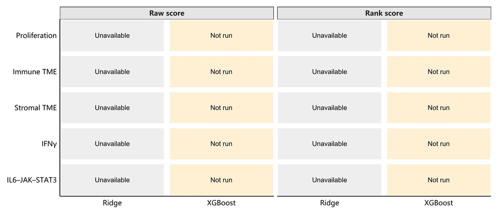

```r
knitr::include_graphics(diag_readout_status_jpg)
```

解读：当前 Ridge 的 10 项组合不可估计，状态原因包含目标或 reference 分折不可用；XGBoost 的 10 项未运行，原因字段同时涵盖 reference CV 未触发或目标不可用。结合本次严格目标的测量不足，这些状态没有提供线性或非线性预测优劣的证据。它们也不能证明信息丢失，或证明使用更复杂读取器仍无法恢复信息；具体原因保留在下表。

```r
render_dt(diagnostic$branch_status, pageLength = 10)
```

|  | domain | experiment | status | reason |
| --- | --- | --- | --- | --- |
| 1 | retrieval | all:Direct:baseline:none | estimable | supported |
| 2 | retrieval | all:d1:baseline:none | estimable | supported |
| 3 | retrieval | same_cancer:Direct:baseline:none | estimable | supported |
| 4 | retrieval | same_cancer:d1:baseline:none | estimable | supported |
| 5 | retrieval | same_cancer:d1:module_unscaled:none | estimable | supported |
| 6 | retrieval | all:d1:module_unscaled:none | estimable | supported |
| 7 | retrieval | same_cancer:d1:tissue_balanced:none | estimable | supported |
| 8 | retrieval | all:d1:tissue_balanced:none | estimable | supported |
| 9 | retrieval | same_cancer:Direct:baseline:assay_type | estimable | supported |
| 10 | retrieval | same_cancer:d1:baseline:assay_type | estimable | supported |

[output cut: 44 more lines]

距离对照只分别改变一个规则：取消逐列标准差除法，或改为 tissue 等权、tissue 内 module 等权、module 内列数平衡。Direct 始终使用基线距离，d1 不组合搜索最佳方案。若连续目标可读出而距离改变改善邻居，则更支持距离权重限制；若读取器仍较差，只能说明当前方法和外部范围内较难恢复，不能证明信息永久丢失。模块相关、饱和率与平方距离贡献用于诊断冗余和域迁移。

### 9.5 检索核验明细

检索核验图将总体平均严格 ID 召回与最差队列的平均召回分开；两个面板各有对应的冻结门槛。点的颜色区分 Direct 与 d1；同距替换允许的召回仍保留在原表，图中使用要求 ID 一致的严格召回。

```r
diag_retrieval <- diagnostic$retrieval_validation
diag_retrieval_keys <- c("arm", "pool", "distance", "restriction")
diag_retrieval$condition <- paste(diag_retrieval$pool, diag_retrieval$distance,
  diag_retrieval$restriction, sep = ":")
diag_retrieval_conditions <- c(
  `all:baseline:none` = "All cancers / baseline",
  `same_cancer:baseline:none` = "Within cancer / baseline",
  `all:module_unscaled:none` = "All cancers / no column SD scaling",
  `same_cancer:module_unscaled:none` = "Within cancer / no column SD scaling",
  `all:tissue_balanced:none` = "All cancers / tissue-balanced",
  `same_cancer:tissue_balanced:none` = "Within cancer / tissue-balanced",
  `same_cancer:baseline:assay_type` = "Within cancer / same assay",
  `same_cancer:baseline:source_system` = "Within cancer / same source")
diag_retrieval_groups <- unique(diag_retrieval[, c("arm", "condition")])
diag_retrieval_summary <- do.call(rbind, lapply(seq_len(nrow(diag_retrieval_groups)), function(i) {
  key <- diag_retrieval_groups[i, ]
  part <- diag_retrieval[diag_retrieval$arm == key$arm &
    diag_retrieval$condition == key$condition, ]
  cohort_means <- tapply(part$strict_recall, part$cohort, mean)
  data.frame(arm = key$arm, condition = key$condition,
    validation_queries = nrow(part), cohort_count = length(cohort_means),
    overall_mean = mean(part$strict_recall), lowest_cohort_mean = min(cohort_means))
}))
diag_retrieval_plot <- rbind(
  transform(diag_retrieval_summary, value = overall_mean, statistic = "Overall validation mean"),
  transform(diag_retrieval_summary, value = lowest_cohort_mean, statistic = "Lowest cohort mean"))
diag_retrieval_plot$condition <- factor(diag_retrieval_plot$condition,
  levels = rev(names(diag_retrieval_conditions)))
diag_retrieval_plot$arm <- factor(diag_retrieval_plot$arm, levels = c("Direct", "d1"))
diag_retrieval_plot$statistic <- factor(diag_retrieval_plot$statistic,
  levels = c("Overall validation mean", "Lowest cohort mean"))
diag_retrieval_thresholds <- data.frame(statistic = levels(diag_retrieval_plot$statistic),
  threshold = c(diagnostic$config$retrieval$min_mean_recall,
    diagnostic$config$retrieval$min_cohort_recall))
diag_retrieval_thresholds$statistic <- factor(diag_retrieval_thresholds$statistic,
  levels = levels(diag_retrieval_plot$statistic))
diag_retrieval_row_labels <- vapply(names(diag_retrieval_conditions), function(condition) {
  part <- diag_retrieval_summary[diag_retrieval_summary$condition == condition, ]
  paste0(diag_retrieval_conditions[[condition]], "\n",
    paste(unique(part$cohort_count), collapse = "–"), " cohorts / ",
    paste(fmt_n(unique(part$validation_queries)), collapse = "–"), " checks per arm")
}, character(1))
diag_retrieval_strip_labels <- stats::setNames(paste0(diag_retrieval_thresholds$statistic,
  "\nThreshold: ", diag_retrieval_thresholds$threshold), diag_retrieval_thresholds$statistic)
p_diag_retrieval <- ggplot2::ggplot(diag_retrieval_plot,
  ggplot2::aes(x = value, y = condition, color = arm, shape = arm)) +
  ggplot2::geom_vline(data = diag_retrieval_thresholds,
    ggplot2::aes(xintercept = threshold), linetype = 2, color = "grey55") +
  ggplot2::geom_point(position = ggplot2::position_dodge(width = .4), size = 2.8) +
  ggplot2::facet_wrap(~ statistic, ncol = 2,
    labeller = ggplot2::as_labeller(diag_retrieval_strip_labels)) +
  ggplot2::scale_y_discrete(labels = diag_retrieval_row_labels) +
  ggplot2::scale_x_continuous(limits = c(.88, 1.01), breaks = c(.9, .95, 1),
    labels = scales::label_number(accuracy = .01)) +
  ggplot2::scale_color_manual(values = c("Direct" = nature_colors[["navy"]],
    "d1" = nature_colors[["green"]])) +
  ggplot2::scale_shape_manual(values = c("Direct" = 16, "d1" = 17)) +
  ggplot2::labs(x = "Strict ID recall against exact neighbors", y = NULL,
    color = NULL, shape = NULL) +
  theme_nature_readable(base_size = params$diagnostic_plot_base_size,
    legend_position = "bottom")
diag_retrieval_jpg <- hc_save_plot(p_diag_retrieval,
  "02.02.00. diagnostic-retrieval-validation", width = params$diagnostic_plot_width, height = 7)
```

```
## Converting page 1 to D:/cache/ccs/_ablation-03/logs/report-previews/02.02.00-biology-20261008205659/02.02.00. diagnostic-retrieval-validation.jpg... done!
```

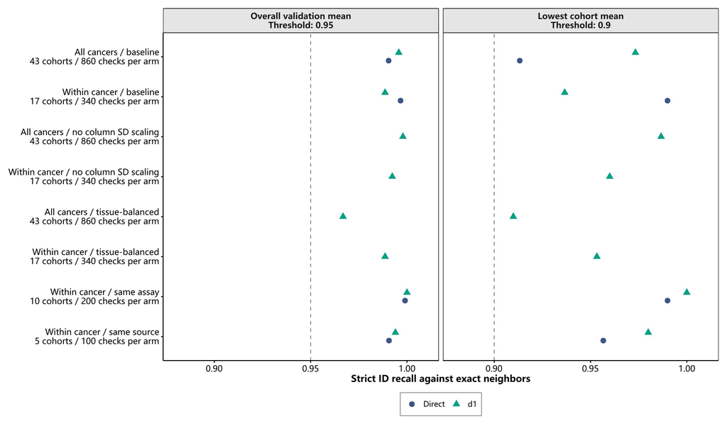

```r
knitr::include_graphics(diag_retrieval_jpg)
```

解读：本次各已核验条件的总体平均严格召回均高于总体门槛，最低队列均值也达到队列门槛；这支持近似检索在已检查范围内与精确名单足够一致。图中总体均值按核验 query 汇总，右图先在队列内平均再取最小值；两者不是生物效应，也没有置信区间。实际门禁还按各癌种及限制条件形成的候选组执行，不能用图中跨组平均值替代；本次 0 条核验记录未通过 Annoy 门禁。同平台没有可核验的合格 query，因此不画召回为零的点。取消列标准差缩放或组织等权仅在 d1 中改变距离，相应行只有 d1 点。

```r
validation_summary <- if (nrow(diagnostic$retrieval_validation)) {
  stats::aggregate(cbind(strict_recall, recall) ~ arm + pool + distance + restriction +
    method, diagnostic$retrieval_validation, mean)
} else data.frame()
render_dt(validation_summary, pageLength = 12)
```

|  | arm | pool | distance | restriction | method | strict_recall | recall |
| --- | --- | --- | --- | --- | --- | --- | --- |
| 1 | d1 | same_cancer | baseline | assay_type | annoy_validated | 1 | 1 |
| 2 | Direct | same_cancer | baseline | assay_type | annoy_validated | 0.999 | 0.999 |
| 3 | d1 | all | baseline | none | annoy_validated | 0.9957364341085271 | 0.9957364341085271 |
| 4 | Direct | all | baseline | none | annoy_validated | 0.9904651162790697 | 0.9904651162790697 |
| 5 | d1 | same_cancer | baseline | none | annoy_validated | 0.9886274509803922 | 0.9886274509803922 |
| 6 | Direct | same_cancer | baseline | none | annoy_validated | 0.9966666666666667 | 0.9966666666666667 |
| 7 | d1 | all | module_unscaled | none | annoy_validated | 0.997906976744186 | 0.997906976744186 |
| 8 | d1 | same_cancer | module_unscaled | none | annoy_validated | 0.9923529411764705 | 0.9923529411764705 |
| 9 | d1 | all | tissue_balanced | none | annoy_validated | 0.9668217054263566 | 0.9668217054263566 |
| 10 | d1 | same_cancer | tissue_balanced | none | annoy_validated | 0.9886274509803922 | 0.9886274509803922 |

[output cut: 2 more lines]

每个合格 cohort 最多二十个 query 先用精确欧氏邻居核对 Annoy；严格 ID 平均召回至少 0.95、各 cohort 至少 0.90，依冻结搜索预算升级后仍不合格则正式结果使用精确检索。检测到边界等距的正式 query 使用精确距离与 ID 顺序决定名单，同时保存严格 ID 与允许同距替换的描述性召回、边界并列数和各评分的 utility 误差。检索结果仅在完成该门禁后进入正式效应估计。

检测类型、来源与已知平台分别在癌种内重新核对候选池及共同患者；支持不足的层只保留资格与描述，有有效测量目标时才估计效应。队列和来源的逐一删除敏感性分析在有可估计效应的比较中执行，结果按实际有效队列与来源数报告。source 层没有至少三个有效组时不发布泛化区间，cohort 共享来源也不能自动当作完全独立抽样。完整结果及不可估计原因保存在 `reports/tables/02.02.00. diagnostic-*.csv`，患者身份、表达原值和读取器训练产物仅留在正式受控缓存。

本附录保留全队列测量与检索资格，不将支持不足当作无差异结论。正文的高覆盖效用、读取与敏感性比较提供当前有效的机制线索；它们仍需结合差值、区间及实际有效人数判断，不能由检索召回推断临床效用。

## 10 附录：固定残余基因的低覆盖探索

本附录保留全队列交集内残余基因的评分、候选池和距离探索，用于提出后续验证问题。正文已有高覆盖目标的有效比较；此处的残余代理，尤其单基因基质代理，不具有同等的完整 signature 测量资格，其结果不作为正文主结论的替代。

这些补充计算回答“现有残余基因代理对评分、候选池和距离是否敏感”。原尺度使用有限 reference 值拟合每个固定基因的标尺，至少两个有效值且标准差为正；任一残余基因不可定标则整个代理不可定标。样本必须具备全部残余 gene signature 值；秩评分还要求全部固定背景有限，不按样本缩减背景。最后按有效 reference 代理分数再次定标。query 不参与标尺，没有填补缺失或按样本更换基因。有效人数与标尺分别保存在 low_coverage_availability、low_coverage_scales、low_coverage_gene_scales。

可评分人数图显示冻结残余代理在 reference 与 query 中各损失了多少可评分样本，按原尺度和秩评分分别展示。条长是缺失比例，标注为“不可评分数／总数”；这一层尚未施加完整邻居与跨队列推断门槛。

```r
diag_residual_availability <- stats::aggregate(cbind(sample_count, valid_count, missing_count) ~
  role + score_definition + anchor, exploratory$availability, sum)
diag_residual_availability$anchor <- factor(diag_residual_availability$anchor,
  levels = rev(names(anchor_labels)))
diag_residual_availability$role <- factor(diag_residual_availability$role,
  levels = c("reference", "query"), labels = c("Reference", "Query"))
diag_residual_availability$score <- factor(diag_residual_availability$score_definition,
  levels = c("common_raw", "common_rank"), labels = c("Raw residual proxy", "Rank residual proxy"))
diag_residual_availability$missing_fraction <- with(diag_residual_availability,
  missing_count / sample_count)
diag_residual_availability$label <- paste0(fmt_n(diag_residual_availability$missing_count),
  " / ", fmt_n(diag_residual_availability$sample_count))
diag_availability_xlim <- max(diag_residual_availability$missing_fraction) * 1.8
diag_availability_xlim <- max(.01, diag_availability_xlim)
p_diag_residual_availability <- ggplot2::ggplot(diag_residual_availability,
  ggplot2::aes(x = missing_fraction, y = anchor)) +
  ggplot2::geom_col(width = .5, fill = nature_colors[["navy"]]) +
  ggplot2::geom_text(ggplot2::aes(label = label), hjust = -.12, size = 3.2) +
  ggplot2::facet_grid(role ~ score) +
  ggplot2::scale_y_discrete(labels = anchor_labels) +
  ggplot2::scale_x_continuous(limits = c(0, diag_availability_xlim),
    breaks = scales::breaks_pretty(n = 3), labels = scales::label_percent(accuracy = .1)) +
  ggplot2::labs(x = "Unscorable fraction of samples (labels: missing / total)", y = NULL) +
  theme_nature_readable(base_size = params$diagnostic_plot_base_size,
    legend_position = "none")
diag_residual_availability_jpg <- hc_save_plot(p_diag_residual_availability,
  "02.02.00. diagnostic-residual-availability", width = params$diagnostic_plot_width, height = 5.8)
```

```
## Converting page 1 to D:/cache/ccs/_ablation-03/logs/report-previews/02.02.00-biology-20261008205659/02.02.00. diagnostic-residual-availability.jpg... done!
```

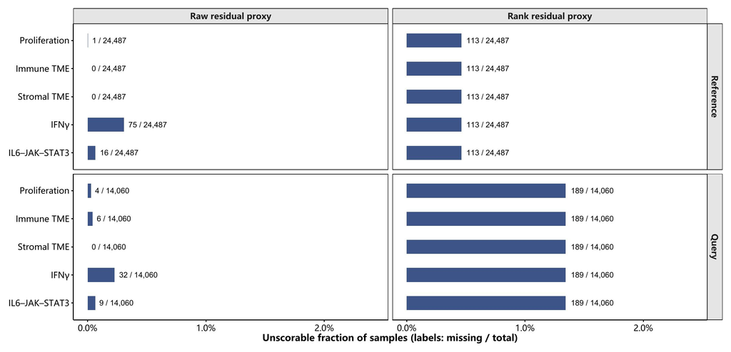

```r
knitr::include_graphics(diag_residual_availability_jpg)
```

解读：原尺度残余代理的缺失较少，但不同 signature 仍有差异；秩代理各项的缺失数相同，因为它们都要求同一冻结背景完整。条短只表示当前残余代理能在较多样本上计算，并不表示完整 signature 覆盖充分。该图按样本汇总，属于人数描述；后面的效应区间仍按 cohort 计算，且使用各对比共同患者。基质在这里可评分也不能恢复其完整 signature 身份，单基因代理仍仅作描述。

```r
render_dt(exploratory$availability, pageLength = 8)
```

|  | cohort | role | score_definition | anchor | sample_count | valid_count | missing_count |
| --- | --- | --- | --- | --- | --- | --- | --- |
| 1 | ACC/GSE143383 | reference | common_raw | proliferation | 63 | 63 | 0 |
| 2 | ACC/GSE19750 | reference | common_raw | proliferation | 48 | 48 | 0 |
| 3 | ACC/GSE33371 | reference | common_raw | proliferation | 55 | 55 | 0 |
| 4 | ACC/GSE49278 | reference | common_raw | proliferation | 44 | 44 | 0 |
| 5 | ACC/GSE75415 | reference | common_raw | proliferation | 23 | 23 | 0 |
| 6 | ACC/GSE76019 | reference | common_raw | proliferation | 34 | 34 | 0 |
| 7 | ACC/GSE76021 | reference | common_raw | proliferation | 29 | 29 | 0 |
| 8 | ACC/GSE90713 | reference | common_raw | proliferation | 58 | 58 | 0 |
| 9 | ACC/TCGATARGET-ACC | query | common_raw | proliferation | 77 | 77 | 0 |
| 10 | BLCA/Cornell-NatCom-2019 | reference | common_raw | proliferation | 32 | 32 | 0 |

[output cut: 90 more lines]

```r
render_dt(exploratory$scales, pageLength = 8)
```

|  | score_definition | anchor | reference_valid_count | reference_mean | reference_sd | status | reason |
| --- | --- | --- | --- | --- | --- | --- | --- |
| 1 | common_raw | proliferation | 24486 | 4.155085169477184e-05 | 0.9679805750357945 | residual_proxy | low_coverage_exploratory_only |
| 2 | common_raw | immune_tme | 24487 | -5.567607287343833e-17 | 0.9532833659070123 | residual_proxy | low_coverage_exploratory_only |
| 3 | common_raw | stromal_tme | 24487 | -2.034600327931306e-17 | 0.9999999999999999 | residual_proxy | low_coverage_exploratory_only |
| 4 | common_raw | ifn | 24412 | 0.003938164588911729 | 0.9321187106840514 | residual_proxy | low_coverage_exploratory_only |
| 5 | common_raw | il6 | 24471 | 0.0008047267858557448 | 0.9346230447298639 | residual_proxy | low_coverage_exploratory_only |
| 6 | common_rank | proliferation | 24374 | 0.406460906769218 | 0.1790691747685901 | residual_proxy | low_coverage_exploratory_only |
| 7 | common_rank | immune_tme | 24374 | 0.4368476201610449 | 0.1987060726403886 | residual_proxy | low_coverage_exploratory_only |
| 8 | common_rank | stromal_tme | 24374 | 0.5592508083835162 | 0.2502704260892312 | residual_proxy | low_coverage_exploratory_only |
| 9 | common_rank | ifn | 24374 | 0.5182944455370789 | 0.08388723916727664 | residual_proxy | low_coverage_exploratory_only |
| 10 | common_rank | il6 | 24374 | 0.5037286795977709 | 0.06627356559774415 | residual_proxy | low_coverage_exploratory_only |

解读：背景完整性共保留 38245／38547 个契约样本（含 reference 与 query）。原尺度与秩代理的有效人数可能不同，完整两臂 top-15 又会进一步缩小配对人数；因此下图四格在每项代理内使用相同患者，不能用人数不同的广覆盖结果代替切换对照。

```
## Converting page 1 to D:/cache/ccs/_ablation-03/logs/report-previews/02.02.00-biology-20261008205659/02.02.00. diagnostic-low-coverage-score-pool.jpg... done!
```

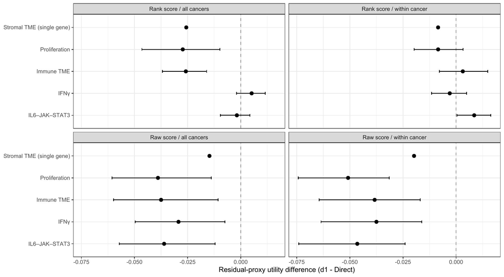

```r
low_grid <- exploratory$inference[grepl("^grid:", exploratory$inference$comparison), ]
if (any(is.finite(low_grid$estimate))) {
  low_grid$cell <- sub("^grid:", "", low_grid$comparison)
  low_grid$cell <- gsub(":baseline:none", "", low_grid$cell)
  low_grid$cell <- gsub("common_rank", "Rank score", low_grid$cell)
  low_grid$cell <- gsub("common_raw", "Raw score", low_grid$cell)
  low_grid$cell <- gsub("same_cancer", "within cancer", low_grid$cell)
  low_grid$cell <- sub(":all$", ":all cancers", low_grid$cell)
  low_grid$cell <- gsub(":", " / ", low_grid$cell)
  low_labels <- anchor_labels
  single_anchors <- unique(low_grid$anchor[low_grid$residual_gene_count == 1L])
  low_labels[as.character(single_anchors)] <- paste0(low_labels[as.character(single_anchors)],
    plot_label(" (single gene)", "（单基因）"))
  low_grid$anchor <- factor(low_grid$anchor, levels = rev(names(anchor_labels)))
  p_low <- ggplot2::ggplot(low_grid, ggplot2::aes(x = estimate, y = anchor)) +
    ggplot2::geom_vline(xintercept = 0, linetype = 2, colour = "grey60") +
    ggplot2::geom_errorbarh(data = low_grid[is.finite(low_grid$ci_low), ],
      ggplot2::aes(xmin = ci_low, xmax = ci_high), height = .12) +
    ggplot2::geom_point(size = 2, na.rm = TRUE) + ggplot2::facet_wrap(~ cell, ncol = 2) +
    ggplot2::scale_y_discrete(labels = low_labels) +
    ggplot2::labs(x = "Residual-proxy utility difference (d1 - Direct)", y = NULL) +
    ggplot2::theme_bw(base_size = 10)
  jpg <- .ae_save_plot(p_low, "02.02.00. diagnostic-low-coverage-score-pool",
    figure_dir, preview_dir, list(width_in = 10, height_in = 5.5), params$plot_preview_dpi)
  knitr::include_graphics(jpg)
}
```

解读：同癌种秩代理的 d1−Direct 为 proliferation：-0.0085，95% 条件区间 [-0.0198, 0.0033]（16 cohort，5578 query）；immune_tme：0.0032，95% 条件区间 [-0.0079, 0.0149]（16 cohort，5578 query）；stromal_tme：-0.0085，无可发布区间（16 cohort，5578 query）；ifn：-0.0030，95% 条件区间 [-0.0115, 0.0049]（16 cohort，5578 query）；il6：0.0085，95% 条件区间 [0.0004, 0.0164]（16 cohort，5578 query）。正值仅表示当前残余分数更接近。多基因残余代理的区间反映固定标尺下 cohort 均值波动；基质当前保留 1 个基因，仅剩单基因时图中只有点、无区间，不能代表完整基质 gene signature。

```r
change_labels <- c(
  `change:raw_pool` = plot_label("Raw score: all -> within cancer", "原尺度：全癌种 → 同癌种"),
  `change:rank_pool` = plot_label("Rank score: all -> within cancer", "秩评分：全癌种 → 同癌种"),
  `change:all_score` = plot_label("All cancers: raw -> rank score", "全癌种：原尺度 → 秩评分"),
  `change:same_score` = plot_label("Within cancer: raw -> rank score", "同癌种：原尺度 → 秩评分"))
jpg <- diagnostic_change_plot(exploratory$inference, change_labels,
  "02.02.00. diagnostic-low-coverage-score-pool-changes")
```

```
## Converting page 1 to D:/cache/ccs/_ablation-03/logs/report-previews/02.02.00-biology-20261008205659/02.02.00. diagnostic-low-coverage-score-pool-changes.jpg... done!
```

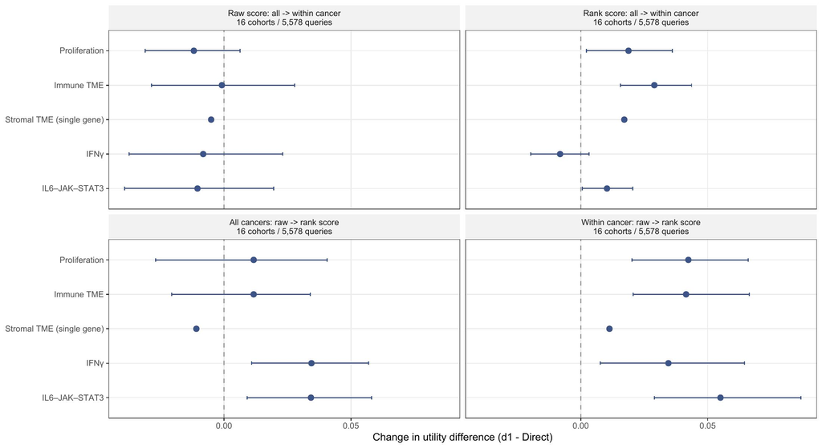

```r
if (!is.null(jpg)) knitr::include_graphics(jpg)
```

```r
distance_change_labels <- c(
  `distance_change:all:module_unscaled` = plot_label("All cancers: remove column SD scaling", "全癌种：取消逐列标准差缩放"),
  `distance_change:all:tissue_balanced` = plot_label("All cancers: tissue-balanced distance", "全癌种：组织等权距离"),
  `distance_change:same_cancer:module_unscaled` = plot_label("Within cancer: remove column SD scaling", "同癌种：取消逐列标准差缩放"),
  `distance_change:same_cancer:tissue_balanced` = plot_label("Within cancer: tissue-balanced distance", "同癌种：组织等权距离"))
jpg <- diagnostic_change_plot(exploratory$inference, distance_change_labels,
  "02.02.00. diagnostic-low-coverage-distance-changes")
```

```
## Converting page 1 to D:/cache/ccs/_ablation-03/logs/report-previews/02.02.00-biology-20261008205659/02.02.00. diagnostic-low-coverage-distance-changes.jpg... done!
```

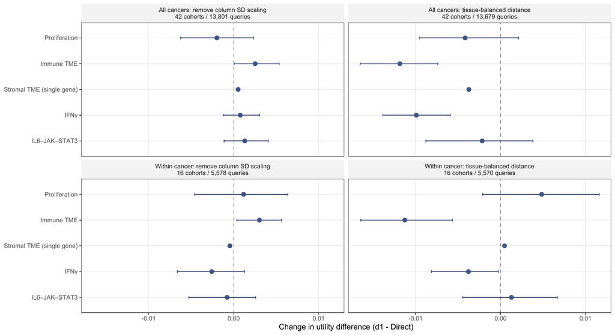

```r
if (!is.null(jpg)) knitr::include_graphics(jpg)
```

解读：每项距离改变单独与对应基线在共同患者上配对，Direct 的距离固定，评分为冻结的秩主评分；正值表示该规则下 d1 的相对差值提高。全癌种与同癌种面板的人数可不同，标题分别列出，不将不同人群间差值解释为规则作用。两个距离规则和五项代理分别报告，规则作用通过各自的配对比较判断，不能将变化相加为根因比例。

```r
render_dt(exploratory$inference, n = nrow(exploratory$inference), pageLength = 12)
```

|  | anchor | estimate | ci_low | ci_high | p_value | p_method | cohort_count | query_count | n_boot | valid_bootstrap | seed | status | reason | q_value | comparison | family | residual_gene_count | measurement | scope | interval_method |
| --- | --- | --- | --- | --- | --- | --- | --- | --- | --- | --- | --- | --- | --- | --- | --- | --- | --- | --- | --- | --- |
| 1 | proliferation | -0.03894998217155578 | -0.06058247594446498 | -0.01379707104439706 |  | not_tested | 16 | 5578 | 2000 | 2000 | 24230350 | exploratory | low_coverage_not_full_anchor_evidence |  | grid:common_raw:all:baseline:none | matched_score_pool_grid | 5 | residual_multigene_proxy | conditional_on_fixed_residual_genes_bank_and_reference_scale | cohort_percentile_bootstrap_95_percent |
| 2 | immune_tme | -0.03749087033621865 | -0.05991009136681755 | -0.01061388211262624 |  | not_tested | 16 | 5578 | 2000 | 2000 | 24230350 | exploratory | low_coverage_not_full_anchor_evidence |  | grid:common_raw:all:baseline:none | matched_score_pool_grid | 4 | residual_multigene_proxy | conditional_on_fixed_residual_genes_bank_and_reference_scale | cohort_percentile_bootstrap_95_percent |
| 3 | stromal_tme | -0.01471331941330067 |  |  |  | not_tested | 16 | 5578 | 2000 | 2000 | 24230350 | descriptive_only | low_coverage_not_full_anchor_evidence |  | grid:common_raw:all:baseline:none | matched_score_pool_grid | 1 | single_gene_description | conditional_on_fixed_residual_genes_bank_and_reference_scale | not_applicable_single_gene |
| 4 | ifn | -0.02929040817023659 | -0.04970760647691233 | -0.007408471309006561 |  | not_tested | 16 | 5578 | 2000 | 2000 | 24230350 | exploratory | low_coverage_not_full_anchor_evidence |  | grid:common_raw:all:baseline:none | matched_score_pool_grid | 39 | residual_multigene_proxy | conditional_on_fixed_residual_genes_bank_and_reference_scale | cohort_percentile_bootstrap_95_percent |
| 5 | il6 | -0.0360544382636388 | -0.05713803393443311 | -0.01202878908910701 |  | not_tested | 16 | 5578 | 2000 | 2000 | 24230350 | exploratory | low_coverage_not_full_anchor_evidence |  | grid:common_raw:all:baseline:none | matched_score_pool_grid | 19 | residual_multigene_proxy | conditional_on_fixed_residual_genes_bank_and_reference_scale | cohort_percentile_bootstrap_95_percent |
| 6 | proliferation | -0.05084678163014203 | -0.07430880831018645 | -0.03153706336858272 |  | not_tested | 16 | 5578 | 2000 | 2000 | 24230350 | exploratory | low_coverage_not_full_anchor_evidence |  | grid:common_raw:same_cancer:baseline:none | matched_score_pool_grid | 5 | residual_multigene_proxy | conditional_on_fixed_residual_genes_bank_and_reference_scale | cohort_percentile_bootstrap_95_percent |
| 7 | immune_tme | -0.03834197332279501 | -0.06443951531083549 | -0.01686031977600984 |  | not_tested | 16 | 5578 | 2000 | 2000 | 24230350 | exploratory | low_coverage_not_full_anchor_evidence |  | grid:common_raw:same_cancer:baseline:none | matched_score_pool_grid | 4 | residual_multigene_proxy | conditional_on_fixed_residual_genes_bank_and_reference_scale | cohort_percentile_bootstrap_95_percent |
| 8 | stromal_tme | -0.01978873449499841 |  |  |  | not_tested | 16 | 5578 | 2000 | 2000 | 24230350 | descriptive_only | low_coverage_not_full_anchor_evidence |  | grid:common_raw:same_cancer:baseline:none | matched_score_pool_grid | 1 | single_gene_description | conditional_on_fixed_residual_genes_bank_and_reference_scale | not_applicable_single_gene |
| 9 | ifn | -0.03750561381164123 | -0.06357280200828509 | -0.01622669990341567 |  | not_tested | 16 | 5578 | 2000 | 2000 | 24230350 | exploratory | low_coverage_not_full_anchor_evidence |  | grid:common_raw:same_cancer:baseline:none | matched_score_pool_grid | 39 | residual_multigene_proxy | conditional_on_fixed_residual_genes_bank_and_reference_scale | cohort_percentile_bootstrap_95_percent |
| 10 | il6 | -0.04651023542458154 | -0.07407331182430946 | -0.02397012609197145 |  | not_tested | 16 | 5578 | 2000 | 2000 | 24230350 | exploratory | low_coverage_not_full_anchor_evidence |  | grid:common_raw:same_cancer:baseline:none | matched_score_pool_grid | 19 | residual_multigene_proxy | conditional_on_fixed_residual_genes_bank_and_reference_scale | cohort_percentile_bootstrap_95_percent |

[output cut: 80 more lines]

同患者从全癌种切换到同癌种的秩代理差中差为 proliferation：0.0188，95% 条件区间 [0.0022, 0.0361]（16 cohort，5578 query）；immune_tme：0.0290，95% 条件区间 [0.0157, 0.0437]（16 cohort，5578 query）；stromal_tme：0.0171，无可发布区间（16 cohort，5578 query）；ifn：-0.0081，95% 条件区间 [-0.0197, 0.0032]（16 cohort，5578 query）；il6：0.0103，95% 条件区间 [0.0006, 0.0204]（16 cohort，5578 query）；全癌种原尺度切换到秩评分为 proliferation：0.0117，95% 条件区间 [-0.0270, 0.0406]（16 cohort，5578 query）；immune_tme：0.0117，95% 条件区间 [-0.0206, 0.0340]（16 cohort，5578 query）；stromal_tme：-0.0109，无可发布区间（16 cohort，5578 query）；ifn：0.0344，95% 条件区间 [0.0108, 0.0569]（16 cohort，5578 query）；il6：0.0342，95% 条件区间 [0.0091, 0.0582]（16 cohort，5578 query）。正变化表示 d1 的相对差值提高。距离变化各自使用与对应基线共同的患者，完整水平与差中差保留在表中；不同对比的人群须核对人数，不把改善相加成根因比例。

当前候选池切换中，95% 条件区间完全为正的多基因代理为 proliferation、immune_tme、il6；评分切换对应为 ifn、il6。这些观察提示候选池组成与评分定义影响当前残余分数的局部接近度；不能将其直接解释成原完整 gene signature 负差的成因或技术偏差已消除。同癌种下，免疫残余代理取消逐列标准差缩放的变化为 immune_tme：0.0030，95% 条件区间 [0.0004, 0.0057]（16 cohort，5578 query），tissue 等权变化为 immune_tme：-0.0113，95% 条件区间 [-0.0165, -0.0057]（16 cohort，5570 query），两个距离规则分别报告。

本补充不发布 p/q，不训练低覆盖读取器。多基因 95% 条件区间只在至少二十个有效 query/cohort、三个 cohort 和足够有效 bootstrap 时给出；基质单基因一律仅描述。区间不包含残余基因选择、跨平台偏差或 bank 重训，也不能证明秩评分消除了技术影响。低覆盖结果可指示后续验证方向。完整 signature 的高覆盖比较见正文；全队列共同交集资格见测量审计附录。本附录的变化只描述固定残余代理，不能确证广队列负差的根因。